# Data Exploration

Samantha Andrews

# Overview

Exploration of all the data collected on the presence points + randomly generated background points

A note to anyone who might happen to stumble across this… I am a beginner in R and have had no exposure to similar languages. I don’t know what I’m doing. The code herein is unlikely to be elegant and there are probably more efficient ways of running the code.

# Package dependencies

You can load them using the following code which uses a function called [ipak](https://gist.github.com/stevenworthington/3178163). Note this function checks to see if the packages are installed first. The “include=FALSE” supresses the package installation text appearing in the document…

# read in all data

and subset into background and presences

```r
presab <- read.csv("../output/bio/presab_nafo_yr.csv", header = TRUE)
presence <- subset(presab, occurrence == "1")
background <- subset(presab, occurrence == "0")
```

## Update: Who sampled in which year and which month:

year

```r
inst_by_yr <- with(presence, table(year, institutioncode))
write.csv(inst_by_yr, file = "../output/bio/institutioncode_by_yr.csv")
inst_by_yr
```

month

```r
inst_by_mt <- with(presence, table(month, institutioncode))
write.csv(inst_by_mt, file = "../output/bio/institutioncode_by_mth.csv")
inst_by_mt
```

and just a year-month table

```r
year_by_mt <- with(presence, table(year, month))
write.csv(year_by_mt, file = "../output/bio/year_by_mth.csv")
year_by_mt
```

## environmental correlates

1. Get the max, min, an mean values and add into a dataframe

Temperature

```r
temp_depth_max <- max(presence$temp_depth, na.rm = TRUE)
temp_depth_min <- min(presence$temp_depth, na.rm = TRUE)
temp_depth_mean <- mean(presence$temp_depth, na.rm = TRUE)
temp_surface_max <- max(presence$temp_surface, na.rm = TRUE)
temp_surface_min <- min(presence$temp_surface, na.rm = TRUE)
temp_surface_mean <- mean(presence$temp_surface, na.rm = TRUE)
```

Salinity

```r
sal_depth_max <- max(presence$salinity_depth, na.rm = TRUE)
sal_depth_min <- min(presence$salinity_depth, na.rm = TRUE)
sal_depth_mean <- mean(presence$salinity_depth, na.rm = TRUE)
sal_surface_max <- max(presence$salinity_surface, na.rm = TRUE)
sal_surface_min <- min(presence$salinity_surface, na.rm = TRUE)
sal_surface_mean <- mean(presence$salinity_surface, na.rm = TRUE)
```

Chl

```r
chl_depth_max <- max(presence$chl_depth, na.rm = TRUE)
chl_depth_min <- min(presence$chl_depth, na.rm = TRUE)
chl_depth_mean <- mean(presence$chl_depth, na.rm = TRUE)
chl_surface_max <- max(presence$chl_surface, na.rm = TRUE)
chl_surface_min <- min(presence$chl_surface, na.rm = TRUE)
chl_surface_mean <- mean(presence$chl_surface, na.rm = TRUE)
```

O2

```r
o2_depth_max <- max(presence$o2_depth, na.rm = TRUE)
o2_depth_min <- min(presence$o2_depth, na.rm = TRUE)
o2_depth_mean <- mean(presence$o2_depth, na.rm = TRUE)
o2_surface_max <- max(presence$o2_surface, na.rm = TRUE)
o2_surface_min <- min(presence$o2_surface, na.rm = TRUE)
o2_surface_mean <- mean(presence$o2_surface, na.rm = TRUE)
```

MLP

```r
mlp_surface_max <- max(presence$mlp_surface, na.rm = TRUE)
mlp_surface_min <- min(presence$mlp_surface, na.rm = TRUE)
mlp_surface_mean <- mean(presence$mlp_surface, na.rm = TRUE)
```

SSH

```r
ssh_surface_max <- max(presence$ssh_surface, na.rm = TRUE)
ssh_surface_min <- min(presence$ssh_surface, na.rm = TRUE)
ssh_surface_mean <- mean(presence$ssh_surface, na.rm = TRUE)
```

create matrix

```r
td <- c(temp_depth_max, temp_depth_min, temp_depth_mean)
ts <- c(temp_surface_max, temp_surface_min, temp_surface_mean)
sd <- c(sal_depth_max, sal_depth_min, sal_depth_mean)
ss <- c(sal_surface_max, sal_surface_min, sal_surface_mean)
cd <- c(sal_depth_max, sal_depth_min, sal_depth_mean)
cs <- c(sal_surface_max, sal_surface_min, sal_surface_mean)
od <- c(o2_depth_max, o2_depth_min, o2_depth_mean)
os <- c(o2_surface_max, o2_surface_min, o2_surface_mean)
mlp <- c(mlp_surface_max, mlp_surface_min, mlp_surface_mean)
ssh <- c(ssh_surface_max, ssh_surface_min, ssh_surface_mean)
env_stats <- rbind(td, ts, sd, ss, cd, cs, od, os, mlp, ssh)
row.names(env_stats) <- c("Temp Depth", "Temp Surface", "Salinity Depth", "Salinity Surface", "Chl Depth", "Chl Surface", "Oxygen Depth", "Oxygen Surface", "MLP", "SSH")
colnames(env_stats) <- c("Max", "Min", "Mean")
write.csv(env_stats, "../output/env/env_correlates_basic_stats.csv", row.names = TRUE)
env_stats
```

Hmm some potentially suspicious values here in - Oxygen Depth min - mlp Max and maybe also - Salinity Depth min - Salinity Surface min - CHL depth min - CHL depth max

lets just see where these values appear and check the netcdf layers. Note I will check these values in cygwin using the cdo operator infov on the netcdfs (to ensure there was no issue with processing in R).

get the year and month these values appeared in

```r
o2d_check_yr <- subset(presence$year, presence$o2_depth == o2_depth_min)
o2d_check_mth <- subset(presence$month, presence$o2_depth == o2_depth_min)
```

O2 depth min is in 2005_08

And value seems correct

```r
mlp_check_yr <- subset(presence$year, presence$mlp_surface == mlp_surface_max)
mlp_check_mth <- subset(presence$month, presence$mlp_surface == mlp_surface_max)
```

mlp max in in 2007_12

And yes the value seems correct

```r
sald_check_yr <- subset(presence$year, presence$salinity_depth == sal_depth_max)
sald_check_mth <- subset(presence$month, presence$salinity_depth == sal_depth_max)
```

year month 2001_05

also seems correct

```r
sals_check_yr <- subset(presence$year, presence$salinity_surface == sal_surface_min)
sals_check_mth <- subset(presence$month, presence$salinity_surface == sal_surface_min)
```

year month 21998_06

ok again…

Leave the rest

## simple plots of env. correlates

temperature

```r
par(mfrow=c(1,2))
plot(presence$temp_depth, main = "Temp at Depth (Various)", ylab = "Kelvin")
plot(presence$temp_surface, main = "Temp at Surface", ylab = "Kelvin")
dev.copy(png, "../output/env/simple_plots/temperature_simpleplot.png") # to automatically save the plot to a png AND show it inline
dev.off() # stops automatic saving of the plot to a png
```

Hmm not necessarily very helpful. But anyway, lets carry on

salinity

```r
par(mfrow=c(1,2))
plot(presence$salinity_depth, main = "Salinity at Depth (Various)", ylab = "Practical Salinity Units")
plot(presence$salinity_surface, main = "Salinity at Surface", ylab = "Practical Salinity Units")
dev.copy(png,"../output/env/simple_plots/salinity_simpleplot.png") # to automatically save the plot to a png AND show it inline
dev.off() # stops automatic saving of the plot to a png
```

Chlorophyll

```r
par(mfrow=c(1,2))
plot(presence$chl_depth, main = "Chl at Depth (Various)", ylab = "Chl (mmol.m-3)")
plot(presence$chl_surface, main = "Chl at Surface", ylab = "Chl (mmol.m-3)")
dev.copy(png,"../output/env/simple_plots/chl_simpleplot.png") # to automatically save the plot to a png AND show it inline
dev.off() # stops automatic saving of the plot to a png
```

O2

```r
par(mfrow=c(1,2))
plot(presence$o2_depth, main = "Dissolved Oxygen at Depth (Various)", ylab = "Chl (mmol.m-3)")
plot(presence$o2_surface, main = "Dissolved Oxygen at Surface", ylab = "O2 (mmol.m-3)")
dev.copy(png,"../output/env/simple_plots/o2_simpleplot.png") # to automatically save the plot to a png AND show it inline
dev.off() # stops automatic saving of the plot to a png
```

mlp

```r
plot(presence$mlp_surface, main = "Mixed Layer Thickness", ylab = "Depth (m)")
dev.copy(png,"../output/env/simple_plots/mlp_simpleplot.png") # to automatically save the plot to a png AND show it inline
dev.off() # stops automatic saving of the plot to a png
```

SSH

```r
plot(presence$ssh_surface, main = "Sea Surface Height", ylab = "Height (m)")
dev.copy(png,"../output/env/simple_plots/ssh_simpleplot.png") # to automatically save the plot to a png AND show it inline
dev.off() # stops automatic saving of the plot to a png
```

XXX SAM - YOU WANT TO THINK ABOUT DOING THIS BY DEPTH RATHER THAN ALL DEPTHS)

```r
unique_depths <- unique(presence$depthlayerno)
unique_depthdordered <- sort(unique_depths) #just puts the list in oder with no NA
length(unique_depthdordered)
```

ouch - 39 layers… a job for a boxplot probably

# frequency plots of env. corr

temperature

```r
hist(presence$temp_surface, main = "Temp at Surface", xlab = "Kelvin")
dev.copy(png, "../output/env/simple_plots/temperature_surface_histogram.png") # to automatically save the plot to a png AND show it inline
dev.off() # stops automatic saving of the plot to a png
```

```r
hist(presence$temp_dept, main = "Temp at Depth", xlab = "Kelvin")
dev.copy(png, "../output/env/simple_plots/temperature_depth_histogram.png") # to automatically save the plot to a png AND show it inline
dev.off() # stops automatic saving of the plot to a png
```

chl

```r
hist(presence$chl_surface, main = "Chlorophyll at Surface", xlab = "Chlorophyll Concentrations (mmol.m-3)")
dev.copy(png, "../output/env/simple_plots/chl_surface_histogram.png") # to automatically save the plot to a png AND show it inline
dev.off() # stops automatic saving of the plot to a png
```

```r
hist(presence$chl_depth, main = "Chlorophyll at Observation Depth", xlab = "Chlorophyll Concentrations (mmol.m-3)")
dev.copy(png, "../output/env/simple_plots/chl_depth_histogram.png") # to automatically save the plot to a png AND show it inline
dev.off() # stops automatic saving of the plot to a png
```

salinity

```r
hist(presence$salinity_surface, main = "Salinity at Surface", xlab = "Salinity Practical Salinity Unit (PSU)")
dev.copy(png, "../output/env/simple_plots/sal_surface_histogram.png") # to automatically save the plot to a png AND show it inline
dev.off() # stops automatic saving of the plot to a png
```

```r
hist(presence$salinity_depth, main = "Salinity at Observation Depth", xlab = "Salinity Practical Salinity Unit (PSU)")
dev.copy(png, "../output/env/simple_plots/sal_depth_histogram.png") # to automatically save the plot to a png AND show it inline
dev.off() # stops automatic saving of the plot to a png
```

oxygen

```r
hist(presence$o2_surface, main = "Dissolved Oxygen at Surface", xlab = "Mole Concentration of Dissolved Oxygen in Sea Water (mmol.m-3)")
dev.copy(png, "../output/env/simple_plots/o2_surface_histogram.png") # to automatically save the plot to a png AND show it inline
dev.off() # stops automatic saving of the plot to a png
```

```r
hist(presence$o2_depth, main = "Dissolved Oxygen at Observation Depth", xlab = "Mole Concentration of Dissolved Oxygen in Sea Water (mmol.m-3)")
dev.copy(png, "../output/env/simple_plots/o2_depth_histogram.png") # to automatically save the plot to a png AND show it inline
dev.off() # stops automatic saving of the plot to a png
```

MLP

```r
hist(presence$mlp, main = "Mixed Layer Thickness at Observation", xlab = "Mixed Layer Thickness (m)")
dev.copy(png, "../output/env/simple_plots/mlp_surface_histogram.png") # to automatically save the plot to a png AND show it inline
dev.off() # stops automatic saving of the plot to a png
```

ssh

```r
hist(presence$ssh, main = "Sea Surface Height at Observation", xlab = "Sea Surface Height (m)")
dev.copy(png, "../output/env/simple_plots/ssh_surface_histogram.png") # to automatically save the plot to a png AND show it inline
dev.off() # stops automatic saving of the plot to a png
```

## simple boxplots of env. corr

Same as above but with boxplots (may provide some more useful info)

individual plots of each variable

```r
par(mfrow=c(1,2))
boxplot(presence$temp_depth, main = "Temperature at Depth (Various)", ylab = "Kelvin")
boxplot(presence$temp_surface, main = "Temperature at Surface", ylab = "Kelvin")
dev.copy(png, "../output/env/simple_plots/temp_boxplot.png") # to automatically save the plot to a png AND show it inline
dev.off() # stops automatic saving of the plot to a png

par(mfrow=c(1,2))
boxplot(presence$salinity_depth, main = "Salinity at Depth (Various)", ylab = "PSU")
boxplot(presence$salinity_surface, main = "Salinity at Surface", ylab = "PSU")
dev.copy(png, "../output/env/simple_plots/salinity_boxplot.png") # to automatically save the plot to a png AND show it inline
dev.off() # stops automatic saving of the plot to a png

par(mfrow=c(1,2))
boxplot(presence$o2_depth, main = "O2 at Depth (Various)", ylab = "mmol.m-3")
boxplot(presence$o2_surface, main = "O2 at Surface", ylab = "mmol.m-3")
dev.copy(png, "../output/env/simple_plots/o2_boxplot.png") # to automatically save the plot to a png AND show it inline
dev.off() # stops automatic saving of the plot to a png

par(mfrow=c(1,2))
boxplot(presence$chl_depth, main = "Chlorphyll at Depth (Various)", ylab = "mmol.m-3")
boxplot(presence$chl_surface, main = "Chlorphyll at Surface", ylab = "mmol.m-3")
dev.copy(png, "../output/env/simple_plots/chl_boxplot.png") # to automatically save the plot to a png AND show it inline
dev.off() # stops automatic saving of the plot to a png

par(mfrow=c(1,2))
boxplot(presence$mlp_surface, main = "Density Mixed Layer Thickness", ylab = "meters")
boxplot(presence$ssh_surface, main = "Sea Surface Height", ylab = "meters")
dev.copy(png, "../output/env/simple_plots/mlp_ssh_boxplot.png") # to automatically save the plot to a png AND show it inline
dev.off() # stops automatic saving of the plot to a png
```

```r
boxplot(presence$temp_depth ~ presence$month, xlab = "month", ylab = "Temperature (Kelvin)", main = "Temperature at Observation Depth per Month")
dev.copy(png, "../output/env/simple_plots/temperature_boxplot_dept_month.png") # to automatically save the plot to a png AND show it inline
dev.off() # stops automatic saving of the plot to a png
```

```r
boxplot(presence$chl_depth ~ presence$month, xlab = "month", ylab = "Chlorophyll Concentrations (mmol.m-3)", main = "Chlorophyll at Observation Depth per Month")
dev.copy(png, "../output/env/simple_plots/chlorophyll_boxplot_dept_month.png") # to automatically save the plot to a png AND show it inline
dev.off() # stops automatic saving of the plot to a png
```

```r
boxplot(presence$salinity_depth ~ presence$month, xlab = "month", ylab = "Salinity Practical Salinity Unit (PSU)", main = "Salinity at Observation Depth per Month")
dev.copy(png, "../output/env/simple_plots/salinity_boxplot_dept_month.png") # to automatically save the plot to a png AND show it inline
dev.off() # stops automatic saving of the plot to a png
```

```r
boxplot(presence$o2_depth ~ presence$month, xlab = "month", ylab = "Mole Concentration of Dissolved Oxygen in Sea Water (mmol.m-3)", main = "Dissolved Oxygen at Observation Depth per Month")
dev.copy(png, "../output/env/simple_plots/o2_boxplot_dept_month.png") # to automatically save the plot to a png AND show it inline
dev.off() # stops automatic saving of the plot to a png
```

```r
boxplot(presence$mlp_surface ~ presence$month, xlab = "month", ylab = "Mixed Layer Thickness (m)", main = "Mixed Layer Thickness at Observation per Month")
dev.copy(png, "../output/env/simple_plots/mlp_boxplot_dept_month.png") # to automatically save the plot to a png AND show it inline
dev.off() # stops automatic saving of the plot to a png
```

```r
boxplot(presence$ssh_surface ~ presence$month, xlab = "month", ylab = "Sea Surface Height (m)", main = "Sea Surface Height at Observation per Month")
dev.copy(png, "../output/env/simple_plots/ssh_boxplot_dept_month.png") # to automatically save the plot to a png AND show it inline
dev.off() # stops automatic saving of the plot to a png
```

```r
boxplot(presence$temp_depth ~ presence$year, xlab = "Year", ylab = "Temperature (Kelvin)", main = "Temperature at Observation Depth per Year")
dev.copy(png, "../output/env/simple_plots/temperature_boxplot_dept_year.png") # to automatically save the plot to a png AND show it inline
dev.off() # stops automatic saving of the plot to a png
```

```r
boxplot(presence$chl_depth ~ presence$year, xlab = "Year", ylab = "Chlorophyll Concentrations (mmol.m-3)", main = "Chlorophyll at Observation Depth per Year")
dev.copy(png, "../output/env/simple_plots/chl_boxplot_dept_year.png") # to automatically save the plot to a png AND show it inline
dev.off() # stops automatic saving of the plot to a png
```

```r
boxplot(presence$salinity_depth ~ presence$year, xlab = "Year", ylab = "Salinity Practical Salinity Unit (PSU)", main = "Salinity at Observation Depth per Year")
dev.copy(png, "../output/env/simple_plots/salinity_boxplot_dept_year.png") # to automatically save the plot to a png AND show it inline
dev.off() # stops automatic saving of the plot to a png
```

```r
boxplot(presence$o2_depth ~ presence$year, xlab = "Year", ylab = "Mole Concentration of Dissolved Oxygen in Sea Water (mmol.m-3)", main = "Dissolved Oxygen at Observation Depth per Year")
dev.copy(png, "../output/env/simple_plots/oxygen_boxplot_dept_year.png") # to automatically save the plot to a png AND show it inline
dev.off() # stops automatic saving of the plot to a png
```

```r
boxplot(presence$mlp ~ presence$year, xlab = "Year", ylab = "Mixed Layer Thickness (m)", main = "Mixed Layer Thickness at Observation per Year")
dev.copy(png, "../output/env/simple_plots/mlp_boxplot_dept_year.png") # to automatically save the plot to a png AND show it inline
dev.off() # stops automatic saving of the plot to a png
```

```r
boxplot(presence$ssh ~ presence$year, xlab = "Year", ylab = "Sea Surface Height (m)", main = "Sea Surface Height at Observation per Year")
dev.copy(png, "../output/env/simple_plots/ssh_boxplot_dept_year.png") # to automatically save the plot to a png AND show it inline
dev.off() # stops automatic saving of the plot to a png
```

```r
boxplot(presence$temp_surface ~ presence$month, xlab = "month", ylab = "Temperature (Kelvin)", main = "Temperature at Observation (Surface) per Month")
dev.copy(png, "../output/env/simple_plots/temperature_boxplot_surface_month.png") # to automatically save the plot to a png AND show it inline
dev.off() # stops automatic saving of the plot to a png
```

```r
boxplot(presence$chl_surface ~ presence$month, xlab = "month", ylab = "Chlorophyll Concentrations (mmol.m-3)", main = "Chlorophyll at Observation (Surface) per Month")
dev.copy(png, "../output/env/simple_plots/chlorophyll_boxplot_surface_month.png") # to automatically save the plot to a png AND show it inline
dev.off() # stops automatic saving of the plot to a png
```

```r
boxplot(presence$salinity_surface ~ presence$month, xlab = "month", ylab = "Salinity Practical Salinity Unit (PSU)", main = "Salinity at Observation (Surface) per Month")
dev.copy(png, "../output/env/simple_plots/salinity_boxplot_surface_month.png") # to automatically save the plot to a png AND show it inline
dev.off() # stops automatic saving of the plot to a png
```

```r
boxplot(presence$o2_surface ~ presence$month, xlab = "month", ylab = "Mole Concentration of Dissolved Oxygen in Sea Water (mmol.m-3)", main = "Dissolved Oxygen at Observation (Surface) per Month")
dev.copy(png, "../output/env/simple_plots/o2_boxplot_surface_month.png") # to automatically save the plot to a png AND show it inline
dev.off() # stops automatic saving of the plot to a png
```

```r
boxplot(presence$mlp_surface ~ presence$month, xlab = "month", ylab = "Mixed Layer Thickness (m)", main = "Mixed Layer Thickness at Observation per Month")
dev.copy(png, "../output/env/simple_plots/mlp_boxplot_surface_month.png") # to automatically save the plot to a png AND show it inline
dev.off() # stops automatic saving of the plot to a png
```

```r
boxplot(presence$ssh_surface ~ presence$month, xlab = "month", ylab = "Sea Surface Height (m)", main = "Sea Surface Height at Observation per Month")
dev.copy(png, "../output/env/simple_plots/ssh_boxplot_surface_month.png") # to automatically save the plot to a png AND show it inline
dev.off() # stops automatic saving of the plot to a png
```

```r
boxplot(presence$temp_surface ~ presence$year, xlab = "Year", ylab = "Temperature (Kelvin)", main = "Temperature at Observation (Surface) per Year")
dev.copy(png, "../output/env/simple_plots/temperature_boxplot_surface_year.png") # to automatically save the plot to a png AND show it inline
dev.off() # stops automatic saving of the plot to a png
```

```r
boxplot(presence$chl_surface ~ presence$year, xlab = "Year", ylab = "Chlorophyll Concentrations (mmol.m-3)", main = "Chlorophyll at Observation (Surface) per Year")
dev.copy(png, "../output/env/simple_plots/chl_boxplot_surface_year.png") # to automatically save the plot to a png AND show it inline
dev.off() # stops automatic saving of the plot to a png
```

```r
boxplot(presence$salinity_surface ~ presence$year, xlab = "Year", ylab = "Salinity Practical Salinity Unit (PSU)", main = "Salinity at Observation (Surface) per Year")
dev.copy(png, "../output/env/simple_plots/salinity_boxplot_surface_year.png") # to automatically save the plot to a png AND show it inline
dev.off() # stops automatic saving of the plot to a png
```

```r
boxplot(presence$o2_surface ~ presence$year, xlab = "Year", ylab = "Mole Concentration of Dissolved Oxygen in Sea Water (mmol.m-3)", main = "Dissolved Oxygen at Observation (Surface) per Year")
dev.copy(png, "../output/env/simple_plots/oxygen_boxplot_surface_year.png") # to automatically save the plot to a png AND show it inline
dev.off() # stops automatic saving of the plot to a png
```

## plots of env. correlates by depth layer

the idea here is to see if there are any stark differences between the niche occupied by capelin at different depths

plot presences by unique depth & env. corr

```r
unique_depths <- unique(presence$depthlayer)
unique_depths

d1 <- subset(presence, depthlayerno == "1")
d10 <- subset(presence, depthlayerno == "10")
d11 <- subset(presence, depthlayerno == "11")
d12 <- subset(presence, depthlayerno == "12")
d13 <- subset(presence, depthlayerno == "13")
d14 <- subset(presence, depthlayerno == "14")
d15 <- subset(presence, depthlayerno == "15")
d16 <- subset(presence, depthlayerno == "16")
d17 <- subset(presence, depthlayerno == "17")
d18 <- subset(presence, depthlayerno == "18")
d19 <- subset(presence, depthlayerno == "19")
d20 <- subset(presence, depthlayerno == "20")
d21 <- subset(presence, depthlayerno == "21")
d22 <- subset(presence, depthlayerno == "22")
d23 <- subset(presence, depthlayerno == "23")
d24 <- subset(presence, depthlayerno == "24")
d25 <- subset(presence, depthlayerno == "25")
d26 <- subset(presence, depthlayerno == "26")
d27 <- subset(presence, depthlayerno == "27")
d28 <- subset(presence, depthlayerno == "28")
d29 <- subset(presence, depthlayerno == "29")
d30 <- subset(presence, depthlayerno == "30")
d31 <- subset(presence, depthlayerno == "31")
d32 <- subset(presence, depthlayerno == "32")
d33 <- subset(presence, depthlayerno == "33")
d34 <- subset(presence, depthlayerno == "34")
d35 <- subset(presence, depthlayerno == "35")
d36 <- subset(presence, depthlayerno == "36")
d37 <- subset(presence, depthlayerno == "37")
d38 <- subset(presence, depthlayerno == "38")
d39 <- subset(presence, depthlayerno == "39")
d40 <- subset(presence, depthlayerno == "40")
d41 <- subset(presence, depthlayerno == "41")
d42 <- subset(presence, depthlayerno == "42")
d43 <- subset(presence, depthlayerno == "43")
d44 <- subset(presence, depthlayerno == "44")
d45 <- subset(presence, depthlayerno == "45")
d46 <- subset(presence, depthlayerno == "46")
d47 <- subset(presence, depthlayerno == "47")

gtemp <- ggplot(d1, aes(x = temp_depth, colour = depth_layer)) + geom_density(na.rm = TRUE) + geom_density(data=d13, na.rm = TRUE) + geom_density(data=d14, na.rm = TRUE) + geom_density(data=d15, na.rm = TRUE) + geom_density(data=d16, na.rm = TRUE) + geom_density(data=d17, na.rm = TRUE) + geom_density(data=d18, na.rm = TRUE) + geom_density(data=d19, na.rm = TRUE) + geom_density(data=d20, na.rm = TRUE) + geom_density(data=d21, na.rm = TRUE) + geom_density(data=d22, na.rm = TRUE) + geom_density(data=d23, na.rm = TRUE) + geom_density(data=d24, na.rm = TRUE) + geom_density(data=d25, na.rm = TRUE) + geom_density(data=d26, na.rm = TRUE) + geom_density(data=d27, na.rm = TRUE) + geom_density(data=d28, na.rm = TRUE) + geom_density(data=d29, na.rm = TRUE) + geom_density(data=d30, na.rm = TRUE) + geom_density(data=d31, na.rm = TRUE) + geom_density(data=d32, na.rm = TRUE) + geom_density(data=d33, na.rm = TRUE) + geom_density(data=d34, na.rm = TRUE) + geom_density(data=d35, na.rm = TRUE) + geom_density(data=d36, na.rm = TRUE) + geom_density(data=d37, na.rm = TRUE) + geom_density(data=d38, na.rm = TRUE) + geom_density(data=d39, na.rm = TRUE) + geom_density(data=d40, na.rm = TRUE) + geom_density(data=d41, na.rm = TRUE) + geom_density(data=d42, na.rm = TRUE)
dev.copy(png,"../output/env/simple_plots/by_depth/temp_depth.png") # to automatically save the plot to a png AND show it inline
dev.off() # stops automatic saving of the plot to a png

#subtemp_depth <- subset(presence, select = c(depth_layer, temp_depth))

tdep <- plot(presence$temp_depth, presence$depth_layer)
```

# background points

## environmental correlates

1. Get the max, min, an mean values and add into a dataframe

Temperature

```r
temp_depth_max_back <- max(background$temp_depth, na.rm = TRUE)
temp_depth_min_back <- min(background$temp_depth, na.rm = TRUE)
temp_depth_mean_back <- mean(background$temp_depth, na.rm = TRUE)
temp_surface_max_back <- max(background$temp_surface, na.rm = TRUE)
temp_surface_min_back <- min(background$temp_surface, na.rm = TRUE)
temp_surface_mean_back <- mean(background$temp_surface, na.rm = TRUE)
```

Salinity

```r
sal_depth_max_back <- max(background$salinity_depth, na.rm = TRUE)
sal_depth_min_back <- min(background$salinity_depth, na.rm = TRUE)
sal_depth_mean_back <- mean(background$salinity_depth, na.rm = TRUE)
sal_surface_max_back <- max(background$salinity_surface, na.rm = TRUE)
sal_surface_min_back <- min(background$salinity_surface, na.rm = TRUE)
sal_surface_mean_back <- mean(background$salinity_surface, na.rm = TRUE)
```

Chl

```r
chl_depth_max_back <- max(background$chl_depth, na.rm = TRUE)
chl_depth_min_back <- min(background$chl_depth, na.rm = TRUE)
chl_depth_mean_back <- mean(background$chl_depth, na.rm = TRUE)
chl_surface_max_back <- max(background$chl_surface, na.rm = TRUE)
chl_surface_min_back <- min(background$chl_surface, na.rm = TRUE)
chl_surface_mean_back <- mean(background$chl_surface, na.rm = TRUE)
```

O2

```r
o2_depth_max_back <- max(background$o2_depth, na.rm = TRUE)
o2_depth_min_back <- min(background$o2_depth, na.rm = TRUE)
o2_depth_mean_back <- mean(background$o2_depth, na.rm = TRUE)
o2_surface_max_back <- max(background$o2_surface, na.rm = TRUE)
o2_surface_min_back <- min(background$o2_surface, na.rm = TRUE)
o2_surface_mean_back <- mean(background$o2_surface, na.rm = TRUE)
```

MLP

```r
mlp_surface_max_back <- max(background$mlp_surface, na.rm = TRUE)
mlp_surface_min_back <- min(background$mlp_surface, na.rm = TRUE)
mlp_surface_mean_back <- mean(background$mlp_surface, na.rm = TRUE)
```

SSH

```r
ssh_surface_max_back <- max(background$ssh_surface, na.rm = TRUE)
ssh_surface_min_back <- min(background$ssh_surface, na.rm = TRUE)
ssh_surface_mean_back <- mean(background$ssh_surface, na.rm = TRUE)
```

create matrix

```r
tdb <- c(temp_depth_max_back, temp_depth_min_back, temp_depth_mean_back)
tsb <- c(temp_surface_max_back, temp_surface_min_back, temp_surface_mean_back)
sdb <- c(sal_depth_max_back, sal_depth_min_back, sal_depth_mean_back)
ssb <- c(sal_surface_max_back, sal_surface_min_back, sal_surface_mean_back)
cdb <- c(sal_depth_max_back, sal_depth_min_back, sal_depth_mean_back)
csb <- c(sal_surface_max_back, sal_surface_min_back, sal_surface_mean_back)
odb <- c(o2_depth_max_back, o2_depth_min_back, o2_depth_mean_back)
osb <- c(o2_surface_max_back, o2_surface_min_back, o2_surface_mean_back)
mlpb <- c(mlp_surface_max_back, mlp_surface_min_back, mlp_surface_mean_back)
sshb <- c(ssh_surface_max_back, ssh_surface_min_back, ssh_surface_mean_back)
env_stats_back <- rbind(tdb, tsb, sdb, ssb, cdb, csb, odb, osb, mlpb, sshb)
row.names(env_stats_back) <- c("Temp Depth", "Temp Surface", "Salinity Depth", "Salinity Surface", "Chl Depth", "Chl Surface", "Oxygen Depth", "Oxygen Surface", "MLP", "SSH")
colnames(env_stats_back) <- c("Max", "Min", "Mean")
write.csv(env_stats_back, "../output/env/env_correlates_background_basic_stats.csv", row.names = TRUE)
env_stats_back
```

temperature

```r
par(mfrow=c(1,2))
plot(background$temp_depth, main = "Background Points Temp at Depth (Various)", ylab = "Kelvin")
plot(background$temp_surface, main = "Background Points Temp at Surface", ylab = "Kelvin")
dev.copy(png, "../output/env/simple_plots/temperature_background_simpleplot.png") # to automatically save the plot to a png AND show it inline
dev.off() # stops automatic saving of the plot to a png
```

salinity

```r
par(mfrow=c(1,2))
plot(background$salinity_depth, main = "Background Points Salinity at Depth (Various)", ylab = "Practical Salinity Units")
plot(background$salinity_surface, main = "Background Points Salinity at Surface", ylab = "Practical Salinity Units")
dev.copy(png,"../output/env/simple_plots/salinity_background_simpleplot.png") # to automatically save the plot to a png AND show it inline
dev.off() # stops automatic saving of the plot to a png
```

Chlorophyll

```r
par(mfrow=c(1,2))
plot(background$chl_depth, main = "Background Points Chl at Depth (Various)", ylab = "Chl (mmol.m-3)")
plot(background$chl_surface, main = "Background Points Chl at Surface", ylab = "Chl (mmol.m-3)")
dev.copy(png,"../output/env/simple_plots/chl_background_simpleplot.png") # to automatically save the plot to a png AND show it inline
dev.off() # stops automatic saving of the plot to a png
```

O2

```r
par(mfrow=c(1,2))
plot(background$o2_depth, main = "Background Points Dissolved Oxygen at Depth (Various)", ylab = "Chl (mmol.m-3)")
plot(background$o2_surface, main = "Background Points Dissolved Oxygen at Surface", ylab = "O2 (mmol.m-3)")
dev.copy(png,"../output/env/simple_plots/o2_background_simpleplot.png") # to automatically save the plot to a png AND show it inline
dev.off() # stops automatic saving of the plot to a png
```

mlp

```r
plot(background$mlp_surface, main = "Background Points Mixed Layer Thickness", ylab = "Depth (m)")
dev.copy(png,"../output/env/simple_plots/mlp_background_simpleplot.png") # to automatically save the plot to a png AND show it inline
dev.off() # stops automatic saving of the plot to a png
```

SSH

```r
plot(background$ssh_surface, main = "Background Points Sea Surface Height", ylab = "Height (m)")
dev.copy(png,"../output/env/simple_plots/ssh_background_simpleplot.png") # to automatically save the plot to a png AND show it inline
dev.off() # stops automatic saving of the plot to a png
```

## frequency plots of env. corr

temperature

```r
hist(background$temp_surface, main = "Background Temp at Surface", xlab = "Kelvin")
dev.copy(png, "../output/env/simple_plots/temperature_background_surface_histogram.png") # to automatically save the plot to a png AND show it inline
dev.off() # stops automatic saving of the plot to a png
```

```r
hist(background$temp_dept, main = "Background Temp at Depth", xlab = "Kelvin")
dev.copy(png, "../output/env/simple_plots/temperature_background_depth_histogram.png") # to automatically save the plot to a png AND show it inline
dev.off() # stops automatic saving of the plot to a png
```

chl

```r
hist(background$chl_surface, main = "Background Chlorophyll at Surface", xlab = "Chlorophyll Concentrations (mmol.m-3)")
dev.copy(png, "../output/env/simple_plots/chl_background_surface_histogram.png") # to automatically save the plot to a png AND show it inline
dev.off() # stops automatic saving of the plot to a png
```

```r
hist(background$chl_depth, main = "Background Chlorophyll at Observation Depth", xlab = "Chlorophyll Concentrations (mmol.m-3)")
dev.copy(png, "../output/env/simple_plots/chl_background_depth_histogram.png") # to automatically save the plot to a png AND show it inline
dev.off() # stops automatic saving of the plot to a png
```

salinity

```r
hist(background$salinity_surface, main = "Background Salinity at Surface", xlab = "Salinity Practical Salinity Unit (PSU)")
dev.copy(png, "../output/env/simple_plots/sal_background_surface_histogram.png") # to automatically save the plot to a png AND show it inline
dev.off() # stops automatic saving of the plot to a png
```

```r
hist(background$salinity_depth, main = "Background Salinity at Observation Depth", xlab = "Salinity Practical Salinity Unit (PSU)")
dev.copy(png, "../output/env/simple_plots/sal_background_depth_histogram.png") # to automatically save the plot to a png AND show it inline
dev.off() # stops automatic saving of the plot to a png
```

oxygen

```r
hist(background$o2_surface, main = "Background Dissolved Oxygen at Surface", xlab = "Mole Concentration of Dissolved Oxygen in Sea Water (mmol.m-3)")
dev.copy(png, "../output/env/simple_plots/o2_background_surface_histogram.png") # to automatically save the plot to a png AND show it inline
dev.off() # stops automatic saving of the plot to a png
```

```r
hist(background$o2_depth, main = "Background Dissolved Oxygen at Observation Depth", xlab = "Mole Concentration of Dissolved Oxygen in Sea Water (mmol.m-3)")
dev.copy(png, "../output/env/simple_plots/o2_background_depth_histogram.png") # to automatically save the plot to a png AND show it inline
dev.off() # stops automatic saving of the plot to a png
```

MLP

```r
hist(background$mlp, main = "Background Mixed Layer Thickness at Observation", xlab = "Mixed Layer Thickness (m)")
dev.copy(png, "../output/env/simple_plots/mlp_background_surface_histogram.png") # to automatically save the plot to a png AND show it inline
dev.off() # stops automatic saving of the plot to a png
```

ssh

```r
hist(background$ssh, main = "Background Sea Surface Height at Observation", xlab = "Sea Surface Height (m)")
dev.copy(png, "../output/env/simple_plots/ssh_background_surface_histogram.png") # to automatically save the plot to a png AND show it inline
dev.off() # stops automatic saving of the plot to a png
```

## simple boxplots of env. corr

Same as above but with boxplots (may provide some more useful info)

temperature

```r
boxplot(background$temp_depth ~ background$month, xlab = "month", ylab = "Temperature (Kelvin)", main = "Temperature at Background Depth per Month")
dev.copy(png, "../output/env/simple_plots/temperature_background_boxplot_dept_month.png") # to automatically save the plot to a png AND show it inline
dev.off() # stops automatic saving of the plot to a png
```

```r
boxplot(background$chl_depth ~ background$month, xlab = "month", ylab = "Chlorophyll Concentrations (mmol.m-3)", main = "Chlorophyll at Background Depth per Month")
dev.copy(png, "../output/env/simple_plots/chlorophyll_background_boxplot_dept_month.png") # to automatically save the plot to a png AND show it inline
dev.off() # stops automatic saving of the plot to a png
```

```r
boxplot(background$salinity_depth ~ background$month, xlab = "month", ylab = "Salinity Practical Salinity Unit (PSU)", main = "Salinity at Background Depth per Month")
dev.copy(png, "../output/env/simple_plots/salinity_background_boxplot_dept_month.png") # to automatically save the plot to a png AND show it inline
dev.off() # stops automatic saving of the plot to a png
```

```r
boxplot(background$o2_depth ~ background$month, xlab = "month", ylab = "Mole Concentration of Dissolved Oxygen in Sea Water (mmol.m-3)", main = "Dissolved Oxygen at Background Depth per Month")
dev.copy(png, "../output/env/simple_plots/o2_background_boxplot_dept_month.png") # to automatically save the plot to a png AND show it inline
dev.off() # stops automatic saving of the plot to a png
```

```r
boxplot(background$mlp_surface ~ background$month, xlab = "month", ylab = "Mixed Layer Thickness (m)", main = "Mixed Layer Thickness at Background per Month")
dev.copy(png, "../output/env/simple_plots/mlp_background_boxplot_dept_month.png") # to automatically save the plot to a png AND show it inline
dev.off() # stops automatic saving of the plot to a png
```

```r
boxplot(background$ssh_surface ~ background$month, xlab = "month", ylab = "Sea Surface Height (m)", main = "Sea Surface Height at Background per Month")
dev.copy(png, "../output/env/simple_plots/ssh_background_boxplot_dept_month.png") # to automatically save the plot to a png AND show it inline
dev.off() # stops automatic saving of the plot to a png
```

```r
boxplot(background$temp_depth ~ background$year, xlab = "Year", ylab = "Temperature (Kelvin)", main = "Temperature at Background Depth per Year")
dev.copy(png, "../output/env/simple_plots/temperature_background_boxplot_dept_year.png") # to automatically save the plot to a png AND show it inline
dev.off() # stops automatic saving of the plot to a png
```

```r
boxplot(background$chl_depth ~ background$year, xlab = "Year", ylab = "Chlorophyll Concentrations (mmol.m-3)", main = "Chlorophyll at Background Depth per Year")
dev.copy(png, "../output/env/simple_plots/chl_background_boxplot_dept_year.png") # to automatically save the plot to a png AND show it inline
dev.off() # stops automatic saving of the plot to a png
```

```r
boxplot(background$salinity_depth ~ background$year, xlab = "Year", ylab = "Salinity Practical Salinity Unit (PSU)", main = "Salinity at Background Depth per Year")
dev.copy(png, "../output/env/simple_plots/salinity_background_boxplot_dept_year.png") # to automatically save the plot to a png AND show it inline
dev.off() # stops automatic saving of the plot to a png
```

```r
boxplot(background$o2_depth ~ background$year, xlab = "Year", ylab = "Mole Concentration of Dissolved Oxygen in Sea Water (mmol.m-3)", main = "Dissolved Oxygen at Background Depth per Year")
dev.copy(png, "../output/env/simple_plots/oxygen_background_boxplot_dept_year.png") # to automatically save the plot to a png AND show it inline
dev.off() # stops automatic saving of the plot to a png
```

```r
boxplot(background$mlp ~ background$year, xlab = "Year", ylab = "Mixed Layer Thickness (m)", main = "Mixed Layer Thickness at Background per Year")
dev.copy(png, "../output/env/simple_plots/mlp_background_boxplot_dept_year.png") # to automatically save the plot to a png AND show it inline
dev.off() # stops automatic saving of the plot to a png
```

```r
boxplot(background$ssh ~ background$year, xlab = "Year", ylab = "Sea Surface Height (m)", main = "Sea Surface Height at Background per Year")
dev.copy(png, "../output/env/simple_plots/ssh_background_boxplot_dept_year.png") # to automatically save the plot to a png AND show it inline
dev.off() # stops automatic saving of the plot to a png
```

```r
boxplot(background$temp_surface ~ background$month, xlab = "month", ylab = "Temperature (Kelvin)", main = "Temperature at Background (Surface) per Month")
dev.copy(png, "../output/env/simple_plots/temperature_background_boxplot_surface_month.png") # to automatically save the plot to a png AND show it inline
dev.off() # stops automatic saving of the plot to a png
```

```r
boxplot(background$chl_surface ~ background$month, xlab = "month", ylab = "Chlorophyll Concentrations (mmol.m-3)", main = "Chlorophyll at Background (Surface) per Month")
dev.copy(png, "../output/env/simple_plots/chlorophyll_background_boxplot_surface_month.png") # to automatically save the plot to a png AND show it inline
dev.off() # stops automatic saving of the plot to a png
```

```r
boxplot(background$salinity_surface ~ background$month, xlab = "month", ylab = "Salinity Practical Salinity Unit (PSU)", main = "Salinity at Background (Surface) per Month")
dev.copy(png, "../output/env/simple_plots/salinity_background_boxplot_surface_month.png") # to automatically save the plot to a png AND show it inline
dev.off() # stops automatic saving of the plot to a png
```

```r
boxplot(background$o2_surface ~ background$month, xlab = "month", ylab = "Mole Concentration of Dissolved Oxygen in Sea Water (mmol.m-3)", main = "Dissolved Oxygen at Background (Surface) per Month")
dev.copy(png, "../output/env/simple_plots/o2_background_boxplot_surface_month.png") # to automatically save the plot to a png AND show it inline
dev.off() # stops automatic saving of the plot to a png
```

```r
boxplot(background$mlp_surface ~ background$month, xlab = "month", ylab = "Mixed Layer Thickness (m)", main = "Mixed Layer Thickness at Background per Month")
dev.copy(png, "../output/env/simple_plots/mlp_background_boxplot_surface_month.png") # to automatically save the plot to a png AND show it inline
dev.off() # stops automatic saving of the plot to a png
```

```r
boxplot(background$ssh_surface ~ background$month, xlab = "month", ylab = "Sea Surface Height (m)", main = "Sea Surface Height at Background per Month")
dev.copy(png, "../output/env/simple_plots/ssh_background_boxplot_surface_month.png") # to automatically save the plot to a png AND show it inline
dev.off() # stops automatic saving of the plot to a png
```

```r
boxplot(background$temp_surface ~ background$year, xlab = "Year", ylab = "Temperature (Kelvin)", main = "Temperature at Background (Surface) per Year")
dev.copy(png, "../output/env/simple_plots/temperature_background_boxplot_surface_year.png") # to automatically save the plot to a png AND show it inline
dev.off() # stops automatic saving of the plot to a png
```

```r
boxplot(background$chl_surface ~ background$year, xlab = "Year", ylab = "Chlorophyll Concentrations (mmol.m-3)", main = "Chlorophyll at Background (Surface) per Year")
dev.copy(png, "../output/env/simple_plots/chl_background_boxplot_surface_year.png") # to automatically save the plot to a png AND show it inline
dev.off() # stops automatic saving of the plot to a png
```

```r
boxplot(background$salinity_surface ~ background$year, xlab = "Year", ylab = "Salinity Practical Salinity Unit (PSU)", main = "Salinity at Background (Surface) per Year")
dev.copy(png, "../output/env/simple_plots/salinity_background_boxplot_surface_year.png") # to automatically save the plot to a png AND show it inline
dev.off() # stops automatic saving of the plot to a png
```

```r
boxplot(background$o2_surface ~ background$year, xlab = "Year", ylab = "Mole Concentration of Dissolved Oxygen in Sea Water (mmol.m-3)", main = "Dissolved Oxygen at Background (Surface) per Year")
dev.copy(png, "../output/env/simple_plots/oxygen_background_boxplot_surface_year.png") # to automatically save the plot to a png AND show it inline
dev.off() # stops automatic saving of the plot to a png
```

## correlations between background points

check to see if there are any correlations in the env. variables for the background points

first subset the env.correlate columns (you don’t need everything)

```r
background_env <- subset(background, select = c(amo_sample, amo_winter, amo_prev, nao_sample, nao_winter, nao_prev, chl_surface, chl_depth, mlp_surface, ssh_surface, temp_surface, temp_depth, o2_surface, o2_depth, salinity_surface, salinity_depth))
background_env_cor <- cor(background_env, use="complete.obs", method = "spearman") #need to create a correlation using cor to plot. complete.obs means na.rm in this package. #using spearmans as suitable for non-linear relationships
write.csv(background_env_cor, "../output/env/background_env_corr.csv", row.names = TRUE)
background_corrplot <- corrplot(background_env_cor , method = "color", type = "upper", order = "alphabet", tl.cex = 0.8)
dev.copy(png,"../output/env/simple_plots/background_envcorr.png") # to automatically save the plot to a png AND show it inline
dev.off() # stops automatic saving of the plot to a png
```

to get some density plots all in one graphic, you need to change chunk output to in console, then go to the plot tab, make it fill the screen, then run then make bigger then save :( (probably a better way - this seems to be an issue with RStudio)

```r
par(mfrow=c(4,4))
for(i in 1:16){
  plot(density(background_env[,i], na.rm=T), main = names(background_env)[i])
}
```

PUT THE CHUNK OUTPUT BACK TO INLINE

add nafo region and gear type into the mix CANT!!

first subset the env.correlate columns + bottom_depth (you don’t need everything)

```r
background_envbotdepth <- subset(background, select = c(amo_sample, amo_winter, amo_prev, nao_sample, nao_winter, nao_prev, chl_surface, chl_depth, mlp_surface, ssh_surface, temp_surface, temp_depth, o2_surface, o2_depth, salinity_surface, salinity_depth, bottom_depth))
background_envbotdepth_cor <- cor(background_envbotdepth, use="complete.obs", method = "spearman") #need to create a correlation using cor to plot. complete.obs means na.rm in this package. #using spearmans as suitable for non-linear relationships
write.csv(background_envbotdepth_cor, "../output/env/background_envbotdepth_cor.csv", row.names = TRUE)
background_corrplot <- corrplot(background_envbotdepth_cor , method = "color", type = "upper", order = "alphabet", tl.cex = 0.8)
dev.copy(png,"../output/env/simple_plots/background_envbotdepth_cor.png") # to automatically save the plot to a png AND show it inline
dev.off() # stops automatic saving of the plot to a png
```

## correlations between presence points

check to see if there are any correlations in the env. variables

first subset the env.correlate columns (you don’t need everything) then use cor to get the correlation values, and then corrplot for a visual

```r
pres_env <- subset(presence, select = c(amo_sample, amo_winter, amo_prev, nao_sample, nao_winter, nao_prev, chl_surface, chl_depth, mlp_surface, ssh_surface, temp_surface, temp_depth, o2_surface, o2_depth, salinity_surface, salinity_depth, bottom_depth))
pres_env_cor <- cor(pres_env, use="complete.obs", method = "spearman") #need to create a correlation using cor to plot. complete.obs means na.rm in this package. #using spearmans as suitable for non-linear relationships
write.csv(pres_env_cor, "../output/env/pres_env_corr.csv", row.names = TRUE)
pres_corrplot <- corrplot(pres_env_cor , method = "color", type = "upper", order = "alphabet", tl.cex = 0.8)
dev.copy(png,"../output/env/simple_plots/pres_envcorr.png") # to automatically save the plot to a png AND show it inline
dev.off() # stops automatic saving of the plot to a png
```

to get some density plots all in one graphic, you need to change chunk output to in console, then go to the plot tab, make it fill the screen, then run then make bigger then save :( (probably a better way - this seems to be an issue with RStudio)

```r
par(mfrow=c(4,4))
for(i in 1:16){
  plot(density(pres_env[,i], na.rm=T), main = names(pres_env)[i])
}
```

PUT THE CHUNK OUTPUT BACK TO INLINE

## density plot with background and presence env. data

Inspired by Merrow 2013 - top paragraph of page 1063 (are the species observations uniformly distributed over the background, or are they skewed)

```r
ggplot(pres_env, aes(x = temp_depth)) + geom_density(na.rm = TRUE, colour = "red") + geom_density(data=background_env, na.rm = TRUE, colour = "blue")
dev.copy(png,"../output/env/simple_plots/temp_depth_backvspres.png") # to automatically save the plot to a png AND show it inline
dev.off() # stops automatic saving of the plot to a png
```

```r
ggplot(pres_env, aes(x = temp_surface)) + geom_density(na.rm = TRUE, colour = "red") + geom_density(data=background_env, na.rm = TRUE, colour = "blue")
dev.copy(png,"../output/env/simple_plots/temp_surface_backvspres.png") # to automatically save the plot to a png AND show it inline
dev.off() # stops automatic saving of the plot to a png
```

```r
ggplot(pres_env, aes(x = chl_surface)) + geom_density(na.rm = TRUE, colour = "red") + geom_density(data=background_env, na.rm = TRUE, colour = "blue")
dev.copy(png,"../output/env/simple_plots/chl_surface_backvspres.png") # to automatically save the plot to a png AND show it inline
dev.off() # stops automatic saving of the plot to a png
```

```r
ggplot(pres_env, aes(x = chl_depth)) + geom_density(na.rm = TRUE, colour = "red") + geom_density(data=background_env, na.rm = TRUE, colour = "blue")
dev.copy(png,"../output/env/simple_plots/chl_depth_backvspres.png") # to automatically save the plot to a png AND show it inline
dev.off() # stops automatic saving of the plot to a png
```

```r
ggplot(pres_env, aes(x = salinity_surface)) + geom_density(na.rm = TRUE, colour = "red") + geom_density(data=background_env, na.rm = TRUE, colour = "blue")
dev.copy(png,"../output/env/simple_plots/salinity_surface_backvspres.png") # to automatically save the plot to a png AND show it inline
dev.off() # stops automatic saving of the plot to a png
```

```r
ggplot(pres_env, aes(x = salinity_depth)) + geom_density(na.rm = TRUE, colour = "red") + geom_density(data=background_env, na.rm = TRUE, colour = "blue")
dev.copy(png,"../output/env/simple_plots/salinity_depth_backvspres.png") # to automatically save the plot to a png AND show it inline
dev.off() # stops automatic saving of the plot to a png
```

```r
ggplot(pres_env, aes(x = o2_surface)) + geom_density(na.rm = TRUE, colour = "red") + geom_density(data=background_env, na.rm = TRUE, colour = "blue")
dev.copy(png,"../output/env/simple_plots/o2_surface_backvspres.png") # to automatically save the plot to a png AND show it inline
dev.off() # stops automatic saving of the plot to a png
```

```r
ggplot(pres_env, aes(x = o2_depth)) + geom_density(na.rm = TRUE, colour = "red") + geom_density(data=background_env, na.rm = TRUE, colour = "blue")
dev.copy(png,"../output/env/simple_plots/o2_depth_backvspres.png") # to automatically save the plot to a png AND show it inline
dev.off() # stops automatic saving of the plot to a png
```

```r
ggplot(pres_env, aes(x = mlp_surface)) + geom_density(na.rm = TRUE, colour = "red") + geom_density(data=background_env, na.rm = TRUE, colour = "blue")
dev.copy(png,"../output/env/simple_plots/mlp_backvspres.png") # to automatically save the plot to a png AND show it inline
dev.off() # stops automatic saving of the plot to a png
```

```r
ggplot(pres_env, aes(x = ssh_surface)) + geom_density(na.rm = TRUE, colour = "red") + geom_density(data=background_env, na.rm = TRUE, colour = "blue")
dev.copy(png,"../output/env/simple_plots/ssh_backvspres.png") # to automatically save the plot to a png AND show it inline
dev.off() # stops automatic saving of the plot to a png
```

# NAFO Regions

compare the environmental correlates between different NAFO regions

first see which nafo zones were sampled in each year

```r
presence$nafo_zone <- as.character(presence$nafo_zone)
nafo_by_yr <- with(presence, table(year, nafo_zone))
write.csv(nafo_by_yr, file = "../output/bio/nafozone_by_yr.csv")
nafo_by_yr
```

and by month

```r
nafo_by_mth <- with(presence, table(nafo_zone, month))
write.csv(nafo_by_mth, file = "../output/bio/nafozone_by_mth.csv")
nafo_by_mth
```

Interesting that there is a point in 1C - this is outside Canadian waters remove from the dataset

```r
presab <- presab[!(presab$nafo_zone == "1C" & presab$occurrence == "1"), ]
write.csv(presab, "../output/bio/presab_10k.csv", row.names = FALSE)
presence <- presence[!(presence$nafo_zone == "1C"), ]
```

and by month again

```r
nafo_by_mth <- with(presence, table(nafo_zone, month))
write.csv(nafo_by_mth, file = "../output/bio/nafozone_by_mth.csv")
nafo_by_mth
```

## density plot with background and presence env. data by NAFO region

What I want to see if if there is a marked difference between the env. correlates of the presence points between NAFO regions. This is also to try deal with sampling bias (b/c the whole region is not uniformly sampled in each month, but rather nafo regions have a strong month bias)

first create NAFO-region datasets

```r
nafo0a <- subset(presence, nafo_zone == "0A")
nafo0b <- subset(presence, nafo_zone == "0B")
nafo2g <- subset(presence, nafo_zone == "2G")
nafo2h <- subset(presence, nafo_zone == "2H")
nafo2j <- subset(presence, nafo_zone == "2J")
nafo3k <- subset(presence, nafo_zone == "3K")
nafo3l <- subset(presence, nafo_zone == "3L")
nafo3m <- subset(presence, nafo_zone == "3M")
nafo3n <- subset(presence, nafo_zone == "3N")
nafo3o <- subset(presence, nafo_zone == "3O")
nafo3ps <- subset(presence, nafo_zone == "3Ps")
nafo4r <- subset(presence, nafo_zone == "4R")
nafo4s <- subset(presence, nafo_zone == "4S")
nafo4t <- subset(presence, nafo_zone == "4T")
nafo4vn <- subset(presence, nafo_zone == "4Vn")
nafo4vs <- subset(presence, nafo_zone == "4Vs")
nafo4w <- subset(presence, nafo_zone == "4W")
nafo4x <- subset(presence, nafo_zone == "4X")
nafo5y <- subset(presence, nafo_zone == "5Y")
nafo5ze <- subset(presence, nafo_zone == "5ZE")
nafohudson <- subset(presence, nafo_zone == "HudsonStrait")
```

plot by each variable, less 3m (2 Sample) and 5ze (2 samples)

```r
ggplot(nafo0a, aes(x = temp_surface, colour = nafo_zone)) + geom_density(na.rm = TRUE) + geom_density(data=nafo0b, na.rm = TRUE) + geom_density(data=nafo2g, na.rm = TRUE) + geom_density(data=nafo2h, na.rm = TRUE) + geom_density(data=nafo2j, na.rm = TRUE) + geom_density(data=nafo3k, na.rm = TRUE) + geom_density(data=nafo3l, na.rm = TRUE) + geom_density(data=nafo3n, na.rm = TRUE) + geom_density(data=nafo3o, na.rm = TRUE) + geom_density(data=nafo3ps, na.rm = TRUE) + geom_density(data=nafo4r, na.rm = TRUE) + geom_density(data=nafo4s, na.rm = TRUE) + geom_density(data=nafo4t, na.rm = TRUE) + geom_density(data=nafo4vn, na.rm = TRUE) + geom_density(data=nafo4vs, na.rm = TRUE) + geom_density(data=nafo4w, na.rm = TRUE) + geom_density(data=nafo4x, na.rm = TRUE) + geom_density(data=nafo5y, na.rm = TRUE) + geom_density(data=nafohudson, na.rm = TRUE)
dev.copy(png,"../output/env/env_by_nafo_plots/temp_surface_nafo.png") # to automatically save the plot to a png AND show it inline
dev.off() # stops automatic saving of the plot to a png

ggplot(nafo0a, aes(x = temp_depth, colour = nafo_zone)) + geom_density(na.rm = TRUE) + geom_density(data=nafo0b, na.rm = TRUE) + geom_density(data=nafo2g, na.rm = TRUE) + geom_density(data=nafo2h, na.rm = TRUE) + geom_density(data=nafo2j, na.rm = TRUE) + geom_density(data=nafo3k, na.rm = TRUE) + geom_density(data=nafo3l, na.rm = TRUE) + geom_density(data=nafo3n, na.rm = TRUE) + geom_density(data=nafo3o, na.rm = TRUE) + geom_density(data=nafo3ps, na.rm = TRUE) + geom_density(data=nafo4r, na.rm = TRUE) + geom_density(data=nafo4s, na.rm = TRUE) + geom_density(data=nafo4t, na.rm = TRUE) + geom_density(data=nafo4vn, na.rm = TRUE) + geom_density(data=nafo4vs, na.rm = TRUE) + geom_density(data=nafo4w, na.rm = TRUE) + geom_density(data=nafo4x, na.rm = TRUE) + geom_density(data=nafo5y, na.rm = TRUE) + geom_density(data=nafohudson, na.rm = TRUE)
dev.copy(png,"../output/env/env_by_nafo_plots/temp_depth_nafo.png") # to automatically save the plot to a png AND show it inline
dev.off() # stops automatic saving of the plot to a png

ggplot(nafo0a, aes(x = chl_surface, colour = nafo_zone)) + geom_density(na.rm = TRUE) + geom_density(data=nafo0b, na.rm = TRUE) + geom_density(data=nafo2g, na.rm = TRUE) + geom_density(data=nafo2h, na.rm = TRUE) + geom_density(data=nafo2j, na.rm = TRUE) + geom_density(data=nafo3k, na.rm = TRUE) + geom_density(data=nafo3l, na.rm = TRUE) + geom_density(data=nafo3n, na.rm = TRUE) + geom_density(data=nafo3o, na.rm = TRUE) + geom_density(data=nafo3ps, na.rm = TRUE) + geom_density(data=nafo4r, na.rm = TRUE) + geom_density(data=nafo4s, na.rm = TRUE) + geom_density(data=nafo4t, na.rm = TRUE) + geom_density(data=nafo4vn, na.rm = TRUE) + geom_density(data=nafo4vs, na.rm = TRUE) + geom_density(data=nafo4w, na.rm = TRUE) + geom_density(data=nafo4x, na.rm = TRUE) + geom_density(data=nafo5y, na.rm = TRUE) + geom_density(data=nafohudson, na.rm = TRUE)
dev.copy(png,"../output/env/env_by_nafo_plots/chl_surface_nafo.png") # to automatically save the plot to a png AND show it inline
dev.off() # stops automatic saving of the plot to a png

ggplot(nafo0a, aes(x = chl_depth, colour = nafo_zone)) + geom_density(na.rm = TRUE) + geom_density(data=nafo0b, na.rm = TRUE) + geom_density(data=nafo2g, na.rm = TRUE) + geom_density(data=nafo2h, na.rm = TRUE) + geom_density(data=nafo2j, na.rm = TRUE) + geom_density(data=nafo3k, na.rm = TRUE) + geom_density(data=nafo3l, na.rm = TRUE) + geom_density(data=nafo3n, na.rm = TRUE) + geom_density(data=nafo3o, na.rm = TRUE) + geom_density(data=nafo3ps, na.rm = TRUE) + geom_density(data=nafo4r, na.rm = TRUE) + geom_density(data=nafo4s, na.rm = TRUE) + geom_density(data=nafo4t, na.rm = TRUE) + geom_density(data=nafo4vn, na.rm = TRUE) + geom_density(data=nafo4vs, na.rm = TRUE) + geom_density(data=nafo4w, na.rm = TRUE) + geom_density(data=nafo4x, na.rm = TRUE) + geom_density(data=nafo5y, na.rm = TRUE) + geom_density(data=nafohudson, na.rm = TRUE)
dev.copy(png,"../output/env/env_by_nafo_plots/chl_depth_nafo.png") # to automatically save the plot to a png AND show it inline
dev.off() # stops automatic saving of the plot to a png

ggplot(nafo0a, aes(x = salinity_surface, colour = nafo_zone)) + geom_density(na.rm = TRUE) + geom_density(data=nafo0b, na.rm = TRUE) + geom_density(data=nafo2g, na.rm = TRUE) + geom_density(data=nafo2h, na.rm = TRUE) + geom_density(data=nafo2j, na.rm = TRUE) + geom_density(data=nafo3k, na.rm = TRUE) + geom_density(data=nafo3l, na.rm = TRUE) + geom_density(data=nafo3n, na.rm = TRUE) + geom_density(data=nafo3o, na.rm = TRUE) + geom_density(data=nafo3ps, na.rm = TRUE) + geom_density(data=nafo4r, na.rm = TRUE) + geom_density(data=nafo4s, na.rm = TRUE) + geom_density(data=nafo4t, na.rm = TRUE) + geom_density(data=nafo4vn, na.rm = TRUE) + geom_density(data=nafo4vs, na.rm = TRUE) + geom_density(data=nafo4w, na.rm = TRUE) + geom_density(data=nafo4x, na.rm = TRUE) + geom_density(data=nafo5y, na.rm = TRUE) + geom_density(data=nafohudson, na.rm = TRUE)
dev.copy(png,"../output/env/env_by_nafo_plots/salinity_surface_nafo.png") # to automatically save the plot to a png AND show it inline
dev.off() # stops automatic saving of the plot to a png

ggplot(nafo0a, aes(x = salinity_depth, colour = nafo_zone)) + geom_density(na.rm = TRUE) + geom_density(data=nafo0b, na.rm = TRUE) + geom_density(data=nafo2g, na.rm = TRUE) + geom_density(data=nafo2h, na.rm = TRUE) + geom_density(data=nafo2j, na.rm = TRUE) + geom_density(data=nafo3k, na.rm = TRUE) + geom_density(data=nafo3l, na.rm = TRUE) + geom_density(data=nafo3n, na.rm = TRUE) + geom_density(data=nafo3o, na.rm = TRUE) + geom_density(data=nafo3ps, na.rm = TRUE) + geom_density(data=nafo4r, na.rm = TRUE) + geom_density(data=nafo4s, na.rm = TRUE) + geom_density(data=nafo4t, na.rm = TRUE) + geom_density(data=nafo4vn, na.rm = TRUE) + geom_density(data=nafo4vs, na.rm = TRUE) + geom_density(data=nafo4w, na.rm = TRUE) + geom_density(data=nafo4x, na.rm = TRUE) + geom_density(data=nafo5y, na.rm = TRUE) + geom_density(data=nafohudson, na.rm = TRUE)
dev.copy(png,"../output/env/env_by_nafo_plots/salinity_depth_nafo.png") # to automatically save the plot to a png AND show it inline
dev.off() # stops automatic saving of the plot to a png

ggplot(nafo0a, aes(x = o2_surface, colour = nafo_zone)) + geom_density(na.rm = TRUE) + geom_density(data=nafo0b, na.rm = TRUE) + geom_density(data=nafo2g, na.rm = TRUE) + geom_density(data=nafo2h, na.rm = TRUE) + geom_density(data=nafo2j, na.rm = TRUE) + geom_density(data=nafo3k, na.rm = TRUE) + geom_density(data=nafo3l, na.rm = TRUE) + geom_density(data=nafo3n, na.rm = TRUE) + geom_density(data=nafo3o, na.rm = TRUE) + geom_density(data=nafo3ps, na.rm = TRUE) + geom_density(data=nafo4r, na.rm = TRUE) + geom_density(data=nafo4s, na.rm = TRUE) + geom_density(data=nafo4t, na.rm = TRUE) + geom_density(data=nafo4vn, na.rm = TRUE) + geom_density(data=nafo4vs, na.rm = TRUE) + geom_density(data=nafo4w, na.rm = TRUE) + geom_density(data=nafo4x, na.rm = TRUE) + geom_density(data=nafo5y, na.rm = TRUE) + geom_density(data=nafohudson, na.rm = TRUE)
dev.copy(png,"../output/env/env_by_nafo_plots/o2_surface_nafo.png") # to automatically save the plot to a png AND show it inline
dev.off() # stops automatic saving of the plot to a png

ggplot(nafo0a, aes(x = o2_depth, colour = nafo_zone)) + geom_density(na.rm = TRUE) + geom_density(data=nafo0b, na.rm = TRUE) + geom_density(data=nafo2g, na.rm = TRUE) + geom_density(data=nafo2h, na.rm = TRUE) + geom_density(data=nafo2j, na.rm = TRUE) + geom_density(data=nafo3k, na.rm = TRUE) + geom_density(data=nafo3l, na.rm = TRUE) + geom_density(data=nafo3n, na.rm = TRUE) + geom_density(data=nafo3o, na.rm = TRUE) + geom_density(data=nafo3ps, na.rm = TRUE) + geom_density(data=nafo4r, na.rm = TRUE) + geom_density(data=nafo4s, na.rm = TRUE) + geom_density(data=nafo4t, na.rm = TRUE) + geom_density(data=nafo4vn, na.rm = TRUE) + geom_density(data=nafo4vs, na.rm = TRUE) + geom_density(data=nafo4w, na.rm = TRUE) + geom_density(data=nafo4x, na.rm = TRUE) + geom_density(data=nafo5y, na.rm = TRUE) + geom_density(data=nafohudson, na.rm = TRUE)
dev.copy(png,"../output/env/env_by_nafo_plots/o2_depth_nafo.png") # to automatically save the plot to a png AND show it inline
dev.off() # stops automatic saving of the plot to a png

ggplot(nafo0a, aes(x = mlp_surface, colour = nafo_zone)) + geom_density(na.rm = TRUE) + geom_density(data=nafo0b, na.rm = TRUE) + geom_density(data=nafo2g, na.rm = TRUE) + geom_density(data=nafo2h, na.rm = TRUE) + geom_density(data=nafo2j, na.rm = TRUE) + geom_density(data=nafo3k, na.rm = TRUE) + geom_density(data=nafo3l, na.rm = TRUE) + geom_density(data=nafo3n, na.rm = TRUE) + geom_density(data=nafo3o, na.rm = TRUE) + geom_density(data=nafo3ps, na.rm = TRUE) + geom_density(data=nafo4r, na.rm = TRUE) + geom_density(data=nafo4s, na.rm = TRUE) + geom_density(data=nafo4t, na.rm = TRUE) + geom_density(data=nafo4vn, na.rm = TRUE) + geom_density(data=nafo4vs, na.rm = TRUE) + geom_density(data=nafo4w, na.rm = TRUE) + geom_density(data=nafo4x, na.rm = TRUE) + geom_density(data=nafo5y, na.rm = TRUE) + geom_density(data=nafohudson, na.rm = TRUE)
dev.copy(png,"../output/env/env_by_nafo_plots/mlp_nafo.png") # to automatically save the plot to a png AND show it inline
dev.off() # stops automatic saving of the plot to a png

ggplot(nafo0a, aes(x = ssh_surface, colour = nafo_zone)) + geom_density(na.rm = TRUE) + geom_density(data=nafo0b, na.rm = TRUE) + geom_density(data=nafo2g, na.rm = TRUE) + geom_density(data=nafo2h, na.rm = TRUE) + geom_density(data=nafo2j, na.rm = TRUE) + geom_density(data=nafo3k, na.rm = TRUE) + geom_density(data=nafo3l, na.rm = TRUE) + geom_density(data=nafo3n, na.rm = TRUE) + geom_density(data=nafo3o, na.rm = TRUE) + geom_density(data=nafo3ps, na.rm = TRUE) + geom_density(data=nafo4r, na.rm = TRUE) + geom_density(data=nafo4s, na.rm = TRUE) + geom_density(data=nafo4t, na.rm = TRUE) + geom_density(data=nafo4vn, na.rm = TRUE) + geom_density(data=nafo4vs, na.rm = TRUE) + geom_density(data=nafo4w, na.rm = TRUE) + geom_density(data=nafo4x, na.rm = TRUE) + geom_density(data=nafo5y, na.rm = TRUE) + geom_density(data=nafohudson, na.rm = TRUE)
dev.copy(png,"../output/env/env_by_nafo_plots/ssh_nafo.png") # to automatically save the plot to a png AND show it inline
dev.off() # stops automatic saving of the plot to a png
```

Let’s plot the variables by nafo region/year then by month

```r
pr98 <- subset(presence, year == "1998")
boxplot(pr98$temp_depth ~ pr98$nafo_zone, xlab = "NAFO Region", ylab = "Temperature (Kelvin)", main = "Temperature at Observation Depth per NAFO Zone")
```

```r
pr98 <- subset(presence, year == "1998")
pr11 <- subset(presence, year == "2011")
par(mfrow=c(2,1))
boxplot(pr98$temp_depth ~ pr98$nafo_zone, xlab = "NAFO Region", ylab = "Temperature (Kelvin)", main = "Temperature at Observation Depth per NAFO Zone")
boxplot(pr11$temp_depth ~ pr11$nafo_zone, xlab = "NAFO Region", ylab = "Temperature (Kelvin)", main = "Temperature at Observation Depth per NAFO Zone")
```

ok scrap the nafo region analysis - it is too mixed up with month (so seeing if region or month is a factor that needs to be factored in to the model is not appropriate)

# remap who sampled

Now lets check the number of records and spatial-temporal distribution of the observations by institution code to make sure none are dodgy

first a table of how many observations each instituioncode has

```r
obs_by_ins <- count(presence, "institutioncode")
obs_by_ins
write.csv(obs_by_ins, file = "../output/bio/samplinginstitutions/no_observations_institutioncode.csv")
```

ok so NEFSC and ROM only have one point each

Lets take a look at the spatial breakdown of these institutions.First all points…

```r
map2 <- getMap(resolution = "low") #creates an object called map at low resoultion
plot(map2, xlim = c(-70, -43), ylim =c(38, 70), asp = 1, main = "All Occurrences", col = "cornsilk") #the x and y lim are the long-lat bounds of the map
points(presence$decimalLongitude, presence$decimalLatitude, col = "red") #this adds points to the mapet", xlab = "Longitude", ylab = "Latitude")
dev.copy(png, "../output/bio/samplinginstitutions/all_occurrences.png") #this prints a png of the plot
dev.off() #this turns off the print command
```

Note there is one point up by iceland that you should get rid of (Icelandic population thought to be seperate from Labrador, but it is unclear if this is true or not).

Map the institutioncode == ARC only data…

```r
ARC_obs <- presence[presence$institutioncode == "ARC", ]
map2 <- getMap(resolution = "low") #creates an object called map at low resoultion
plot(map2, xlim = c(-70, -43), ylim =c(39, 70), asp = 1, main = "Arc Occurrences", col = "cornsilk") #the x and y lim are the long-lat bounds of the map
points(ARC_obs$decimalLongitude, ARC_obs$decimalLatitude, col = "red") #this adds points to the mapet", xlab = "Longitude", ylab = "Latitude")
dev.copy(png, "../output/bio/samplinginstitutions/ARC_occurrences_all.png") #this prints a png of the plot
dev.off() #this turns off the print command

DFOCENARC_obs <- presence[presence$institutioncode == "DFOCENARC", ]
map2 <- getMap(resolution = "low") #creates an object called map at low resoultion
plot(map2, xlim = c(-70, -43), ylim =c(39, 70), asp = 1, main = "DFO Central & Arctic Occurrences",  col = "cornsilk") #the x and y lim are the long-lat bounds of the map
points(DFOCENARC_obs$decimalLongitude, DFOCENARC_obs$decimalLatitude, col = "red") #this adds points to the mapet", xlab = "Longitude", ylab = "Latitude")
dev.copy(png, "../output/bio/samplinginstitutions/DFOCENARC_occurrences_all.png") #this prints a png of the plot
dev.off() #this turns off the print command

DFOGulf_obs <- presence[presence$institutioncode == "DFOGulf", ]
map2 <- getMap(resolution = "low") #creates an object called map at low resoultion
plot(map2, xlim = c(-70, -43), ylim =c(39, 70), asp = 1, main = "DFO Gulf Occurrences",  col = "cornsilk") #the x and y lim are the long-lat bounds of the map
points(DFOGulf_obs$decimalLongitude, DFOGulf_obs$decimalLatitude, col = "red") #this adds points to the mapet", xlab = "Longitude", ylab = "Latitude")
dev.copy(png, "../output/bio/samplinginstitutions/DFOGulf_occurrences_all.png") #this prints a png of the plot
dev.off() #this turns off the print command

DFOISDM_obs <- presence[presence$institutioncode == "DFOISDM", ]
map2 <- getMap(resolution = "low") #creates an object called map at low resoultion
plot(map2, xlim = c(-70, -43), ylim =c(39, 70), asp = 1, main = "DFO ISDM Occurrences",  col = "cornsilk") #the x and y lim are the long-lat bounds of the map
points(DFOISDM_obs$decimalLongitude, DFOISDM_obs$decimalLatitude, col = "red") #this adds points to the mapet", xlab = "Longitude", ylab = "Latitude")
dev.copy(png, "../output/bio/samplinginstitutions/DFOISDM_occurrences_all.png") #this prints a png of the plot
dev.off() #this turns off the print command

DFOMTMS_obs <- presence[presence$institutioncode == "DFOMTMS", ]
map2 <- getMap(resolution = "low") #creates an object called map at low resoultion
plot(map2, xlim = c(-70, -43), ylim =c(39, 70), asp = 1, main = "DFO Maritimes Occurrences",  col = "cornsilk") #the x and y lim are the long-lat bounds of the map
points(DFOMTMS_obs$decimalLongitude, DFOMTMS_obs$decimalLatitude, col = "red") #this adds points to the mapet", xlab = "Longitude", ylab = "Latitude")
dev.copy(png, "../output/bio/samplinginstitutions/DFOMTMS_occurrences_all.png") #this prints a png of the plot
dev.off() #this turns off the print command

DFONL_obs <- presence[presence$institutioncode == "DFONL", ]
map2 <- getMap(resolution = "low") #creates an object called map at low resoultion
plot(map2, xlim = c(-70, -43), ylim =c(39, 70), asp = 1, main = "DFO Newfouundland & Labrador Occurrences",  col = "cornsilk") #the x and y lim are the long-lat bounds of the map
points(DFONL_obs$decimalLongitude, DFONL_obs$decimalLatitude, col = "red") #this adds points to the mapet", xlab = "Longitude", ylab = "Latitude")
dev.copy(png, "../output/bio/samplinginstitutions/DFONL_occurrences_all.png") #this prints a png of the plot
dev.off() #this turns off the print command

DFOQC_obs <- presence[presence$institutioncode == "DFOQC", ]
map2 <- getMap(resolution = "low") #creates an object called map at low resoultion
plot(map2, xlim = c(-70, -43), ylim =c(39, 70), asp = 1, main = "DFO Quebec Occurrences",  col = "cornsilk") #the x and y lim are the long-lat bounds of the map
points(DFOQC_obs$decimalLongitude, DFOQC_obs$decimalLatitude, col = "red") #this adds points to the mapet", xlab = "Longitude", ylab = "Latitude")
dev.copy(png, "../output/bio/samplinginstitutions/DFOQC_occurrences_all.png") #this prints a png of the plot
dev.off() #this turns off the print command

MaineDMR_obs <- presence[presence$institutioncode == "MaineDMR", ]
map2 <- getMap(resolution = "low") #creates an object called map at low resoultion
plot(map2, xlim = c(-70, -43), ylim =c(39, 70), asp = 1, main = "Maine DMR Occurrences",  col = "cornsilk") #the x and y lim are the long-lat bounds of the map
points(MaineDMR_obs$decimalLongitude, MaineDMR_obs$decimalLatitude, col = "red") #this adds points to the mapet", xlab = "Longitude", ylab = "Latitude")
dev.copy(png, "../output/bio/samplinginstitutions/MaineDMR_occurrences_all.png") #this prints a png of the plot
dev.off() #this turns off the print command

NEFSC_obs <- presence[presence$institutioncode == "NEFSC", ]
map2 <- getMap(resolution = "low") #creates an object called map at low resoultion
plot(map2, xlim = c(-70, -43), ylim =c(39, 70), asp = 1, main = "NEFSC Occurrences",  col = "cornsilk") #the x and y lim are the long-lat bounds of the map
points(NEFSC_obs$decimalLongitude, NEFSC_obs$decimalLatitude, col = "red") #this adds points to the mapet", xlab = "Longitude", ylab = "Latitude")
dev.copy(png, "../output/bio/samplinginstitutions/NEFSC_occurrences_all.png") #this prints a png of the plot
dev.off() #this turns off the print command

ROM_obs <- presence[presence$institutioncode == "ROM", ]
map2 <- getMap(resolution = "low") #creates an object called map at low resoultion
plot(map2, xlim = c(-70, -43), ylim =c(39, 70), asp = 1, main = "Royal Ontario Museum Occurrences",  col = "cornsilk") #the x and y lim are the long-lat bounds of the map
points(ROM_obs$decimalLongitude, ROM_obs$decimalLatitude, col = "red") #this adds points to the mapet", xlab = "Longitude", ylab = "Latitude")
dev.copy(png, "../output/bio/samplinginstitutions/ROM_occurrences_all.png") #this prints a png of the plot
```

# check for gear type

what are the unique gear types you have in your presence data, and how many?

```r
gear_count <- count(presence, "gear")
write.csv(gear_count, file = "../output/bio/gear_count.csv")
gear_count
```

so the vast majority are trawls of some type.

map the gear usage in Arcgis (gear_type_map)

create a table of gear use by month

```r
gearby_mth <- with(presence, table(gear, month))
write.csv(gearby_mth, file = "../output/bio/gear_by_mth.csv")
gearby_mth
```

and by year

```r
gearby_yr <- with(presence, table(gear, year))
write.csv(gearby_yr, file = "../output/bio/gear_by_yr.csv")
gearby_yr
```

What I want to see if if there is a marked difference between the env. correlates of the presence points between gear type used. This is also to try deal with detection bias between gear type (b/c the whole region is not uniformly sampled by the same gear type)

first create gear datasets

```r
presence$gear <- as.character(presence$gear)
bottom_trawl <- subset(presence, gear == "bottom_trawl")
bottom_trawl_alfredo_03 <- subset(presence, gear == "bottom_trawl_alfredo_03")
bottom_trawl_campelen_14 <- subset(presence, gear == "bottom_trawl_campelen_14")
bottom_trawl_campelen_1800 <- subset(presence, gear == "bottom_trawl_campelen_1800")
bottom_trawl_campelen_21 <- subset(presence, gear == "bottom_trawl_campelen_21")
bottom_trawl_cosmos_2600 <- subset(presence, gear == "bottom_trawl_cosmos_2600")
bottom_trawl_western_IIA <- subset(presence, gear == "bottom_trawl_western_IIA")
unknown <- subset(presence, gear == "unknown")
vertical_plankton_tow <- subset(presence, gear == "vertical_plankton_tow")
```

plot by each variable, less 3m (2 samples) 1c (one sample) and 5ze (zero samples?!)

```r
ggplot(bottom_trawl, aes(x = temp_surface, colour = gear)) + geom_density(na.rm = TRUE) + geom_density(data=bottom_trawl_alfredo_03, na.rm = TRUE) + geom_density(data=bottom_trawl_campelen_14, na.rm = TRUE) + geom_density(data=bottom_trawl_campelen_1800, na.rm = TRUE) + geom_density(data=bottom_trawl_campelen_21, na.rm = TRUE) + geom_density(data=bottom_trawl_cosmos_2600, na.rm = TRUE) + geom_density(data=bottom_trawl_western_IIA, na.rm = TRUE) + geom_density(data=unknown, na.rm = TRUE) + geom_density(data=vertical_plankton_tow, na.rm = TRUE)
dev.copy(png,"../output/env/env_by_gear_plots/temp_surface_gear.png") # to automatically save the plot to a png AND show it inline
dev.off() # stops automatic saving of the plot to a png

ggplot(bottom_trawl, aes(x = temp_depth, colour = gear)) + geom_density(na.rm = TRUE) + geom_density(data=bottom_trawl_alfredo_03, na.rm = TRUE) + geom_density(data=bottom_trawl_campelen_14, na.rm = TRUE) + geom_density(data=bottom_trawl_campelen_1800, na.rm = TRUE) + geom_density(data=bottom_trawl_campelen_21, na.rm = TRUE) + geom_density(data=bottom_trawl_cosmos_2600, na.rm = TRUE) + geom_density(data=bottom_trawl_western_IIA, na.rm = TRUE) + geom_density(data=unknown, na.rm = TRUE) + geom_density(data=vertical_plankton_tow, na.rm = TRUE)
dev.copy(png,"../output/env/env_by_gear_plots/temp_depth_gear.png") # to automatically save the plot to a png AND show it inline
dev.off() # stops automatic saving of the plot to a png

ggplot(bottom_trawl, aes(x = chl_surface, colour = gear)) + geom_density(na.rm = TRUE) + geom_density(data=bottom_trawl_alfredo_03, na.rm = TRUE) + geom_density(data=bottom_trawl_campelen_14, na.rm = TRUE) + geom_density(data=bottom_trawl_campelen_1800, na.rm = TRUE) + geom_density(data=bottom_trawl_campelen_21, na.rm = TRUE) + geom_density(data=bottom_trawl_cosmos_2600, na.rm = TRUE) + geom_density(data=bottom_trawl_western_IIA, na.rm = TRUE) + geom_density(data=unknown, na.rm = TRUE) + geom_density(data=vertical_plankton_tow, na.rm = TRUE)
dev.copy(png,"../output/env/env_by_gear_plots/chl_surface_gear.png") # to automatically save the plot to a png AND show it inline
dev.off() # stops automatic saving of the plot to a png

ggplot(bottom_trawl, aes(x = chl_depth, colour = gear))  + geom_density(na.rm = TRUE) + geom_density(data=bottom_trawl_alfredo_03, na.rm = TRUE) + geom_density(data=bottom_trawl_campelen_14, na.rm = TRUE) + geom_density(data=bottom_trawl_campelen_1800, na.rm = TRUE) + geom_density(data=bottom_trawl_campelen_21, na.rm = TRUE) + geom_density(data=bottom_trawl_cosmos_2600, na.rm = TRUE) + geom_density(data=bottom_trawl_western_IIA, na.rm = TRUE) + geom_density(data=unknown, na.rm = TRUE) + geom_density(data=vertical_plankton_tow, na.rm = TRUE)
dev.copy(png,"../output/env/env_by_gear_plots/chl_depth_gear.png") # to automatically save the plot to a png AND show it inline
dev.off() # stops automatic saving of the plot to a png

ggplot(bottom_trawl, aes(x = salinity_surface, colour = gear)) + geom_density(na.rm = TRUE) + geom_density(data=bottom_trawl_alfredo_03, na.rm = TRUE) + geom_density(data=bottom_trawl_campelen_14, na.rm = TRUE) + geom_density(data=bottom_trawl_campelen_1800, na.rm = TRUE) + geom_density(data=bottom_trawl_campelen_21, na.rm = TRUE) + geom_density(data=bottom_trawl_cosmos_2600, na.rm = TRUE) + geom_density(data=bottom_trawl_western_IIA, na.rm = TRUE) + geom_density(data=unknown, na.rm = TRUE) + geom_density(data=vertical_plankton_tow, na.rm = TRUE)
dev.copy(png,"../output/env/env_by_gear_plots/salinity_surface_gear.png") # to automatically save the plot to a png AND show it inline
dev.off() # stops automatic saving of the plot to a png

ggplot(bottom_trawl, aes(x = salinity_depth, colour = gear)) + geom_density(na.rm = TRUE) + geom_density(data=bottom_trawl_alfredo_03, na.rm = TRUE) + geom_density(data=bottom_trawl_campelen_14, na.rm = TRUE) + geom_density(data=bottom_trawl_campelen_1800, na.rm = TRUE) + geom_density(data=bottom_trawl_campelen_21, na.rm = TRUE) + geom_density(data=bottom_trawl_cosmos_2600, na.rm = TRUE) + geom_density(data=bottom_trawl_western_IIA, na.rm = TRUE) + geom_density(data=unknown, na.rm = TRUE) + geom_density(data=vertical_plankton_tow, na.rm = TRUE)
dev.copy(png,"../output/env/env_by_gear_plots/salinity_depth_gear.png") # to automatically save the plot to a png AND show it inline
dev.off() # stops automatic saving of the plot to a png

ggplot(bottom_trawl, aes(x = o2_surface, colour = gear)) + geom_density(na.rm = TRUE) + geom_density(data=bottom_trawl_alfredo_03, na.rm = TRUE) + geom_density(data=bottom_trawl_campelen_14, na.rm = TRUE) + geom_density(data=bottom_trawl_campelen_1800, na.rm = TRUE) + geom_density(data=bottom_trawl_campelen_21, na.rm = TRUE) + geom_density(data=bottom_trawl_cosmos_2600, na.rm = TRUE) + geom_density(data=bottom_trawl_western_IIA, na.rm = TRUE) + geom_density(data=unknown, na.rm = TRUE) + geom_density(data=vertical_plankton_tow, na.rm = TRUE)
dev.copy(png,"../output/env/env_by_gear_plots/o2_surface_gear.png") # to automatically save the plot to a png AND show it inline
dev.off() # stops automatic saving of the plot to a png

ggplot(bottom_trawl, aes(x = o2_depth, colour = gear)) + geom_density(na.rm = TRUE) + geom_density(data=bottom_trawl_alfredo_03, na.rm = TRUE) + geom_density(data=bottom_trawl_campelen_14, na.rm = TRUE) + geom_density(data=bottom_trawl_campelen_1800, na.rm = TRUE) + geom_density(data=bottom_trawl_campelen_21, na.rm = TRUE) + geom_density(data=bottom_trawl_cosmos_2600, na.rm = TRUE) + geom_density(data=bottom_trawl_western_IIA, na.rm = TRUE) + geom_density(data=unknown, na.rm = TRUE) + geom_density(data=vertical_plankton_tow, na.rm = TRUE)
dev.copy(png,"../output/env/env_by_gear_plots/o2_depth_gear.png") # to automatically save the plot to a png AND show it inline
dev.off() # stops automatic saving of the plot to a png

ggplot(bottom_trawl, aes(x = mlp_surface, colour = gear)) + geom_density(na.rm = TRUE) + geom_density(data=bottom_trawl_alfredo_03, na.rm = TRUE) + geom_density(data=bottom_trawl_campelen_14, na.rm = TRUE) + geom_density(data=bottom_trawl_campelen_1800, na.rm = TRUE) + geom_density(data=bottom_trawl_campelen_21, na.rm = TRUE) + geom_density(data=bottom_trawl_cosmos_2600, na.rm = TRUE) + geom_density(data=bottom_trawl_western_IIA, na.rm = TRUE) + geom_density(data=unknown, na.rm = TRUE) + geom_density(data=vertical_plankton_tow, na.rm = TRUE)
dev.copy(png,"../output/env/env_by_gear_plots/mlp_gear.png") # to automatically save the plot to a png AND show it inline
dev.off() # stops automatic saving of the plot to a png

ggplot(bottom_trawl, aes(x = ssh_surface, colour = gear)) + geom_density(na.rm = TRUE) + geom_density(data=bottom_trawl_alfredo_03, na.rm = TRUE) + geom_density(data=bottom_trawl_campelen_14, na.rm = TRUE) + geom_density(data=bottom_trawl_campelen_1800, na.rm = TRUE) + geom_density(data=bottom_trawl_campelen_21, na.rm = TRUE) + geom_density(data=bottom_trawl_cosmos_2600, na.rm = TRUE) + geom_density(data=bottom_trawl_western_IIA, na.rm = TRUE) + geom_density(data=unknown, na.rm = TRUE) + geom_density(data=vertical_plankton_tow, na.rm = TRUE)
dev.copy(png,"../output/env/env_by_gear_plots/ssh_gear.png") # to automatically save the plot to a png AND show it inline
dev.off() # stops automatic saving of the plot to a png
```

```r
par(mar=c(7,5,1,1))
boxplot(presence$temp_depth ~ presence$gear, ylab = "Temperature (Kelvin)", main = "Temperature at Observation Depth by gear type", las = 2)
dev.copy(png, "../output/env/simple_plots/temperature_boxplot_dept_gear.png") # to automatically save the plot to a png AND show it inline
dev.off() # stops automatic saving of the plot to a png
```

what about a kruskal wallace test?

```r
kruskal.test(presence$temp_depth ~ presence$gear)
```

Ok so there is a statistically sig difference somewhere in the temp at depth reported by the gear type (Kruskal-Wallis chi-squared = 248.27, df = 7, p-value < 2.2e-16)

To see where the difference(s) are run a Dunn test Zar (2010) states that the Dunn test (in the FSA package) is appropriate for groups with unequal numbers of observations.(Zar, J.H. 2010. Biostatistical Analysis, 5th ed. Pearson Prentice Hall: Upper Saddle River, NJ.) http://rcompanion.org/rcompanion/d_06.html

SAM WHEN DUNN IS INSTALLED, GO TO RCOMPANIONS.ORG AND LOOK FOR DUNN - CHECK CHROME HISTORY (PROBABLY UNDER KRUSKAL WALLIS) ALSO MAP THE DISTRIBUTION OF THESE GEAR TYPES

```r
pairwise.wilcox.test(presence$temp_depth, presence$gear, p.adj='bonferroni', exact=F)
```

dunn test

```r
gear_temp_depthdunn <- dunnTest(presence$temp_depth, presence$gear, list = TRUE)
gear_temp_depthdunn



write.csv(table, "../output/env/gear_temp_depthdunn.csv", row.names = TRUE)
```

#vif

for this you need the joined dataset.

```r
vif_allpresab <- vif(lm(occurrence ~ temp_surface + temp_depth + salinity_surface + salinity_depth + o2_surface + o2_depth + chl_surface + chl_depth + bottom_depth + mlp_surface + ssh_surface + gear + nao_sample + nao_prev + nao_winter + amo_sample + amo_prev + amo_winter, data = presab))
write.csv(vif_allpresab, "../output/bio/vif/vif_allpresab.csv", row.names = TRUE)
vif_allpresab
```

interpret - see https://stats.stackexchange.com/questions/70679/which-variance-inflation-factor-should-i-be-using-textgvif-or-textgvif/96584#96584 To make GVIFs comparable across dimensions, we suggested using GVIF^(1/(2*Df)), where Df is the number of coefficients in the subset (ref fox and motette 1992 in zotero) or the 2 continuous variables, GVIFˆ(1/(2*Df)) (which is basically the square root of the VIF/GVIF value as DF=1) is the proportional change of the standard error and confidence interval of their coefficients due to the level of collinearity. The GVIFˆ(1/(2*Df)) value of the categorical variable is a similar measure for the reduction in precision of the coefficients’ estimation due to collinearity. apparently i just need to square GVIF^(1/(2*Df)) and then use the normal VIF “rule of thumb”…

```r
vif_allpresab_sq <- read.csv("../output/bio/vif/vif_allpresab.csv", header = TRUE)
vif_allpresab_sq$GVIF2Dfsq <- vif_allpresab_sq$GVIF..1..2.Df..^2
write.csv(vif_allpresab_sq, "../output/bio/vif/vif_allpresab.csv", row.names = TRUE)
vif_allpresab_sq
```

As per SLR suggestion, rerun without gear

```r
vif_allbutgear <- vif(lm(occurrence ~ temp_surface + temp_depth + salinity_surface + salinity_depth + o2_surface + o2_depth + chl_surface + chl_depth + bottom_depth + mlp_surface + ssh_surface + nao_sample + nao_prev + nao_winter + amo_sample + amo_prev + amo_winter, data = presab))
write.csv(vif_allbutgear, "../output/bio/vif/vif_allbutgear.csv", row.names = TRUE)
vif_allbutgear
```

xx As per SLR suggestion, rerun without gear and most highly correlated variables

```r
vif_allbutgearhighlycorr <- vif(lm(occurrence ~ temp_surface + temp_depth + salinity_surface + salinity_depth + o2_depth + chl_surface + mlp_surface + nao_sample + nao_prev + nao_winter + amo_sample + amo_winter, data = presab))
write.csv(vif_allbutgearhighlycorr, "../output/bio/vif/vif_allbutgearhighlycorr.csv", row.names = TRUE)
vif_allbutgearhighlycorr
```

As per SLR suggestion, rerun with gear but without most highly correlated variables

```r
vif_allbuthighlycorr <- vif(lm(occurrence ~ temp_surface + temp_depth + salinity_surface + salinity_depth + o2_depth + chl_surface + mlp_surface + nao_sample + nao_prev + nao_winter + amo_sample + amo_winter + gear, data = presab))
write.csv(vif_allbuthighlycorr, "../output/bio/vif/vif_allbuthighlycorr.csv", row.names = TRUE)
vif_allbuthighlycorr

vif_allbuthighlycorr_sq <- read.csv("../output/bio/vif/vif_allbuthighlycorr.csv", header = TRUE)
vif_allbuthighlycorr_sq$GVIF2Dfsq <- vif_allbuthighlycorr_sq$GVIF..1..2.Df..^2
write.csv(vif_allbuthighlycorr_sq, "../output/bio/vif/vif_allbuthighlycorr.csv", row.names = TRUE)
vif_allbuthighlycorr_sq
```

ok remove one variable at a time - leave gear in

remove bottom_depth

```r
vif_allbutbot_prev <- vif(lm(occurrence ~ temp_surface + temp_depth + salinity_surface + salinity_depth + o2_surface + o2_depth + chl_surface + chl_depth + mlp_surface + ssh_surface + gear + nao_sample + nao_prev + nao_winter + amo_sample + amo_prev + amo_winter, data = presab))
write.csv(vif_allbutbot_prev, "../output/bio/vif/vif_allbutbot_prev.csv", row.names = TRUE)

vif_allbutbot_prev <- read.csv("../output/bio/vif/vif_allbutbot_prev.csv", header = TRUE)
vif_allbutbot_prev$GVIF2Dfsq <- vif_allbutbot_prev$GVIF..1..2.Df..^2
write.csv(vif_allbutbot_prev, "../output/bio/vif/vif_allbutbot_prev.csv", row.names = TRUE)
vif_allbutbot_prev
```

and leave gear out

remove bottom_depth + gear

```r
vif_allbutbot_prevgear <- vif(lm(occurrence ~ temp_surface + temp_depth + salinity_surface + salinity_depth + o2_surface + o2_depth + chl_surface + chl_depth + mlp_surface + ssh_surface + nao_sample + nao_prev + nao_winter + amo_sample + amo_prev + amo_winter, data = presab))
write.csv(vif_allbutbot_prevgear, "../output/bio/vif/vif_allbutbot_prevgear.csv", row.names = TRUE)
vif_allbutbot_prevgear
```

remove amo_prev

```r
vif_allbutamo_prev <- vif(lm(occurrence ~ temp_surface + temp_depth + salinity_surface + salinity_depth + o2_surface + o2_depth + chl_surface + chl_depth + bottom_depth + mlp_surface + ssh_surface + gear + nao_sample + nao_prev + nao_winter + amo_sample + amo_winter, data = presab))
write.csv(vif_allbutamo_prev, "../output/bio/vif/vif_allbutamo_prev.csv", row.names = TRUE)

vif_allbutamo_prev <- read.csv("../output/bio/vif/vif_allbutamo_prev.csv", header = TRUE)
vif_allbutamo_prev$GVIF2Dfsq <- vif_allbutamo_prev$GVIF..1..2.Df..^2
write.csv(vif_allbutamo_prev, "../output/bio/vif/vif_allbutamo_prev.csv", row.names = TRUE)
vif_allbutamo_prev
```

and leave gear out

remove amo_prev + gear

```r
vif_allbutamo_prevgear <- vif(lm(occurrence ~ temp_surface + temp_depth + salinity_surface + salinity_depth + o2_surface + o2_depth + chl_surface + chl_depth + bottom_depth + mlp_surface + ssh_surface + nao_sample + nao_prev + nao_winter + amo_sample + amo_winter, data = presab))
write.csv(vif_allbutamo_prevgear, "../output/bio/vif/vif_allbutamo_prevgear.csv", row.names = TRUE)
vif_allbutamo_prevgear
```

remove chl_depth

```r
vif_allbutchl_depth <- vif(lm(occurrence ~ temp_surface + temp_depth + salinity_surface + salinity_depth + o2_surface + o2_depth + chl_surface + bottom_depth + mlp_surface + ssh_surface + gear + nao_sample + nao_prev + nao_winter + amo_sample + amo_prev + amo_winter, data = presab))
write.csv(vif_allbutchl_depth, "../output/bio/vif/vif_allbutchl_depth.csv", row.names = TRUE)

vif_allbutchl_depth <- read.csv("../output/bio/vif/vif_allbutchl_depth.csv", header = TRUE)
vif_allbutchl_depth$GVIF2Dfsq <- vif_allbutchl_depth$GVIF..1..2.Df..^2
write.csv(vif_allbutchl_depth, "../output/bio/vif/vif_allbutchl_depth.csv", row.names = TRUE)
vif_allbutchl_depth
```

remove chl_depth and gear

```r
vif_allbutchl_depthgear <- vif(lm(occurrence ~ temp_surface + temp_depth + salinity_surface + salinity_depth + o2_surface + o2_depth + chl_surface + bottom_depth + mlp_surface + ssh_surface + nao_sample + nao_prev + nao_winter + amo_sample + amo_prev + amo_winter, data = presab))
write.csv(vif_allbutchl_depthgear, "../output/bio/vif/vif_allbutchl_depthgear.csv", row.names = TRUE)
vif_allbutchl_depthgear
```

remove ssh_surface

```r
vif_allbutssh_surface <- vif(lm(occurrence ~ temp_surface + temp_depth + salinity_surface + salinity_depth + o2_surface + o2_depth + chl_surface + chl_depth + bottom_depth + mlp_surface + gear + nao_sample + nao_prev + nao_winter + amo_sample + amo_prev + amo_winter, data = presab))
write.csv(vif_allbutssh_surface, "../output/bio/vif/vif_allbutssh_surface.csv", row.names = TRUE)

vif_allbutssh_surface <- read.csv("../output/bio/vif/vif_allbutssh_surface.csv", header = TRUE)
vif_allbutssh_surface$GVIF2Dfsq <- vif_allbutssh_surface$GVIF..1..2.Df..^2
write.csv(vif_allbutssh_surface, "../output/bio/vif/vif_allbutssh_surface.csv", row.names = TRUE)
vif_allbutssh_surface
```

remove ssh_surface & gear

```r
vif_allbutssh_surfacegear <- vif(lm(occurrence ~ temp_surface + temp_depth + salinity_surface + salinity_depth + o2_surface + o2_depth + chl_surface + chl_depth + bottom_depth + mlp_surface + nao_sample + nao_prev + nao_winter + amo_sample + amo_prev + amo_winter, data = presab))
write.csv(vif_allbutssh_surfacegear, "../output/bio/vif/vif_allbutssh_surfacegear.csv", row.names = TRUE)
vif_allbutssh_surfacegear
```

remove o2_surface

```r
vif_allbuto2_surface <- vif(lm(occurrence ~ temp_surface + temp_depth + salinity_surface + salinity_depth + o2_depth + chl_surface + chl_depth + bottom_depth + mlp_surface + ssh_surface + gear + nao_sample + nao_prev + nao_winter + amo_sample + amo_prev + amo_winter, data = presab))
write.csv(vif_allbuto2_surface, "../output/bio/vif/vif_allbuto2_surface.csv", row.names = TRUE)

vif_allbuto2_surface <- read.csv("../output/bio/vif/vif_allbuto2_surface.csv", header = TRUE)
vif_allbuto2_surface$GVIF2Dfsq <- vif_allbuto2_surface$GVIF..1..2.Df..^2
write.csv(vif_allbuto2_surface, "../output/bio/vif/vif_allbuto2_surface.csv", row.names = TRUE)
vif_allbuto2_surface
```

remove o2_surface & gear

```r
vif_allbuto2_surfacegear <- vif(lm(occurrence ~ temp_surface + temp_depth + salinity_surface + salinity_depth + o2_depth + chl_surface + chl_depth + bottom_depth + mlp_surface + ssh_surface + nao_sample + nao_prev + nao_winter + amo_sample + amo_prev + amo_winter, data = presab))
write.csv(vif_allbuto2_surfacegear, "../output/bio/vif/vif_allbuto2_surfacegear.csv", row.names = TRUE)
vif_allbuto2_surfacegear
```

as per SLR chat jan 23:

remove salinity_surface only

```r
vif_allbutsalinitysurface <- vif(lm(occurrence ~ temp_surface + temp_depth + salinity_depth + o2_surface + o2_depth + chl_surface + chl_depth + bottom_depth + mlp_surface + ssh_surface + gear + nao_sample + nao_prev + nao_winter + amo_sample + amo_prev + amo_winter, data = presab))
write.csv(vif_allbutsalinitysurface, "../output/bio/vif/vif_allbutsalinitysurface.csv", row.names = TRUE)

vif_allbutsalinitysurface <- read.csv("../output/bio/vif/vif_allbutsalinitysurface.csv", header = TRUE)
vif_allbutsalinitysurface$GVIF2Dfsq <- vif_allbutsalinitysurface$GVIF..1..2.Df..^2
write.csv(vif_allbutsalinitysurface, "../output/bio/vif/vif_allbutsalinitysurface.csv", row.names = TRUE)
vif_allbutsalinitysurface
```

and without gear

```r
vif_allbutsalinitysurfacegear <- vif(lm(occurrence ~ temp_surface + temp_depth + salinity_depth + o2_surface + o2_depth + chl_surface + chl_depth + bottom_depth + mlp_surface + ssh_surface + nao_sample + nao_prev + nao_winter + amo_sample + amo_prev + amo_winter, data = presab))
write.csv(vif_allbutsalinitysurfacegear, "../output/bio/vif/vif_allbutsalinitysurfacegear.csv", row.names = TRUE)
vif_allbutsalinitysurfacegear
```

remove temp_surface only

```r
vif_allbuttempsurface <- vif(lm(occurrence ~ temp_depth + salinity_surface + salinity_depth + o2_surface + o2_depth + chl_surface + chl_depth + bottom_depth + mlp_surface + ssh_surface + gear + nao_sample + nao_prev + nao_winter + amo_sample + amo_prev + amo_winter, data = presab))
write.csv(vif_allbuttempsurface, "../output/bio/vif/vif_allbuttempsurface.csv", row.names = TRUE)

vif_allbuttempsurface <- read.csv("../output/bio/vif/vif_allbuttempsurface.csv", header = TRUE)
vif_allbuttempsurface$GVIF2Dfsq <- vif_allbuttempsurface$GVIF..1..2.Df..^2
write.csv(vif_allbuttempsurface, "../output/bio/vif/vif_allbuttempsurface.csv", row.names = TRUE)
vif_allbuttempsurface

vif_allbuttempsurfacegear <- vif(lm(occurrence ~ temp_depth + salinity_surface + salinity_depth + o2_surface + o2_depth + chl_surface + chl_depth + bottom_depth + mlp_surface + ssh_surface + nao_sample + nao_prev + nao_winter + amo_sample + amo_prev + amo_winter, data = presab))
write.csv(vif_allbuttempsurfacegear, "../output/bio/vif/vif_allbuttempsurfacegear.csv", row.names = TRUE)
vif_allbuttempsurfacegear
```

now remove temp_surface plus highly correlated

```r
#with gear
vif_allbuthighcorrtempsurface <- vif(lm(occurrence ~ temp_depth + salinity_surface + salinity_depth + o2_depth + chl_surface + mlp_surface + gear + nao_sample + nao_prev + nao_winter + amo_sample + amo_winter, data = presab))
write.csv(vif_allbuthighcorrtempsurface, "../output/bio/vif/vif_allbuthighcorrtempsurface.csv", row.names = TRUE)

vif_allbuthighcorrtempsurface <- read.csv("../output/bio/vif/vif_allbuthighcorrtempsurface.csv", header = TRUE)
vif_allbuthighcorrtempsurface$GVIF2Dfsq <- vif_allbuthighcorrtempsurface$GVIF..1..2.Df..^2
write.csv(vif_allbuthighcorrtempsurface, "../output/bio/vif/vif_allbuthighcorrtempsurface.csv", row.names = TRUE)
vif_allbuthighcorrtempsurface

#without gear
vif_allbuthighcorrtempsurfacegear <- vif(lm(occurrence ~ temp_depth + salinity_surface + salinity_depth + o2_depth + chl_surface + mlp_surface + nao_sample + nao_prev + nao_winter + amo_sample + amo_winter, data = presab))
write.csv(vif_allbuthighcorrtempsurfacegear, "../output/bio/vif/vif_allbuthighcorrtempsurfacegear.csv", row.names = TRUE)
vif_allbuthighcorrtempsurfacegear
```

now remove temp_surface plus salinity_surface

```r
#with gear
vif_allbuttempsalsurface <- vif(lm(occurrence ~ temp_depth + salinity_depth + o2_surface + o2_depth + chl_surface + chl_depth + bottom_depth + mlp_surface + ssh_surface + gear + nao_sample + nao_prev + nao_winter + amo_sample + amo_prev + amo_winter, data = presab))
write.csv(vif_allbuttempsalsurface, "../output/bio/vif/vif_allbuttempsalsurface.csv", row.names = TRUE)

vif_allbuttempsalsurface <- read.csv("../output/bio/vif/vif_allbuttempsalsurface.csv", header = TRUE)
vif_allbuttempsalsurface$GVIF2Dfsq <- vif_allbuttempsalsurface$GVIF..1..2.Df..^2
write.csv(vif_allbuttempsalsurface, "../output/bio/vif/vif_allbuttempsalsurface.csv", row.names = TRUE)
vif_allbuttempsalsurface

#without gear
vif_allbuttempsalsurfacegear <- vif(lm(occurrence ~ temp_depth + salinity_depth + o2_surface + o2_depth + chl_surface + chl_depth + bottom_depth + mlp_surface + ssh_surface + nao_sample + nao_prev + nao_winter + amo_sample + amo_prev + amo_winter, data = presab))
write.csv(vif_allbuttempsalsurfacegear, "../output/bio/vif/vif_allbuttempsalsurfacegear.csv", row.names = TRUE)
vif_allbuttempsalsurfacegear
```

now remove temp_surface plus salinity_surface + highly correlated

```r
#with gear
vif_allbuthighcorrtempsalsurface <- vif(lm(occurrence ~ temp_depth + salinity_depth + o2_depth + chl_surface + mlp_surface + gear + nao_sample + nao_prev + nao_winter + amo_sample + amo_winter, data = presab))
write.csv(vif_allbuthighcorrtempsalsurface, "../output/bio/vif/vif_allbuthighcorrtempsalsurface.csv", row.names = TRUE)

vif_allbuthighcorrtempsalsurface <- read.csv("../output/bio/vif/vif_allbuthighcorrtempsalsurface.csv", header = TRUE)
vif_allbuthighcorrtempsalsurface$GVIF2Dfsq <- vif_allbuthighcorrtempsalsurface$GVIF..1..2.Df..^2
write.csv(vif_allbuthighcorrtempsalsurface, "../output/bio/vif/vif_allbuthighcorrtempsalsurface.csv", row.names = TRUE)
vif_allbuthighcorrtempsalsurface

#without gear
vif_allbuthighcorrtempsalsurfacegear <- vif(lm(occurrence ~ temp_depth + salinity_depth + o2_depth + chl_surface + mlp_surface + nao_sample + nao_prev + nao_winter + amo_sample + amo_winter, data = presab))
write.csv(vif_allbuthighcorrtempsalsurfacegear, "../output/bio/vif/vif_allbuthighcorrtempsalsurfacegear.csv", row.names = TRUE)
vif_allbuthighcorrtempsalsurfacegear
```

Just out of curiosity, a vif will all but but atmos drivers

```r
vif_allbutnaoamo <- vif(lm(occurrence ~ temp_surface + temp_depth + salinity_surface + salinity_depth + o2_surface + o2_depth + chl_surface + chl_depth + bottom_depth + mlp_surface + ssh_surface + gear, data = presab))
write.csv(vif_allbutnaoamo, "../output/bio/vif/vif_allbutnaoamo.csv", row.names = TRUE)

vif_allbutnaoamo <- read.csv("../output/bio/vif/vif_allbutnaoamo.csv", header = TRUE)
vif_allbutnaoamo$GVIF2Dfsq <- vif_allbutnaoamo$GVIF..1..2.Df..^2
write.csv(vif_allbutnaoamo, "../output/bio/vif/vif_allbutnaoamo.csv", row.names = TRUE)
vif_allbutnaoamo
```

not much diff..

# monthly spearmans correlations and VIF

curious - does correlations/vif alter between months?

First split the dataset into monthly

```r
presab$gear <- as.character(presab$gear)
janpresab <- subset(presab, month == "1")
febpresab <- subset(presab, month == "2")
marpresab <- subset(presab, month == "3")
aprpresab <- subset(presab, month == "4")
maypresab <- subset(presab, month == "5")
junpresab <- subset(presab, month == "6")
julpresab <- subset(presab, month == "7")
augpresab <- subset(presab, month == "8")
seppresab <- subset(presab, month == "9")
octpresab <- subset(presab, month == "10")
novpresab <- subset(presab, month == "11")
decpresab <- subset(presab, month == "12")
```

now get the background points for each month (for spearmans)

```r
janback <- subset(janpresab, occurrence == "0")
febback <- subset(febpresab, occurrence == "0")
marback <- subset(marpresab, occurrence == "0")
aprback <- subset(aprpresab, occurrence == "0")
mayback <- subset(maypresab, occurrence == "0")
junback <- subset(junpresab, occurrence == "0")
julback <- subset(julpresab, occurrence == "0")
augback <- subset(augpresab, occurrence == "0")
sepback <- subset(seppresab, occurrence == "0")
octback <- subset(octpresab, occurrence == "0")
novback <- subset(novpresab, occurrence == "0")
decback <- subset(decpresab, occurrence == "0")
```

run the correlations on each month’s background points

```r
janback <- subset(janback, select = c(amo_sample, amo_winter, amo_prev, nao_sample, nao_winter, nao_prev, chl_surface, chl_depth, mlp_surface, ssh_surface, temp_surface, temp_depth, o2_surface, o2_depth, salinity_surface, salinity_depth, bottom_depth))
janback_cor <- cor(janback, use="complete.obs", method = "spearman") #need to create a correlation using cor to plot. complete.obs means na.rm in this package. #using spearmans as suitable for non-linear relationships
write.csv(janback_cor, "../output/env/janback_cor.csv", row.names = TRUE)

febback <- subset(febback, select = c(amo_sample, amo_winter, amo_prev, nao_sample, nao_winter, nao_prev, chl_surface, chl_depth, mlp_surface, ssh_surface, temp_surface, temp_depth, o2_surface, o2_depth, salinity_surface, salinity_depth, bottom_depth))
febback_cor <- cor(febback, use="complete.obs", method = "spearman") #need to create a correlation using cor to plot. complete.obs means na.rm in this package. #using spearmans as suitable for non-linear relationships
write.csv(febback_cor, "../output/env/febback_cor.csv", row.names = TRUE)

marback <- subset(marback, select = c(amo_sample, amo_winter, amo_prev, nao_sample, nao_winter, nao_prev, chl_surface, chl_depth, mlp_surface, ssh_surface, temp_surface, temp_depth, o2_surface, o2_depth, salinity_surface, salinity_depth, bottom_depth))
marback_cor <- cor(marback, use="complete.obs", method = "spearman") #need to create a correlation using cor to plot. complete.obs means na.rm in this package. #using spearmans as suitable for non-linear relationships
write.csv(marback_cor, "../output/env/marback_cor.csv", row.names = TRUE)

aprback <- subset(aprback, select = c(amo_sample, amo_winter, amo_prev, nao_sample, nao_winter, nao_prev, chl_surface, chl_depth, mlp_surface, ssh_surface, temp_surface, temp_depth, o2_surface, o2_depth, salinity_surface, salinity_depth, bottom_depth))
aprback_cor <- cor(aprback, use="complete.obs", method = "spearman") #need to create a correlation using cor to plot. complete.obs means na.rm in this package. #using spearmans as suitable for non-linear relationships
write.csv(aprback_cor, "../output/env/aprback_cor.csv", row.names = TRUE)

mayback <- subset(mayback, select = c(amo_sample, amo_winter, amo_prev, nao_sample, nao_winter, nao_prev, chl_surface, chl_depth, mlp_surface, ssh_surface, temp_surface, temp_depth, o2_surface, o2_depth, salinity_surface, salinity_depth, bottom_depth))
mayback_cor <- cor(mayback, use="complete.obs", method = "spearman") #need to create a correlation using cor to plot. complete.obs means na.rm in this package. #using spearmans as suitable for non-linear relationships
write.csv(mayback_cor, "../output/env/mayback_cor.csv", row.names = TRUE)

junback <- subset(junback, select = c(amo_sample, amo_winter, amo_prev, nao_sample, nao_winter, nao_prev, chl_surface, chl_depth, mlp_surface, ssh_surface, temp_surface, temp_depth, o2_surface, o2_depth, salinity_surface, salinity_depth, bottom_depth))
junback_cor <- cor(junback, use="complete.obs", method = "spearman") #need to create a correlation using cor to plot. complete.obs means na.rm in this package. #using spearmans as suitable for non-linear relationships
write.csv(junback_cor, "../output/env/junback_cor.csv", row.names = TRUE)

julback <- subset(julback, select = c(amo_sample, amo_winter, amo_prev, nao_sample, nao_winter, nao_prev, chl_surface, chl_depth, mlp_surface, ssh_surface, temp_surface, temp_depth, o2_surface, o2_depth, salinity_surface, salinity_depth, bottom_depth))
julback_cor <- cor(julback, use="complete.obs", method = "spearman") #need to create a correlation using cor to plot. complete.obs means na.rm in this package. #using spearmans as suitable for non-linear relationships
write.csv(julback_cor, "../output/env/julback_cor.csv", row.names = TRUE)

augback <- subset(augback, select = c(amo_sample, amo_winter, amo_prev, nao_sample, nao_winter, nao_prev, chl_surface, chl_depth, mlp_surface, ssh_surface, temp_surface, temp_depth, o2_surface, o2_depth, salinity_surface, salinity_depth, bottom_depth))
augback_cor <- cor(augback, use="complete.obs", method = "spearman") #need to create a correlation using cor to plot. complete.obs means na.rm in this package. #using spearmans as suitable for non-linear relationships
write.csv(augback_cor, "../output/env/augback_cor.csv", row.names = TRUE)

sepback <- subset(sepback, select = c(amo_sample, amo_winter, amo_prev, nao_sample, nao_winter, nao_prev, chl_surface, chl_depth, mlp_surface, ssh_surface, temp_surface, temp_depth, o2_surface, o2_depth, salinity_surface, salinity_depth, bottom_depth))
sepback_cor <- cor(sepback, use="complete.obs", method = "spearman") #need to create a correlation using cor to plot. complete.obs means na.rm in this package. #using spearmans as suitable for non-linear relationships
write.csv(sepback_cor, "../output/env/sepback_cor.csv", row.names = TRUE)

octback <- subset(octback, select = c(amo_sample, amo_winter, amo_prev, nao_sample, nao_winter, nao_prev, chl_surface, chl_depth, mlp_surface, ssh_surface, temp_surface, temp_depth, o2_surface, o2_depth, salinity_surface, salinity_depth, bottom_depth))
octback_cor <- cor(octback, use="complete.obs", method = "spearman") #need to create a correlation using cor to plot. complete.obs means na.rm in this package. #using spearmans as suitable for non-linear relationships
write.csv(octback_cor, "../output/env/octback_cor.csv", row.names = TRUE)

novback <- subset(novback, select = c(amo_sample, amo_winter, amo_prev, nao_sample, nao_winter, nao_prev, chl_surface, chl_depth, mlp_surface, ssh_surface, temp_surface, temp_depth, o2_surface, o2_depth, salinity_surface, salinity_depth, bottom_depth))
novback_cor <- cor(novback, use="complete.obs", method = "spearman") #need to create a correlation using cor to plot. complete.obs means na.rm in this package. #using spearmans as suitable for non-linear relationships
write.csv(novback_cor, "../output/env/novback_cor.csv", row.names = TRUE)

decback <- subset(decback, select = c(amo_sample, amo_winter, amo_prev, nao_sample, nao_winter, nao_prev, chl_surface, chl_depth, mlp_surface, ssh_surface, temp_surface, temp_depth, o2_surface, o2_depth, salinity_surface, salinity_depth, bottom_depth))
decback_cor <- cor(decback, use="complete.obs", method = "spearman") #need to create a correlation using cor to plot. complete.obs means na.rm in this package. #using spearmans as suitable for non-linear relationships
write.csv(decback_cor, "../output/env/decback_cor.csv", row.names = TRUE)
```

Run a VIF for each month (with and without gear)

```r
#with gear - for jan there is none because there is only one category of gear

#without gear
vif_nogear_jan <- vif(lm(occurrence ~ temp_surface + temp_depth + salinity_surface + salinity_depth + o2_surface + o2_depth + chl_surface + chl_depth + bottom_depth + mlp_surface + ssh_surface, data = janpresab))
write.csv(vif_nogear_jan, "../output/bio/vif/monthly_vifs/vif_nogear_jan.csv", row.names = TRUE)
vif_nogear_jan

#without gear
vif_nogear_feb <- vif(lm(occurrence ~ temp_surface + temp_depth + salinity_surface + salinity_depth + o2_surface + o2_depth + chl_surface + chl_depth + bottom_depth + mlp_surface + ssh_surface, data = febpresab))
write.csv(vif_nogear_feb, "../output/bio/vif/monthly_vifs/vif_nogear_feb.csv", row.names = TRUE)
vif_nogear_feb

#with gear
vif_gear_mar <- vif(lm(occurrence ~ temp_surface + temp_depth + salinity_surface + salinity_depth + o2_surface + o2_depth + chl_surface + chl_depth + bottom_depth + mlp_surface + ssh_surface + gear + nao_sample + nao_prev + nao_winter + amo_sample + amo_prev + amo_winter, data = marpresab))
write.csv(vif_gear_mar, "../output/bio/vif/monthly_vifs/vif_gear_mar.csv", row.names = TRUE)
vif_gear_mar

vif_gear_mar <- read.csv("../output/bio/vif/monthly_vifs/vif_gear_mar.csv", header = TRUE)
vif_gear_mar$GVIF2Dfsq <- vif_gear_mar$GVIF..1..2.Df..^2
write.csv(vif_gear_mar, "../output/bio/vif/monthly_vifs/vif_gear_mar.csv", row.names = TRUE)
vif_gear_mar

#without gear
vif_nogear_mar <- vif(lm(occurrence ~ temp_surface + temp_depth + salinity_surface + salinity_depth + o2_surface + o2_depth + chl_surface + chl_depth + bottom_depth + mlp_surface + ssh_surface + nao_sample + nao_prev + nao_winter + amo_sample + amo_prev + amo_winter, data = marpresab))
write.csv(vif_nogear_mar, "../output/bio/vif/monthly_vifs/vif_nogear_mar.csv", row.names = TRUE)
vif_nogear_mar

#with gear
vif_gear_apr <- vif(lm(occurrence ~ temp_surface + temp_depth + salinity_surface + salinity_depth + o2_surface + o2_depth + chl_surface + chl_depth + bottom_depth + mlp_surface + ssh_surface + gear + nao_sample + nao_prev + nao_winter + amo_sample + amo_prev + amo_winter, data = aprpresab))
write.csv(vif_gear_apr, "../output/bio/vif/monthly_vifs/vif_gear_apr.csv", row.names = TRUE)
vif_gear_apr

vif_gear_apr <- read.csv("../output/bio/vif/monthly_vifs/vif_gear_apr.csv", header = TRUE)
vif_gear_apr$GVIF2Dfsq <- vif_gear_apr$GVIF..1..2.Df..^2
write.csv(vif_gear_apr, "../output/bio/vif/monthly_vifs/vif_gear_apr.csv", row.names = TRUE)
vif_gear_apr

#without gear
vif_nogear_apr <- vif(lm(occurrence ~ temp_surface + temp_depth + salinity_surface + salinity_depth + o2_surface + o2_depth + chl_surface + chl_depth + bottom_depth + mlp_surface + ssh_surface + nao_sample + nao_prev + nao_winter + amo_sample + amo_prev + amo_winter, data = aprpresab))
write.csv(vif_nogear_apr, "../output/bio/vif/monthly_vifs/vif_nogear_apr.csv", row.names = TRUE)
vif_nogear_apr

#with gear
vif_gear_may <- vif(lm(occurrence ~ temp_surface + temp_depth + salinity_surface + salinity_depth + o2_surface + o2_depth + chl_surface + chl_depth + bottom_depth + mlp_surface + ssh_surface + gear + nao_sample + nao_prev + nao_winter + amo_sample + amo_prev + amo_winter, data = maypresab))
write.csv(vif_gear_may, "../output/bio/vif/monthly_vifs/vif_gear_may.csv", row.names = TRUE)
vif_gear_may

#without gear
vif_nogear_may <- vif(lm(occurrence ~ temp_surface + temp_depth + salinity_surface + salinity_depth + o2_surface + o2_depth + chl_surface + chl_depth + bottom_depth + mlp_surface + ssh_surface + nao_sample + nao_prev + nao_winter + amo_sample + amo_prev + amo_winter, data = maypresab))
write.csv(vif_nogear_may, "../output/bio/vif/monthly_vifs/vif_nogear_may.csv", row.names = TRUE)
vif_nogear_may

#with gear
vif_gear_jun <- vif(lm(occurrence ~ temp_surface + temp_depth + salinity_surface + salinity_depth + o2_surface + o2_depth + chl_surface + chl_depth + bottom_depth + mlp_surface + ssh_surface + gear + nao_sample + nao_prev + nao_winter + amo_sample + amo_prev + amo_winter, data = junpresab))
write.csv(vif_gear_jun, "../output/bio/vif/monthly_vifs/vif_gear_jun.csv", row.names = TRUE)
vif_gear_jun


#without gear
vif_nogear_jun <- vif(lm(occurrence ~ temp_surface + temp_depth + salinity_surface + salinity_depth + o2_surface + o2_depth + chl_surface + chl_depth + bottom_depth + mlp_surface + ssh_surface + nao_sample + nao_prev + nao_winter + amo_sample + amo_prev + amo_winter, data = junpresab))
write.csv(vif_nogear_jun, "../output/bio/vif/monthly_vifs/vif_nogear_jun.csv", row.names = TRUE)
vif_nogear_jun

#with gear
vif_gear_jul <- vif(lm(occurrence ~ temp_surface + temp_depth + salinity_surface + salinity_depth + o2_surface + o2_depth + chl_surface + chl_depth + bottom_depth + mlp_surface + ssh_surface + gear + nao_sample + nao_prev + nao_winter + amo_sample + amo_prev + amo_winter, data = julpresab))
write.csv(vif_gear_jul, "../output/bio/vif/monthly_vifs/vif_gear_jul.csv", row.names = TRUE)
vif_gear_jul

vif_gear_jul <- read.csv("../output/bio/vif/monthly_vifs/vif_gear_jul.csv", header = TRUE)
vif_gear_jul$GVIF2Dfsq <- vif_gear_jul$GVIF..1..2.Df..^2
write.csv(vif_gear_jul, "../output/bio/vif/monthly_vifs/vif_gear_jul.csv", row.names = TRUE)
vif_gear_jul

#without gear
vif_nogear_jul <- vif(lm(occurrence ~ temp_surface + temp_depth + salinity_surface + salinity_depth + o2_surface + o2_depth + chl_surface + chl_depth + bottom_depth + mlp_surface + ssh_surface + nao_sample + nao_prev + nao_winter + amo_sample + amo_prev + amo_winter, data = julpresab))
write.csv(vif_nogear_jul, "../output/bio/vif/monthly_vifs/vif_nogear_jul.csv", row.names = TRUE)
vif_nogear_jul

#with gear
vif_gear_aug <- vif(lm(occurrence ~ temp_surface + temp_depth + salinity_surface + salinity_depth + o2_surface + o2_depth + chl_surface + chl_depth + bottom_depth + mlp_surface + ssh_surface + gear + nao_sample + nao_prev + nao_winter + amo_sample + amo_prev + amo_winter, data = augpresab))
write.csv(vif_gear_aug, "../output/bio/vif/monthly_vifs/vif_gear_aug.csv", row.names = TRUE)
vif_gear_aug

vif_gear_aug <- read.csv("../output/bio/vif/monthly_vifs/vif_gear_aug.csv", header = TRUE)
vif_gear_aug$GVIF2Dfsq <- vif_gear_aug$GVIF..1..2.Df..^2
write.csv(vif_gear_aug, "../output/bio/vif/monthly_vifs/vif_gear_aug.csv", row.names = TRUE)
vif_gear_aug

#without gear
vif_nogear_aug <- vif(lm(occurrence ~ temp_surface + temp_depth + salinity_surface + salinity_depth + o2_surface + o2_depth + chl_surface + chl_depth + bottom_depth + mlp_surface + ssh_surface + nao_sample + nao_prev + nao_winter + amo_sample + amo_prev + amo_winter, data = augpresab))
write.csv(vif_nogear_aug, "../output/bio/vif/monthly_vifs/vif_nogear_aug.csv", row.names = TRUE)
vif_nogear_aug

#with gear
vif_gear_sep <- vif(lm(occurrence ~ temp_surface + temp_depth + salinity_surface + salinity_depth + o2_surface + o2_depth + chl_surface + chl_depth + bottom_depth + mlp_surface + ssh_surface + gear + nao_sample + nao_prev + nao_winter + amo_sample + amo_prev + amo_winter, data = seppresab))
write.csv(vif_gear_sep, "../output/bio/vif/monthly_vifs/vif_gear_sep.csv", row.names = TRUE)
vif_gear_sep

vif_gear_sep <- read.csv("../output/bio/vif/monthly_vifs/vif_gear_sep.csv", header = TRUE)
vif_gear_sep$GVIF2Dfsq <- vif_gear_sep$GVIF..1..2.Df..^2
write.csv(vif_gear_sep, "../output/bio/vif/monthly_vifs/vif_gear_sep.csv", row.names = TRUE)
vif_gear_sep

#without gear
vif_nogear_sep <- vif(lm(occurrence ~ temp_surface + temp_depth + salinity_surface + salinity_depth + o2_surface + o2_depth + chl_surface + chl_depth + bottom_depth + mlp_surface + ssh_surface + nao_sample + nao_prev + nao_winter + amo_sample + amo_prev + amo_winter, data = seppresab))
write.csv(vif_nogear_sep, "../output/bio/vif/monthly_vifs/vif_nogear_sep.csv", row.names = TRUE)
vif_nogear_sep

#with gear
vif_gear_oct <- vif(lm(occurrence ~ temp_surface + temp_depth + salinity_surface + salinity_depth + o2_surface + o2_depth + chl_surface + chl_depth + bottom_depth + mlp_surface + ssh_surface + gear + nao_sample + nao_prev + nao_winter + amo_sample + amo_prev + amo_winter, data = octpresab))
write.csv(vif_gear_oct, "../output/bio/vif/monthly_vifs/vif_gear_oct.csv", row.names = TRUE)
vif_gear_oct

vif_gear_oct <- read.csv("../output/bio/vif/monthly_vifs/vif_gear_oct.csv", header = TRUE)
vif_gear_oct$GVIF2Dfsq <- vif_gear_oct$GVIF..1..2.Df..^2
write.csv(vif_gear_oct, "../output/bio/vif/monthly_vifs/vif_gear_oct.csv", row.names = TRUE)
vif_gear_oct

#without gear
vif_nogear_oct <- vif(lm(occurrence ~ temp_surface + temp_depth + salinity_surface + salinity_depth + o2_surface + o2_depth + chl_surface + chl_depth + bottom_depth + mlp_surface + ssh_surface + nao_sample + nao_prev + nao_winter + amo_sample + amo_prev + amo_winter, data = octpresab))
write.csv(vif_nogear_oct, "../output/bio/vif/monthly_vifs/vif_nogear_oct.csv", row.names = TRUE)
vif_nogear_oct

#with gear
vif_gear_nov <- vif(lm(occurrence ~ temp_surface + temp_depth + salinity_surface + salinity_depth + o2_surface + o2_depth + chl_surface + chl_depth + bottom_depth + mlp_surface + ssh_surface + gear + nao_sample + nao_prev + nao_winter + amo_sample + amo_prev + amo_winter, data = novpresab))
write.csv(vif_gear_nov, "../output/bio/vif/monthly_vifs/vif_gear_nov.csv", row.names = TRUE)
vif_gear_nov

vif_gear_nov <- read.csv("../output/bio/vif/monthly_vifs/vif_gear_nov.csv", header = TRUE)
vif_gear_nov$GVIF2Dfsq <- vif_gear_nov$GVIF..1..2.Df..^2
write.csv(vif_gear_nov, "../output/bio/vif/monthly_vifs/vif_gear_nov.csv", row.names = TRUE)
vif_gear_nov

#without gear
vif_nogear_nov <- vif(lm(occurrence ~ temp_surface + temp_depth + salinity_surface + salinity_depth + o2_surface + o2_depth + chl_surface + chl_depth + bottom_depth + mlp_surface + ssh_surface + nao_sample + nao_prev + nao_winter + amo_sample + amo_prev + amo_winter, data = novpresab))
write.csv(vif_nogear_nov, "../output/bio/vif/monthly_vifs/vif_nogear_nov.csv", row.names = TRUE)
vif_nogear_nov

#with gear
vif_gear_dec <- vif(lm(occurrence ~ temp_surface + temp_depth + salinity_surface + salinity_depth + o2_surface + o2_depth + chl_surface + chl_depth + bottom_depth + mlp_surface + ssh_surface + nao_sample + nao_prev + nao_winter + amo_sample + amo_prev + amo_winter, data = decpresab))
write.csv(vif_gear_dec, "../output/bio/vif/monthly_vifs/vif_gear_dec.csv", row.names = TRUE)
vif_gear_dec


#without gear
vif_nogear_dec <- vif(lm(occurrence ~ temp_surface + temp_depth + salinity_surface + salinity_depth + o2_surface + o2_depth + chl_surface + chl_depth + bottom_depth + mlp_surface + ssh_surface + nao_sample + nao_prev + nao_winter + amo_sample + amo_prev + amo_winter, data = decpresab))
write.csv(vif_nogear_dec, "../output/bio/vif/monthly_vifs/vif_nogear_dec.csv", row.names = TRUE)
vif_nogear_dec
```

spearmans indicates chl_depth, mlp_surface, ssh_surface, temp_surface, o2_surface, salinity_surface, and bottom_depth, amo_prev (and for Jun and Oct chl_surface; and for jan amo_winter, ampo_prev, amo_sample, and NAO_prev, and feb amo_winter, ampo_prev, amo_sample, nao winter, and NAO_prev) all correlated every month. remove from each model and rerun Run a VIF for each month (with and without gear)

```r
#with gear - for jan there is none because there is only one category of gear


#without gear
vif_nogear_cor_jan <- vif(lm(occurrence ~ temp_depth + salinity_depth + o2_depth + chl_surface+ nao_sample + nao_winter, data = janpresab))
write.csv(vif_nogear_cor_jan, "../output/bio/vif/monthly_vifs/vif_nogear_cor_jan.csv", row.names = TRUE)
vif_nogear_cor_jan

#without gear
vif_nogear_cor_feb <- vif(lm(occurrence ~ temp_depth + salinity_depth + o2_depth + chl_surface  + nao_sample, data = febpresab))
write.csv(vif_nogear_cor_feb, "../output/bio/vif/monthly_vifs/vif_nogear_cor_feb.csv", row.names = TRUE)
vif_nogear_cor_feb

#with gear
vif_gear_cor_mar <- vif(lm(occurrence ~ temp_depth + salinity_depth + o2_depth + chl_surface + gear + nao_sample + nao_prev + nao_winter + amo_sample + amo_winter, data = marpresab))
write.csv(vif_gear_cor_mar, "../output/bio/vif/monthly_vifs/vif_gear_cor_mar.csv", row.names = TRUE)

vif_gear_cor_mar <- read.csv("../output/bio/vif/monthly_vifs/vif_gear_cor_mar.csv", header = TRUE)
vif_gear_cor_mar$GVIF2Dfsq <- vif_gear_cor_mar$GVIF..1..2.Df..^2
write.csv(vif_gear_cor_mar, "../output/bio/vif/monthly_vifs/vif_gear_cor_mar.csv", row.names = TRUE)
vif_gear_cor_mar

#without gear
vif_nogear_cor_mar <- vif(lm(occurrence ~ temp_depth + salinity_depth + o2_depth + chl_surface + nao_sample + nao_prev + nao_winter + amo_sample + amo_winter, data = marpresab))
write.csv(vif_nogear_cor_mar, "../output/bio/vif/monthly_vifs/vif_nogear_cor_mar.csv", row.names = TRUE)
vif_nogear_cor_mar

#with gear
vif_gear_cor_apr <- vif(lm(occurrence ~ temp_depth + salinity_depth + o2_depth + chl_surface + gear + nao_sample + nao_prev + nao_winter + amo_sample + amo_prev + amo_winter, data = aprpresab))
write.csv(vif_gear_cor_apr, "../output/bio/vif/monthly_vifs/vif_gear_cor_apr.csv", row.names = TRUE)

vif_gear_cor_apr <- read.csv("../output/bio/vif/monthly_vifs/vif_gear_cor_apr.csv", header = TRUE)
vif_gear_cor_apr$GVIF2Dfsq <- vif_gear_cor_apr$GVIF..1..2.Df..^2
write.csv(vif_gear_cor_apr, "../output/bio/vif/monthly_vifs/vif_gear_cor_apr.csv", row.names = TRUE)
vif_gear_cor_apr

#without gear
vif_nogear_cor_apr <- vif(lm(occurrence ~ temp_depth + salinity_depth + o2_depth + chl_surface + nao_sample + nao_prev + nao_winter + amo_sample + amo_prev + amo_winter, data = aprpresab))
write.csv(vif_nogear_cor_apr, "../output/bio/vif/monthly_vifs/vif_nogear_cor_apr.csv", row.names = TRUE)
vif_nogear_cor_apr

#with gear
vif_gear_cor_may <- vif(lm(occurrence ~ temp_depth + salinity_depth + o2_depth + chl_surface + gear + nao_sample + nao_prev + nao_winter + amo_sample + amo_winter, data = maypresab))
write.csv(vif_gear_cor_may, "../output/bio/vif/monthly_vifs/vif_gear_cor_may.csv", row.names = TRUE)

#without gear
vif_nogear_cor_may <- vif(lm(occurrence ~ temp_depth + salinity_depth + o2_depth + chl_surface + nao_sample + nao_prev + nao_winter + amo_sample + amo_winter, data = maypresab))
write.csv(vif_nogear_cor_may, "../output/bio/vif/monthly_vifs/vif_nogear_cor_may.csv", row.names = TRUE)
vif_nogear_cor_may

#with gear
vif_gear_cor_jun <- vif(lm(occurrence ~ temp_depth + salinity_depth + o2_depth + gear + nao_sample + nao_prev + nao_winter + amo_sample + amo_winter, data = junpresab))
write.csv(vif_gear_cor_jun, "../output/bio/vif/monthly_vifs/vif_gear_cor_jun.csv", row.names = TRUE)
vif_gear_cor_jun

#without gear
vif_nogear_cor_jun <- vif(lm(occurrence ~ temp_depth + salinity_depth + o2_depth + nao_sample + nao_prev + nao_winter + amo_sample + amo_winter, data = junpresab))
write.csv(vif_nogear_cor_jun, "../output/bio/vif/monthly_vifs/vif_nogear_cor_jun.csv", row.names = TRUE)
vif_nogear_cor_jun

#with gear
vif_gear_cor_jul <- vif(lm(occurrence ~ temp_depth + salinity_depth + o2_depth + chl_surface + gear + nao_sample + nao_prev + nao_winter + amo_sample + amo_winter, data = julpresab))
write.csv(vif_gear_cor_jul, "../output/bio/vif/monthly_vifs/vif_gear_cor_jul.csv", row.names = TRUE)

vif_gear_cor_jul <- read.csv("../output/bio/vif/monthly_vifs/vif_gear_cor_jul.csv", header = TRUE)
vif_gear_cor_jul$GVIF2Dfsq <- vif_gear_cor_jul$GVIF..1..2.Df..^2
write.csv(vif_gear_cor_jul, "../output/bio/vif/monthly_vifs/vif_gear_cor_jul.csv", row.names = TRUE)
vif_gear_cor_jul

#without gear
vif_nogear_cor_jul <- vif(lm(occurrence ~ temp_depth + salinity_depth + o2_depth + chl_surface + nao_sample + nao_prev + nao_winter + amo_sample + amo_winter, data = julpresab))
write.csv(vif_nogear_cor_jul, "../output/bio/vif/monthly_vifs/vif_nogear_cor_jul.csv", row.names = TRUE)
vif_nogear_cor_jul

#with gear
vif_gear_cor_aug <- vif(lm(occurrence ~ temp_depth + salinity_depth + o2_depth + chl_surface + gear + nao_sample + nao_prev + nao_winter + amo_sample + amo_winter, data = augpresab))
write.csv(vif_gear_cor_aug, "../output/bio/vif/monthly_vifs/vif_gear_cor_aug.csv", row.names = TRUE)

vif_gear_cor_aug <- read.csv("../output/bio/vif/monthly_vifs/vif_gear_cor_aug.csv", header = TRUE)
vif_gear_cor_aug$GVIF2Dfsq <- vif_gear_cor_aug$GVIF..1..2.Df..^2
write.csv(vif_gear_cor_aug, "../output/bio/vif/monthly_vifs/vif_gear_cor_aug.csv", row.names = TRUE)
vif_gear_cor_aug

#without gear
vif_nogear_cor_aug <- vif(lm(occurrence ~ temp_depth + salinity_depth + o2_depth + chl_surface + nao_sample + nao_prev + nao_winter + amo_sample + amo_winter, data = augpresab))
write.csv(vif_nogear_cor_aug, "../output/bio/vif/monthly_vifs/vif_nogear_cor_aug.csv", row.names = TRUE)
vif_nogear_cor_aug

#with gear
vif_gear_cor_sep <- vif(lm(occurrence ~ temp_depth + salinity_depth + o2_depth + chl_surface + gear + nao_sample + nao_prev + nao_winter + amo_sample + amo_winter, data = seppresab))
write.csv(vif_gear_cor_sep, "../output/bio/vif/monthly_vifs/vif_gear_cor_sep.csv", row.names = TRUE)

vif_gear_cor_sep <- read.csv("../output/bio/vif/monthly_vifs/vif_gear_cor_sep.csv", header = TRUE)
vif_gear_cor_sep$GVIF2Dfsq <- vif_gear_cor_sep$GVIF..1..2.Df..^2
write.csv(vif_gear_cor_sep, "../output/bio/vif/monthly_vifs/vif_gear_cor_sep.csv", row.names = TRUE)
vif_gear_cor_sep

#without gear
vif_nogear_cor_sep <- vif(lm(occurrence ~ temp_depth + salinity_depth + o2_depth + chl_surface + nao_sample + nao_prev + nao_winter + amo_sample + amo_winter, data = seppresab))
write.csv(vif_nogear_cor_sep, "../output/bio/vif/monthly_vifs/vif_nogear_cor_sep.csv", row.names = TRUE)
vif_nogear_cor_sep

#with gear
vif_gear_cor_oct <- vif(lm(occurrence ~ temp_depth + salinity_depth + o2_depth + gear + nao_sample + nao_prev + nao_winter + amo_sample + amo_winter, data = octpresab))
write.csv(vif_gear_cor_oct, "../output/bio/vif/monthly_vifs/vif_gear_cor_oct.csv", row.names = TRUE)
vif_gear_cor_oct

vif_gear_cor_oct <- read.csv("../output/bio/vif/monthly_vifs/vif_gear_cor_oct.csv", header = TRUE)
vif_gear_cor_oct$GVIF2Dfsq <- vif_gear_cor_oct$GVIF..1..2.Df..^2
write.csv(vif_gear_cor_oct, "../output/bio/vif/monthly_vifs/vif_gear_cor_oct.csv", row.names = TRUE)
vif_gear_cor_oct

#without gear
vif_nogear_cor_oct <- vif(lm(occurrence ~ temp_depth + salinity_depth + o2_depth + nao_sample + nao_prev + nao_winter + amo_sample + amo_winter, data = octpresab))
write.csv(vif_nogear_cor_oct, "../output/bio/vif/monthly_vifs/vif_nogear_cor_oct.csv", row.names = TRUE)
vif_nogear_cor_oct

#with gear
vif_gear_cor_nov <- vif(lm(occurrence ~ temp_depth + salinity_depth + o2_depth + chl_surface + gear + nao_sample + nao_prev + nao_winter + amo_sample + amo_winter, data = novpresab))
write.csv(vif_gear_cor_nov, "../output/bio/vif/monthly_vifs/vif_gear_cor_nov.csv", row.names = TRUE)

vif_gear_cor_nov <- read.csv("../output/bio/vif/monthly_vifs/vif_gear_cor_nov.csv", header = TRUE)
vif_gear_cor_nov$GVIF2Dfsq <- vif_gear_cor_nov$GVIF..1..2.Df..^2
write.csv(vif_gear_cor_nov, "../output/bio/vif/monthly_vifs/vif_gear_cor_nov.csv", row.names = TRUE)
vif_gear_cor_nov

#without gear
vif_nogear_cor_nov <- vif(lm(occurrence ~ temp_depth + salinity_depth + o2_depth + chl_surface + nao_sample + nao_prev + nao_winter + amo_sample + amo_winter, data = novpresab))
write.csv(vif_nogear_cor_nov, "../output/bio/vif/monthly_vifs/vif_nogear_cor_nov.csv", row.names = TRUE)
vif_nogear_cor_nov

#with gear
vif_gear_cor_dec <- vif(lm(occurrence ~ temp_depth + salinity_depth + o2_depth + chl_surface + gear + nao_sample + nao_prev + nao_winter + amo_sample + amo_winter, data = decpresab))
write.csv(vif_gear_cor_dec, "../output/bio/vif/monthly_vifs/vif_gear_cor_dec.csv", row.names = TRUE)
vif_gear_cor_dec


#without gear
vif_nogear_cor_dec <- vif(lm(occurrence ~ temp_depth + salinity_depth + o2_depth + chl_surface + nao_sample + nao_prev + nao_winter + amo_sample + amo_winter, data = decpresab))
write.csv(vif_nogear_cor_dec, "../output/bio/vif/monthly_vifs/vif_nogear_cor_dec.csv", row.names = TRUE)
vif_nogear_cor_dec
```

```r
#jun and oct without gear and with chl_surface in
vif_nogear_cor_jun <- vif(lm(occurrence ~ temp_depth + salinity_depth + o2_depth + chl_surface + nao_sample + nao_prev + nao_winter + amo_sample + amo_winter, data = junpresab))
write.csv(vif_nogear_cor_jun, "../output/bio/vif/monthly_vifs/vif_nogear_cor_jun_chl.csv", row.names = TRUE)
vif_nogear_cor_jun

vif_nogear_cor_oct <- vif(lm(occurrence ~ temp_depth + salinity_depth + o2_depth + chl_surface + nao_sample + nao_prev + nao_winter + amo_sample + amo_winter, data = junpresab))
write.csv(vif_nogear_cor_jun, "../output/bio/vif/monthly_vifs/vif_nogear_cor_oct_chl.csv", row.names = TRUE)
vif_nogear_cor_jun
```

in the presences, which rows are missing either temp_depth, salinity_depth, or o2_depth?

```r
fmatch("o2_depth", names(presence)) #32
fmatch("salinity_depth", names(presence)) #34
fmatch("temp_depth", names(presence)) #37
```

```r
presence_wdepth_noo2 <- presence[is.na(presence$o2_depth), ]
nrow(presence_wdepth_noo2) #just to check it has mapped
presence_wdepth_nosalinity <- presence[is.na(presence$salinity_depth), ]
nrow(presence_wdepth_nosalinity) #just to check it has mapped
presence_wdepth_notemp <- presence[is.na(presence$temp_depth), ]
nrow(presence_wdepth_notemp) #just to check it has mapped
```

ok remove all rows where temp_depth is missing (3729 rows)

```r
presab_missingvals <- presab[!is.na(presab$temp_depth), ]
nrow(presab_missingvals) #126570 - correct
```

check for missing vals

```r
presence_wdepth_noo2 <- presab_missingvals[is.na(presab_missingvals$o2_depth), ]
nrow(presence_wdepth_noo2) #just to check it has mapped
presence_wdepth_nosalinity <- presab_missingvals[is.na(presab_missingvals$salinity_depth), ]
nrow(presence_wdepth_nosalinity) #just to check it has mapped
presence_wdepth_notemp <- presab_missingvals[is.na(presab_missingvals$temp_depth), ]
nrow(presence_wdepth_notemp) #just to check it has mapped
```

ok now remove row where o2_depth is missing

```r
presab_missingvals <- presab_missingvals[!is.na(presab_missingvals$o2_depth), ]
nrow(presab_missingvals) #126360 - correct
write.csv(presab_missingvals, "../output/bio/presab_alldata.csv", row.names = FALSE)
prese_nomissing <- subset(presab_missingvals, occurrence == "1")
write.csv(prese_nomissing, "../output/bio/pres_nomissing.csv", row.names = FALSE) # this is just to do some mapping in arcgis
```

ok as summaries observations per month

```r
presab_missingvals_obs <- subset(presab_missingvals, occurrence == "1")
obs_by_month <- count(presab_missingvals_obs, "month")
obs_by_month
```

and before it was…

```r
obs_by_month_pres <- count(presence, "month")
obs_by_month_pres
```

```r
presence_na_greater <- subset(presence_NA, depth_layer > bottom_depth_glorys)
presence_na_greater
```

ok potentially i might be able to claw back 150 points…im not sure its worth it.

ok so redo the occurrence by month/nafo region

```r
nafo_by_mth <- with(presab_missingvals_obs, table(nafo_zone, month))
write.csv(nafo_by_mth, file = "../output/bio/nafozone_by_mth_missingvalsout.csv")
nafo_by_mth
```

and just a year-month table

```r
year_by_mt <- with(presab_missingvals_obs, table(year, month))
write.csv(year_by_mt, file = "../output/bio/year_by_mth_missingvalsout.csv")
year_by_mt
```

# chan/mj - samples per cell by year and month.

ok now as per MJ/Chan, count of cell sampled by year, and then cell sampled by month (do this on the data with obs with missing env. data out) note this is a summary of the month/year - cells can be sampled more than one, but never more than once at the same month/year

```r
timescellsampledtotal <- count(presab_missingvals_obs, "cell_id_3d")
write.csv(timescellsampledtotal, "../output/bio/chan/timescellsampledtotal.csv", row.names = FALSE)
names(timescellsampledtotal)[names(timescellsampledtotal)=="freq"] <- "samples"
summarytimescellsampledtotal <- count(timescellsampledtotal, "samples")
write.csv(timescellsampledtotal, "../output/bio/chan/summarytimescellsampledtotal.csv", row.names = FALSE)
```

ok now by year

```r
year <- subset(presab_missingvals_obs, year == "1998")
timescellsampledyr <- count(year, "cell_id_3d")
timescellsampledyr$cell_id_3d <- as.character(timescellsampledyr$cell_id_3d)
timescellsampledyr$cell_id <- as.numeric(sapply(strsplit(timescellsampledyr$cell_id_3d, "_"), "[[", 1)) # extracting the first part of the netcdf filename (which is the year)
write.csv(timescellsampledyr, file = "../output/bio/chan/timescellsampled1998.csv")
names(timescellsampledyr)[names(timescellsampledyr)=="freq"] <- "samples"
summaryyear <- count(timescellsampledyr, "samples")
write.csv(summaryyear, "../output/bio/chan/summarytimescellsampled1998.csv", row.names = FALSE)

year <- subset(presab_missingvals_obs, year == "1999")
timescellsampledyr <- count(year, "cell_id_3d")
timescellsampledyr$cell_id_3d <- as.character(timescellsampledyr$cell_id_3d)
timescellsampledyr$cell_id <- as.numeric(sapply(strsplit(timescellsampledyr$cell_id_3d, "_"), "[[", 1)) # extracting the first part of the netcdf filename (which is the year)
write.csv(timescellsampledyr, file = "../output/bio/chan/timescellsampled1999.csv")
names(timescellsampledyr)[names(timescellsampledyr)=="freq"] <- "samples"
summaryyear <- count(timescellsampledyr, "samples")
write.csv(summaryyear, "../output/bio/chan/summarytimescellsampled1999.csv", row.names = FALSE)

year <- subset(presab_missingvals_obs, year == "2000")
timescellsampledyr <- count(year, "cell_id_3d")
timescellsampledyr$cell_id_3d <- as.character(timescellsampledyr$cell_id_3d)
timescellsampledyr$cell_id <- as.numeric(sapply(strsplit(timescellsampledyr$cell_id_3d, "_"), "[[", 1)) # extracting the first part of the netcdf filename (which is the year)
write.csv(timescellsampledyr, file = "../output/bio/chan/timescellsampled2000.csv")
names(timescellsampledyr)[names(timescellsampledyr)=="freq"] <- "samples"
summaryyear <- count(timescellsampledyr, "samples")
write.csv(summaryyear, "../output/bio/chan/summarytimescellsampled2000.csv", row.names = FALSE)

year <- subset(presab_missingvals_obs, year == "2001")
timescellsampledyr <- count(year, "cell_id_3d")
timescellsampledyr$cell_id_3d <- as.character(timescellsampledyr$cell_id_3d)
timescellsampledyr$cell_id <- as.numeric(sapply(strsplit(timescellsampledyr$cell_id_3d, "_"), "[[", 1)) # extracting the first part of the netcdf filename (which is the year)
write.csv(timescellsampledyr, file = "../output/bio/chan/timescellsampled2001.csv")
names(timescellsampledyr)[names(timescellsampledyr)=="freq"] <- "samples"
summaryyear <- count(timescellsampledyr, "samples")
write.csv(summaryyear, "../output/bio/chan/summarytimescellsampled2001.csv", row.names = FALSE)

year <- subset(presab_missingvals_obs, year == "2002")
timescellsampledyr <- count(year, "cell_id_3d")
timescellsampledyr$cell_id_3d <- as.character(timescellsampledyr$cell_id_3d)
timescellsampledyr$cell_id <- as.numeric(sapply(strsplit(timescellsampledyr$cell_id_3d, "_"), "[[", 1)) # extracting the first part of the netcdf filename (which is the year)
write.csv(timescellsampledyr, file = "../output/bio/chan/timescellsampled2002.csv")
names(timescellsampledyr)[names(timescellsampledyr)=="freq"] <- "samples"
summaryyear <- count(timescellsampledyr, "samples")
write.csv(summaryyear, "../output/bio/chan/summarytimescellsampled2002.csv", row.names = FALSE)

year <- subset(presab_missingvals_obs, year == "2003")
timescellsampledyr <- count(year, "cell_id_3d")
write.csv(timescellsampledyr, file = "../output/bio/chan/timescellsampled2003.csv")
names(timescellsampledyr)[names(timescellsampledyr)=="freq"] <- "samples"
summaryyear <- count(timescellsampledyr, "samples")
write.csv(summaryyear, "../output/bio/chan/summarytimescellsampled2003.csv", row.names = FALSE)

year <- subset(presab_missingvals_obs, year == "2004")
timescellsampledyr <- count(year, "cell_id_3d")
timescellsampledyr$cell_id_3d <- as.character(timescellsampledyr$cell_id_3d)
timescellsampledyr$cell_id <- as.numeric(sapply(strsplit(timescellsampledyr$cell_id_3d, "_"), "[[", 1)) # extracting the first part of the netcdf filename (which is the year)
write.csv(timescellsampledyr, file = "../output/bio/chan/timescellsampled2004.csv")
names(timescellsampledyr)[names(timescellsampledyr)=="freq"] <- "samples"
summaryyear <- count(timescellsampledyr, "samples")
write.csv(summaryyear, "../output/bio/chan/summarytimescellsampled2004.csv", row.names = FALSE)

year <- subset(presab_missingvals_obs, year == "2005")
timescellsampledyr <- count(year, "cell_id_3d")
timescellsampledyr$cell_id_3d <- as.character(timescellsampledyr$cell_id_3d)
timescellsampledyr$cell_id <- as.numeric(sapply(strsplit(timescellsampledyr$cell_id_3d, "_"), "[[", 1)) # extracting the first part of the netcdf filename (which is the year)
write.csv(timescellsampledyr, file = "../output/bio/chan/timescellsampled2005.csv")
names(timescellsampledyr)[names(timescellsampledyr)=="freq"] <- "samples"
summaryyear <- count(timescellsampledyr, "samples")
write.csv(summaryyear, "../output/bio/chan/summarytimescellsampled2005.csv", row.names = FALSE)

year <- subset(presab_missingvals_obs, year == "2006")
timescellsampledyr <- count(year, "cell_id_3d")
timescellsampledyr$cell_id_3d <- as.character(timescellsampledyr$cell_id_3d)
timescellsampledyr$cell_id <- as.numeric(sapply(strsplit(timescellsampledyr$cell_id_3d, "_"), "[[", 1)) # extracting the first part of the netcdf filename (which is the year)
write.csv(timescellsampledyr, file = "../output/bio/chan/timescellsampled2006.csv")
names(timescellsampledyr)[names(timescellsampledyr)=="freq"] <- "samples"
summaryyear <- count(timescellsampledyr, "samples")
write.csv(summaryyear, "../output/bio/chan/summarytimescellsampled2006.csv", row.names = FALSE)

year <- subset(presab_missingvals_obs, year == "2007")
timescellsampledyr <- count(year, "cell_id_3d")
timescellsampledyr$cell_id_3d <- as.character(timescellsampledyr$cell_id_3d)
timescellsampledyr$cell_id <- as.numeric(sapply(strsplit(timescellsampledyr$cell_id_3d, "_"), "[[", 1)) # extracting the first part of the netcdf filename (which is the year)
write.csv(timescellsampledyr, file = "../output/bio/chan/timescellsampled2007.csv")
names(timescellsampledyr)[names(timescellsampledyr)=="freq"] <- "samples"
summaryyear <- count(timescellsampledyr, "samples")
write.csv(summaryyear, "../output/bio/chan/summarytimescellsampled2007.csv", row.names = FALSE)

year <- subset(presab_missingvals_obs, year == "2008")
timescellsampledyr <- count(year, "cell_id_3d")
timescellsampledyr$cell_id_3d <- as.character(timescellsampledyr$cell_id_3d)
timescellsampledyr$cell_id <- as.numeric(sapply(strsplit(timescellsampledyr$cell_id_3d, "_"), "[[", 1)) # extracting the first part of the netcdf filename (which is the year)
write.csv(timescellsampledyr, file = "../output/bio/chan/timescellsampled2008.csv")
names(timescellsampledyr)[names(timescellsampledyr)=="freq"] <- "samples"
summaryyear <- count(timescellsampledyr, "samples")
write.csv(summaryyear, "../output/bio/chan/summarytimescellsampled2008.csv", row.names = FALSE)

year <- subset(presab_missingvals_obs, year == "2009")
timescellsampledyr <- count(year, "cell_id_3d")
timescellsampledyr$cell_id_3d <- as.character(timescellsampledyr$cell_id_3d)
timescellsampledyr$cell_id <- as.numeric(sapply(strsplit(timescellsampledyr$cell_id_3d, "_"), "[[", 1)) # extracting the first part of the netcdf filename (which is the year)
write.csv(timescellsampledyr, file = "../output/bio/chan/timescellsampled2009.csv")
names(timescellsampledyr)[names(timescellsampledyr)=="freq"] <- "samples"
summaryyear <- count(timescellsampledyr, "samples")
write.csv(summaryyear, "../output/bio/chan/summarytimescellsampled2009.csv", row.names = FALSE)

year <- subset(presab_missingvals_obs, year == "2010")
timescellsampledyr <- count(year, "cell_id_3d")
timescellsampledyr$cell_id_3d <- as.character(timescellsampledyr$cell_id_3d)
timescellsampledyr$cell_id <- as.numeric(sapply(strsplit(timescellsampledyr$cell_id_3d, "_"), "[[", 1)) # extracting the first part of the netcdf filename (which is the year)
write.csv(timescellsampledyr, file = "../output/bio/chan/timescellsampled2010.csv")
names(timescellsampledyr)[names(timescellsampledyr)=="freq"] <- "samples"
summaryyear <- count(timescellsampledyr, "samples")
write.csv(summaryyear, "../output/bio/chan/summarytimescellsampled2010.csv", row.names = FALSE)

year <- subset(presab_missingvals_obs, year == "2011")
timescellsampledyr <- count(year, "cell_id_3d")
timescellsampledyr$cell_id_3d <- as.character(timescellsampledyr$cell_id_3d)
timescellsampledyr$cell_id <- as.numeric(sapply(strsplit(timescellsampledyr$cell_id_3d, "_"), "[[", 1)) # extracting the first part of the netcdf filename (which is the year)
write.csv(timescellsampledyr, file = "../output/bio/chan/timescellsampled2011.csv")
names(timescellsampledyr)[names(timescellsampledyr)=="freq"] <- "samples"
summaryyear <- count(timescellsampledyr, "samples")
write.csv(summaryyear, "../output/bio/chan/summarytimescellsampled2011.csv", row.names = FALSE)

year <- subset(presab_missingvals_obs, year == "2012")
timescellsampledyr <- count(year, "cell_id_3d")
timescellsampledyr$cell_id_3d <- as.character(timescellsampledyr$cell_id_3d)
timescellsampledyr$cell_id <- as.numeric(sapply(strsplit(timescellsampledyr$cell_id_3d, "_"), "[[", 1)) # extracting the first part of the netcdf filename (which is the year)
write.csv(timescellsampledyr, file = "../output/bio/chan/timescellsampled2012.csv")
names(timescellsampledyr)[names(timescellsampledyr)=="freq"] <- "samples"
summaryyear <- count(timescellsampledyr, "samples")
write.csv(summaryyear, "../output/bio/chan/summarytimescellsampled2012.csv", row.names = FALSE)

year <- subset(presab_missingvals_obs, year == "2013")
timescellsampledyr <- count(year, "cell_id_3d")
timescellsampledyr$cell_id_3d <- as.character(timescellsampledyr$cell_id_3d)
timescellsampledyr$cell_id <- as.numeric(sapply(strsplit(timescellsampledyr$cell_id_3d, "_"), "[[", 1)) # extracting the first part of the netcdf filename (which is the year)
write.csv(timescellsampledyr, file = "../output/bio/chan/timescellsampled2013.csv")
names(timescellsampledyr)[names(timescellsampledyr)=="freq"] <- "samples"
summaryyear <- count(timescellsampledyr, "samples")
write.csv(summaryyear, "../output/bio/chan/summarytimescellsampled2013.csv", row.names = FALSE)

year <- subset(presab_missingvals_obs, year == "2014")
timescellsampledyr <- count(year, "cell_id_3d")
timescellsampledyr$cell_id_3d <- as.character(timescellsampledyr$cell_id_3d)
timescellsampledyr$cell_id <- as.numeric(sapply(strsplit(timescellsampledyr$cell_id_3d, "_"), "[[", 1)) # extracting the first part of the netcdf filename (which is the year)
write.csv(timescellsampledyr, file = "../output/bio/chan/timescellsampled2014.csv")
names(timescellsampledyr)[names(timescellsampledyr)=="freq"] <- "samples"
summaryyear <- count(timescellsampledyr, "samples")
write.csv(summaryyear, "../output/bio/chan/summarytimescellsampled2014.csv", row.names = FALSE)

year <- subset(presab_missingvals_obs, year == "2015")
timescellsampledyr <- count(year, "cell_id_3d")
timescellsampledyr$cell_id_3d <- as.character(timescellsampledyr$cell_id_3d)
timescellsampledyr$cell_id <- as.numeric(sapply(strsplit(timescellsampledyr$cell_id_3d, "_"), "[[", 1)) # extracting the first part of the netcdf filename (which is the year)
write.csv(timescellsampledyr, file = "../output/bio/chan/timescellsampled2015.csv")
names(timescellsampledyr)[names(timescellsampledyr)=="freq"] <- "samples"
summaryyear <- count(timescellsampledyr, "samples")
write.csv(summaryyear, "../output/bio/chan/summarytimescellsampled2015.csv", row.names = FALSE)
```

by month

```r
month <- subset(presab_missingvals_obs, month == "1")
timescellsampledyr <- count(month, "cell_id_3d")
write.csv(timescellsampledyr, file = "../output/bio/chan/timescellsampled1.csv")
names(timescellsampledyr)[names(timescellsampledyr)=="freq"] <- "samples"
summaryyear <- count(timescellsampledyr, "samples")
write.csv(summaryyear, "../output/bio/chan/summarytimescellsampled1.csv", row.names = FALSE)

month <- subset(presab_missingvals_obs, month == "2")
timescellsampledyr <- count(month, "cell_id_3d")
write.csv(timescellsampledyr, file = "../output/bio/chan/timescellsampled2.csv")
names(timescellsampledyr)[names(timescellsampledyr)=="freq"] <- "samples"
summaryyear <- count(timescellsampledyr, "samples")
write.csv(summaryyear, "../output/bio/chan/summarytimescellsampled2.csv", row.names = FALSE)

month <- subset(presab_missingvals_obs, month == "3")
timescellsampledyr <- count(month, "cell_id_3d")
write.csv(timescellsampledyr, file = "../output/bio/chan/timescellsampled3.csv")
names(timescellsampledyr)[names(timescellsampledyr)=="freq"] <- "samples"
summaryyear <- count(timescellsampledyr, "samples")
write.csv(summaryyear, "../output/bio/chan/summarytimescellsampled3.csv", row.names = FALSE)

month <- subset(presab_missingvals_obs, month == "4")
timescellsampledyr <- count(month, "cell_id_3d")
write.csv(timescellsampledyr, file = "../output/bio/chan/timescellsampled4.csv")
names(timescellsampledyr)[names(timescellsampledyr)=="freq"] <- "samples"
summaryyear <- count(timescellsampledyr, "samples")
write.csv(summaryyear, "../output/bio/chan/summarytimescellsampled4.csv", row.names = FALSE)

month <- subset(presab_missingvals_obs, month == "5")
timescellsampledyr <- count(month, "cell_id_3d")
write.csv(timescellsampledyr, file = "../output/bio/chan/timescellsampled5.csv")
names(timescellsampledyr)[names(timescellsampledyr)=="freq"] <- "samples"
summaryyear <- count(timescellsampledyr, "samples")
write.csv(summaryyear, "../output/bio/chan/summarytimescellsampled5.csv", row.names = FALSE)

month <- subset(presab_missingvals_obs, month == "6")
timescellsampledyr <- count(month, "cell_id_3d")
write.csv(timescellsampledyr, file = "../output/bio/chan/timescellsampled6.csv")
names(timescellsampledyr)[names(timescellsampledyr)=="freq"] <- "samples"
summaryyear <- count(timescellsampledyr, "samples")
write.csv(summaryyear, "../output/bio/chan/summarytimescellsampled6.csv", row.names = FALSE)

month <- subset(presab_missingvals_obs, month == "7")
timescellsampledyr <- count(month, "cell_id_3d")
write.csv(timescellsampledyr, file = "../output/bio/chan/timescellsampled7.csv")
names(timescellsampledyr)[names(timescellsampledyr)=="freq"] <- "samples"
summaryyear <- count(timescellsampledyr, "samples")
write.csv(summaryyear, "../output/bio/chan/summarytimescellsampled7.csv", row.names = FALSE)

month <- subset(presab_missingvals_obs, month == "8")
timescellsampledyr <- count(month, "cell_id_3d")
write.csv(timescellsampledyr, file = "../output/bio/chan/timescellsampled8.csv")
names(timescellsampledyr)[names(timescellsampledyr)=="freq"] <- "samples"
summaryyear <- count(timescellsampledyr, "samples")
write.csv(summaryyear, "../output/bio/chan/summarytimescellsampled8.csv", row.names = FALSE)

month <- subset(presab_missingvals_obs, month == "9")
timescellsampledyr <- count(month, "cell_id_3d")
write.csv(timescellsampledyr, file = "../output/bio/chan/timescellsampled9.csv")
names(timescellsampledyr)[names(timescellsampledyr)=="freq"] <- "samples"
summaryyear <- count(timescellsampledyr, "samples")
write.csv(summaryyear, "../output/bio/chan/summarytimescellsampled9.csv", row.names = FALSE)

month <- subset(presab_missingvals_obs, month == "10")
timescellsampledyr <- count(month, "cell_id_3d")
write.csv(timescellsampledyr, file = "../output/bio/chan/timescellsampled10.csv")
names(timescellsampledyr)[names(timescellsampledyr)=="freq"] <- "samples"
summaryyear <- count(timescellsampledyr, "samples")
write.csv(summaryyear, "../output/bio/chan/summarytimescellsampled10.csv", row.names = FALSE)

month <- subset(presab_missingvals_obs, month == "11")
timescellsampledyr <- count(month, "cell_id_3d")
write.csv(timescellsampledyr, file = "../output/bio/chan/timescellsampled11.csv")
names(timescellsampledyr)[names(timescellsampledyr)=="freq"] <- "samples"
summaryyear <- count(timescellsampledyr, "samples")
write.csv(summaryyear, "../output/bio/chan/summarytimescellsampled11.csv", row.names = FALSE)

month <- subset(presab_missingvals_obs, month == "12")
timescellsampledyr <- count(month, "cell_id_3d")
write.csv(timescellsampledyr, file = "../output/bio/chan/timescellsampled12.csv")
names(timescellsampledyr)[names(timescellsampledyr)=="freq"] <- "samples"
summaryyear <- count(timescellsampledyr, "samples")
write.csv(summaryyear, "../output/bio/chan/summarytimescellsampled12.csv", row.names = FALSE)

timescellsampledyr$cell_id_3d <- as.character(timescellsampledyr$cell_id_3d)
timescellsampledyr$cell_id <- as.numeric(sapply(strsplit(timescellsampledyr$cell_id_3d, "_"), "[[", 1)) # extracting the first part of the netcdf filename (which is the year)
head(timescellsampledyr)
```

```r
temp_depth <- describeBy(presence$temp_depth, presence$year, mat = TRUE, digits = 2)
temp_depth <- subset(temp_depth, select = c(group1, min, max, mean, range))
names(temp_depth)[names(temp_depth)=="group1"] <- "year"
write.csv(temp_depth, "../output/env/env_sumstats/temp_depth_presence_summarystats_year.csv", row.names = FALSE)

temp_depth <- describeBy(presence$temp_depth, presence$month, mat = TRUE, digits = 2)
temp_depth <- subset(temp_depth, select = c(group1, min, max, mean, range))
names(temp_depth)[names(temp_depth)=="group1"] <- "month"
write.csv(temp_depth, "../output/env/env_sumstats/temp_depth_presence_summarystats_month.csv", row.names = FALSE)

temp_surface <- describeBy(presence$temp_surface, presence$year, mat = TRUE, digits = 2)
temp_surface <- subset(temp_surface, select = c(group1, min, max, mean, range))
names(temp_surface)[names(temp_surface)=="group1"] <- "year"
write.csv(temp_surface, "../output/env/env_sumstats/temp_dsurface_presence_summarystats_year.csv", row.names = FALSE)

temp_surface <- describeBy(presence$temp_depth, presence$month, mat = TRUE, digits = 2)
temp_surface <- subset(temp_surface, select = c(group1, min, max, mean, range))
names(temp_surface)[names(temp_surface)=="group1"] <- "month"
write.csv(temp_surface, "../output/env/env_sumstats/temp_surface_presence_summarystats_month.csv", row.names = FALSE)

salinity_depth <- describeBy(presence$salinity_depth, presence$year, mat = TRUE, digits = 2)
salinity_depth <- subset(salinity_depth, select = c(group1, min, max, mean, range))
names(salinity_depth)[names(salinity_depth)=="group1"] <- "year"
write.csv(salinity_depth, "../output/env/env_sumstats/salinity_depth_presence_summarystats_year.csv", row.names = FALSE)

salinity_depth <- describeBy(presence$salinity_depth, presence$month, mat = TRUE, digits = 2)
salinity_depth <- subset(salinity_depth, select = c(group1, min, max, mean, range))
names(salinity_depth)[names(salinity_depth)=="group1"] <- "month"
write.csv(salinity_depth, "../output/env/env_sumstats/salinity_depth_presence_summarystats_month.csv", row.names = FALSE)

salinity_surface <- describeBy(presence$salinity_surface, presence$year, mat = TRUE, digits = 2)
salinity_surface <- subset(salinity_surface, select = c(group1, min, max, mean, range))
names(salinity_surface)[names(salinity_surface)=="group1"] <- "year"
write.csv(salinity_surface, "../output/env/env_sumstats/salinity_dsurface_presence_summarystats_year.csv", row.names = FALSE)

salinity_surface <- describeBy(presence$salinity_surface, presence$month, mat = TRUE, digits = 2)
salinity_surface <- subset(salinity_surface, select = c(group1, min, max, mean, range))
names(salinity_surface)[names(salinity_surface)=="group1"] <- "month"
write.csv(salinity_surface, "../output/env/env_sumstats/salinity_surface_presence_summarystats_month.csv", row.names = FALSE)

o2_depth <- describeBy(presence$o2_depth, presence$year, mat = TRUE, digits = 2)
o2_depth <- subset(o2_depth, select = c(group1, min, max, mean, range))
names(o2_depth)[names(o2_depth)=="group1"] <- "year"
write.csv(o2_depth, "../output/env/env_sumstats/o2_depth_presence_summarystats_year.csv", row.names = FALSE)

o2_depth <- describeBy(presence$o2_depth, presence$month, mat = TRUE, digits = 2)
o2_depth <- subset(o2_depth, select = c(group1, min, max, mean, range))
names(o2_depth)[names(o2_depth)=="group1"] <- "month"
write.csv(o2_depth, "../output/env/env_sumstats/o2_depth_presence_summarystats_month.csv", row.names = FALSE)

o2_surface <- describeBy(presence$o2_surface, presence$year, mat = TRUE, digits = 2)
o2_surface <- subset(o2_surface, select = c(group1, min, max, mean, range))
names(o2_surface)[names(o2_surface)=="group1"] <- "year"
write.csv(o2_surface, "../output/env/env_sumstats/o2_dsurface_presence_summarystats_year.csv", row.names = FALSE)

o2_surface <- describeBy(presence$o2_surface, presence$month, mat = TRUE, digits = 2)
o2_surface <- subset(o2_surface, select = c(group1, min, max, mean, range))
names(o2_surface)[names(o2_surface)=="group1"] <- "month"
write.csv(o2_surface, "../output/env/env_sumstats/o2_surface_presence_summarystats_month.csv", row.names = FALSE)

chl_depth <- describeBy(presence$chl_depth, presence$year, mat = TRUE, digits = 2)
chl_depth <- subset(chl_depth, select = c(group1, min, max, mean, range))
names(chl_depth)[names(chl_depth)=="group1"] <- "year"
write.csv(chl_depth, "../output/env/env_sumstats/chl_depth_presence_summarystats_year.csv", row.names = FALSE)

chl_depth <- describeBy(presence$chl_depth, presence$month, mat = TRUE, digits = 2)
chl_depth <- subset(chl_depth, select = c(group1, min, max, mean, range))
names(chl_depth)[names(chl_depth)=="group1"] <- "month"
write.csv(chl_depth, "../output/env/env_sumstats/chl_depth_presence_summarystats_month.csv", row.names = FALSE)

chl_surface <- describeBy(presence$chl_surface, presence$year, mat = TRUE, digits = 2)
chl_surface <- subset(chl_surface, select = c(group1, min, max, mean, range))
names(chl_surface)[names(chl_surface)=="group1"] <- "year"
write.csv(chl_surface, "../output/env/env_sumstats/chl_surface_presence_summarystats_year.csv", row.names = FALSE)

chl_surface <- describeBy(presence$chl_surface, presence$month, mat = TRUE, digits = 2)
chl_surface <- subset(chl_surface, select = c(group1, min, max, mean, range))
names(chl_surface)[names(chl_surface)=="group1"] <- "month"
write.csv(chl_surface, "../output/env/env_sumstats/chl_surface_presence_summarystats_month.csv", row.names = FALSE)

mlp <- describeBy(presence$mlp_surface, presence$year, mat = TRUE, digits = 2)
mlp <- subset(mlp, select = c(group1, min, max, mean, range))
names(mlp)[names(mlp)=="group1"] <- "year"
write.csv(mlp, "../output/env/env_sumstats/mlp_presence_summarystats_year.csv", row.names = FALSE)

mlp <- describeBy(presence$mlp_surface, presence$month, mat = TRUE, digits = 2)
mlp <- subset(mlp, select = c(group1, min, max, mean, range))
names(mlp)[names(mlp)=="group1"] <- "month"
write.csv(mlp, "../output/env/env_sumstats/mlp_presence_summarystats_month.csv", row.names = FALSE)

ssh <- describeBy(presence$ssh_surface, presence$year, mat = TRUE, digits = 2)
ssh <- subset(ssh, select = c(group1, min, max, mean, range))
names(ssh)[names(chl_depth)=="group1"] <- "year"
write.csv(ssh, "../output/env/env_sumstats/ssh_presence_summarystats_year.csv", row.names = FALSE)

ssh <- describeBy(presence$ssh_surface, presence$month, mat = TRUE, digits = 2)
ssh <- subset(ssh, select = c(group1, min, max, mean, range))
names(ssh)[names(chl_depth)=="group1"] <- "month"
write.csv(ssh, "../output/env/env_sumstats/ssh_presence_summarystats_month.csv", row.names = FALSE)

amo_sample <- describeBy(presence$amo_sample, presence$year, mat = TRUE, digits = 2)
amo_sample <- subset(amo_sample, select = c(group1, min, max, mean, range))
names(amo_sample)[names(amo_sample)=="group1"] <- "year"
write.csv(amo_sample, "../output/env/env_sumstats/amo_sample_presence_summarystats_year.csv", row.names = FALSE)

amo_sample <- describeBy(presence$amo_sample, presence$month, mat = TRUE, digits = 2)
amo_sample <- subset(amo_sample, select = c(group1, min, max, mean, range))
names(amo_sample)[names(chl_depth)=="group1"] <- "month"
write.csv(amo_sample, "../output/env/env_sumstats/amo_sample_presence_summarystats_month.csv", row.names = FALSE)

amo_prev <- describeBy(presence$amo_prev, presence$year, mat = TRUE, digits = 2)
amo_prev <- subset(amo_prev, select = c(group1, min, max, mean, range))
names(amo_prev)[names(amo_prev)=="group1"] <- "year"
write.csv(amo_prev, "../output/env/env_sumstats/amo_prev_presence_summarystats_year.csv", row.names = FALSE)

amo_prev <- describeBy(presence$amo_prev, presence$month, mat = TRUE, digits = 2)
amo_prev <- subset(amo_prev, select = c(group1, min, max, mean, range))
names(amo_prev)[names(chl_depth)=="group1"] <- "month"
write.csv(amo_prev, "../output/env/env_sumstats/amo_prev_presence_summarystats_month.csv", row.names = FALSE)

amo_winter <- describeBy(presence$amo_winter, presence$year, mat = TRUE, digits = 2)
amo_winter <- subset(amo_winter, select = c(group1, min, max, mean, range))
names(amo_winter)[names(amo_winter)=="group1"] <- "year"
write.csv(amo_winter, "../output/env/env_sumstats/amo_winter_presence_summarystats_year.csv", row.names = FALSE)

amo_winter <- describeBy(presence$amo_winter, presence$month, mat = TRUE, digits = 2)
amo_winter <- subset(amo_winter, select = c(group1, min, max, mean, range))
names(amo_winter)[names(chl_depth)=="group1"] <- "month"
write.csv(amo_winter, "../output/env/env_sumstats/amo_winter_presence_summarystats_month.csv", row.names = FALSE)

nao_sample <- describeBy(presence$nao_sample, presence$year, mat = TRUE, digits = 2)
nao_sample <- subset(nao_sample, select = c(group1, min, max, mean, range))
names(nao_sample)[names(nao_sample)=="group1"] <- "year"
write.csv(nao_sample, "../output/env/env_sumstats/nao_sample_presence_summarystats_year.csv", row.names = FALSE)

nao_sample <- describeBy(presence$nao_sample, presence$month, mat = TRUE, digits = 2)
nao_sample <- subset(nao_sample, select = c(group1, min, max, mean, range))
names(nao_sample)[names(chl_depth)=="group1"] <- "month"
write.csv(nao_sample, "../output/env/env_sumstats/nao_sample_presence_summarystats_month.csv", row.names = FALSE)

nao_prev <- describeBy(presence$nao_prev, presence$year, mat = TRUE, digits = 2)
nao_prev <- subset(nao_prev, select = c(group1, min, max, mean, range))
names(nao_prev)[names(nao_prev)=="group1"] <- "year"
write.csv(nao_prev, "../output/env/env_sumstats/nao_prev_presence_summarystats_year.csv", row.names = FALSE)

nao_prev <- describeBy(presence$nao_prev, presence$month, mat = TRUE, digits = 2)
nao_prev <- subset(nao_prev, select = c(group1, min, max, mean, range))
names(nao_prev)[names(chl_depth)=="group1"] <- "month"
write.csv(nao_prev, "../output/env/env_sumstats/nao_prev_presence_summarystats_month.csv", row.names = FALSE)

nao_winter <- describeBy(presence$nao_winter, presence$year, mat = TRUE, digits = 2)
nao_winter <- subset(nao_winter, select = c(group1, min, max, mean, range))
names(nao_winter)[names(nao_winter)=="group1"] <- "year"
write.csv(nao_winter, "../output/env/env_sumstats/nao_winter_presence_summarystats_year.csv", row.names = FALSE)

nao_winter <- describeBy(presence$nao_winter, presence$month, mat = TRUE, digits = 2)
nao_winter <- subset(nao_winter, select = c(group1, min, max, mean, range))
names(nao_winter)[names(chl_depth)=="group1"] <- "month"
write.csv(nao_winter, "../output/env/env_sumstats/nao_winter_presence_summarystats_month.csv", row.names = FALSE)
```

and on background points

```r
temp_depth <- describeBy(background$temp_depth, background$year, mat = TRUE, digits = 2)
temp_depth <- subset(temp_depth, select = c(group1, min, max, mean, range))
names(temp_depth)[names(temp_depth)=="group1"] <- "year"
write.csv(temp_depth, "../output/env/env_sumstats/temp_depth_background_summarystats_year.csv", row.names = FALSE)

temp_depth <- describeBy(background$temp_depth, background$month, mat = TRUE, digits = 2)
temp_depth <- subset(temp_depth, select = c(group1, min, max, mean, range))
names(temp_depth)[names(temp_depth)=="group1"] <- "month"
write.csv(temp_depth, "../output/env/env_sumstats/temp_depth_background_summarystats_month.csv", row.names = FALSE)

temp_surface <- describeBy(background$temp_surface, background$year, mat = TRUE, digits = 2)
temp_surface <- subset(temp_surface, select = c(group1, min, max, mean, range))
names(temp_surface)[names(temp_surface)=="group1"] <- "year"
write.csv(temp_surface, "../output/env/env_sumstats/temp_dsurface_background_summarystats_year.csv", row.names = FALSE)

temp_surface <- describeBy(background$temp_depth, background$month, mat = TRUE, digits = 2)
temp_surface <- subset(temp_surface, select = c(group1, min, max, mean, range))
names(temp_surface)[names(temp_surface)=="group1"] <- "month"
write.csv(temp_surface, "../output/env/env_sumstats/temp_surface_background_summarystats_month.csv", row.names = FALSE)

salinity_depth <- describeBy(background$salinity_depth, background$year, mat = TRUE, digits = 2)
salinity_depth <- subset(salinity_depth, select = c(group1, min, max, mean, range))
names(salinity_depth)[names(salinity_depth)=="group1"] <- "year"
write.csv(salinity_depth, "../output/env/env_sumstats/salinity_depth_background_summarystats_year.csv", row.names = FALSE)

salinity_depth <- describeBy(background$salinity_depth, background$month, mat = TRUE, digits = 2)
salinity_depth <- subset(salinity_depth, select = c(group1, min, max, mean, range))
names(salinity_depth)[names(salinity_depth)=="group1"] <- "month"
write.csv(salinity_depth, "../output/env/env_sumstats/salinity_depth_background_summarystats_month.csv", row.names = FALSE)

salinity_surface <- describeBy(background$salinity_surface, background$year, mat = TRUE, digits = 2)
salinity_surface <- subset(salinity_surface, select = c(group1, min, max, mean, range))
names(salinity_surface)[names(salinity_surface)=="group1"] <- "year"
write.csv(salinity_surface, "../output/env/env_sumstats/salinity_dsurface_background_summarystats_year.csv", row.names = FALSE)

salinity_surface <- describeBy(background$salinity_surface, background$month, mat = TRUE, digits = 2)
salinity_surface <- subset(salinity_surface, select = c(group1, min, max, mean, range))
names(salinity_surface)[names(salinity_surface)=="group1"] <- "month"
write.csv(salinity_surface, "../output/env/env_sumstats/salinity_surface_background_summarystats_month.csv", row.names = FALSE)

o2_depth <- describeBy(background$o2_depth, background$year, mat = TRUE, digits = 2)
o2_depth <- subset(o2_depth, select = c(group1, min, max, mean, range))
names(o2_depth)[names(o2_depth)=="group1"] <- "year"
write.csv(o2_depth, "../output/env/env_sumstats/o2_depth_background_summarystats_year.csv", row.names = FALSE)

o2_depth <- describeBy(background$o2_depth, background$month, mat = TRUE, digits = 2)
o2_depth <- subset(o2_depth, select = c(group1, min, max, mean, range))
names(o2_depth)[names(o2_depth)=="group1"] <- "month"
write.csv(o2_depth, "../output/env/env_sumstats/o2_depth_background_summarystats_month.csv", row.names = FALSE)

o2_surface <- describeBy(background$o2_surface, background$year, mat = TRUE, digits = 2)
o2_surface <- subset(o2_surface, select = c(group1, min, max, mean, range))
names(o2_surface)[names(o2_surface)=="group1"] <- "year"
write.csv(o2_surface, "../output/env/env_sumstats/o2_dsurface_background_summarystats_year.csv", row.names = FALSE)

o2_surface <- describeBy(background$o2_surface, background$month, mat = TRUE, digits = 2)
o2_surface <- subset(o2_surface, select = c(group1, min, max, mean, range))
names(o2_surface)[names(o2_surface)=="group1"] <- "month"
write.csv(o2_surface, "../output/env/env_sumstats/o2_surface_background_summarystats_month.csv", row.names = FALSE)

chl_depth <- describeBy(background$chl_depth, background$year, mat = TRUE, digits = 2)
chl_depth <- subset(chl_depth, select = c(group1, min, max, mean, range))
names(chl_depth)[names(chl_depth)=="group1"] <- "year"
write.csv(chl_depth, "../output/env/env_sumstats/chl_depth_background_summarystats_year.csv", row.names = FALSE)

chl_depth <- describeBy(background$chl_depth, background$month, mat = TRUE, digits = 2)
chl_depth <- subset(chl_depth, select = c(group1, min, max, mean, range))
names(chl_depth)[names(chl_depth)=="group1"] <- "month"
write.csv(chl_depth, "../output/env/env_sumstats/chl_depth_background_summarystats_month.csv", row.names = FALSE)

chl_surface <- describeBy(background$chl_surface, background$year, mat = TRUE, digits = 2)
chl_surface <- subset(chl_surface, select = c(group1, min, max, mean, range))
names(chl_surface)[names(chl_surface)=="group1"] <- "year"
write.csv(chl_surface, "../output/env/env_sumstats/chl_surface_background_summarystats_year.csv", row.names = FALSE)

chl_surface <- describeBy(background$chl_surface, background$month, mat = TRUE, digits = 2)
chl_surface <- subset(chl_surface, select = c(group1, min, max, mean, range))
names(chl_surface)[names(chl_surface)=="group1"] <- "month"
write.csv(chl_surface, "../output/env/env_sumstats/chl_surface_background_summarystats_month.csv", row.names = FALSE)

mlp <- describeBy(background$mlp_surface, background$year, mat = TRUE, digits = 2)
mlp <- subset(mlp, select = c(group1, min, max, mean, range))
names(mlp)[names(mlp)=="group1"] <- "year"
write.csv(mlp, "../output/env/env_sumstats/mlp_background_summarystats_year.csv", row.names = FALSE)

mlp <- describeBy(background$mlp_surface, background$month, mat = TRUE, digits = 2)
mlp <- subset(mlp, select = c(group1, min, max, mean, range))
names(mlp)[names(mlp)=="group1"] <- "month"
write.csv(mlp, "../output/env/env_sumstats/mlp_background_summarystats_month.csv", row.names = FALSE)

ssh <- describeBy(background$ssh_surface, background$year, mat = TRUE, digits = 2)
ssh <- subset(ssh, select = c(group1, min, max, mean, range))
names(ssh)[names(chl_depth)=="group1"] <- "year"
write.csv(ssh, "../output/env/env_sumstats/ssh_background_summarystats_year.csv", row.names = FALSE)

ssh <- describeBy(background$ssh_surface, background$month, mat = TRUE, digits = 2)
ssh <- subset(ssh, select = c(group1, min, max, mean, range))
names(ssh)[names(chl_depth)=="group1"] <- "month"
write.csv(ssh, "../output/env/env_sumstats/ssh_background_summarystats_month.csv", row.names = FALSE)

amo_sample <- describeBy(background$amo_sample, background$year, mat = TRUE, digits = 2)
amo_sample <- subset(amo_sample, select = c(group1, min, max, mean, range))
names(amo_sample)[names(amo_sample)=="group1"] <- "year"
write.csv(amo_sample, "../output/env/env_sumstats/amo_sample_background_summarystats_year.csv", row.names = FALSE)

amo_sample <- describeBy(background$amo_sample, background$month, mat = TRUE, digits = 2)
amo_sample <- subset(amo_sample, select = c(group1, min, max, mean, range))
names(amo_sample)[names(chl_depth)=="group1"] <- "month"
write.csv(amo_sample, "../output/env/env_sumstats/amo_sample_background_summarystats_month.csv", row.names = FALSE)

amo_prev <- describeBy(background$amo_prev, background$year, mat = TRUE, digits = 2)
amo_prev <- subset(amo_prev, select = c(group1, min, max, mean, range))
names(amo_prev)[names(amo_prev)=="group1"] <- "year"
write.csv(amo_prev, "../output/env/env_sumstats/amo_prev_background_summarystats_year.csv", row.names = FALSE)

amo_prev <- describeBy(background$amo_prev, background$month, mat = TRUE, digits = 2)
amo_prev <- subset(amo_prev, select = c(group1, min, max, mean, range))
names(amo_prev)[names(chl_depth)=="group1"] <- "month"
write.csv(amo_prev, "../output/env/env_sumstats/amo_prev_background_summarystats_month.csv", row.names = FALSE)

amo_winter <- describeBy(background$amo_winter, background$year, mat = TRUE, digits = 2)
amo_winter <- subset(amo_winter, select = c(group1, min, max, mean, range))
names(amo_winter)[names(amo_winter)=="group1"] <- "year"
write.csv(amo_winter, "../output/env/env_sumstats/amo_winter_background_summarystats_year.csv", row.names = FALSE)

amo_winter <- describeBy(background$amo_winter, background$month, mat = TRUE, digits = 2)
amo_winter <- subset(amo_winter, select = c(group1, min, max, mean, range))
names(amo_winter)[names(chl_depth)=="group1"] <- "month"
write.csv(amo_winter, "../output/env/env_sumstats/amo_winter_background_summarystats_month.csv", row.names = FALSE)

nao_sample <- describeBy(background$nao_sample, background$year, mat = TRUE, digits = 2)
nao_sample <- subset(nao_sample, select = c(group1, min, max, mean, range))
names(nao_sample)[names(nao_sample)=="group1"] <- "year"
write.csv(nao_sample, "../output/env/env_sumstats/nao_sample_background_summarystats_year.csv", row.names = FALSE)

nao_sample <- describeBy(background$nao_sample, background$month, mat = TRUE, digits = 2)
nao_sample <- subset(nao_sample, select = c(group1, min, max, mean, range))
names(nao_sample)[names(chl_depth)=="group1"] <- "month"
write.csv(nao_sample, "../output/env/env_sumstats/nao_sample_background_summarystats_month.csv", row.names = FALSE)

nao_prev <- describeBy(background$nao_prev, background$year, mat = TRUE, digits = 2)
nao_prev <- subset(nao_prev, select = c(group1, min, max, mean, range))
names(nao_prev)[names(nao_prev)=="group1"] <- "year"
write.csv(nao_prev, "../output/env/env_sumstats/nao_prev_background_summarystats_year.csv", row.names = FALSE)

nao_prev <- describeBy(background$nao_prev, background$month, mat = TRUE, digits = 2)
nao_prev <- subset(nao_prev, select = c(group1, min, max, mean, range))
names(nao_prev)[names(chl_depth)=="group1"] <- "month"
write.csv(nao_prev, "../output/env/env_sumstats/nao_prev_background_summarystats_month.csv", row.names = FALSE)

nao_winter <- describeBy(background$nao_winter, background$year, mat = TRUE, digits = 2)
nao_winter <- subset(nao_winter, select = c(group1, min, max, mean, range))
names(nao_winter)[names(nao_winter)=="group1"] <- "year"
write.csv(nao_winter, "../output/env/env_sumstats/nao_winter_background_summarystats_year.csv", row.names = FALSE)

nao_winter <- describeBy(background$nao_winter, background$month, mat = TRUE, digits = 2)
nao_winter <- subset(nao_winter, select = c(group1, min, max, mean, range))
names(nao_winter)[names(chl_depth)=="group1"] <- "month"
write.csv(nao_winter, "../output/env/env_sumstats/nao_winter_background_summarystats_month.csv", row.names = FALSE)
```

#maxent?

This test will be run on january data

subset the presab dataset to january only

```r
janpresabmax <- subset(presab_missingvals, month == "1")
head(janpresabmax)
```

ok so maxent files need to be in a particular format: species name, x (longitude), y (latitude), env variable, env variable,….

```r
janpresabmax <- subset (janpresabmax, select = c(occurrence, originalscientificname, id, cell_id_xyzt, temp_depth, salinity_depth, o2_depth, chl_surface, nao_sample, nao_winter))
colnames(janpresabmax)[colnames(janpresabmax)=="cell_id_xyzt"] <- "x"
colnames(janpresabmax)[colnames(janpresabmax)=="id"] <- "y"
janpresabmax$x <- gsub("_", "", janpresabmax$x) #this is needed as maxent thinks these are coordinates
head(janpresabmax)
```

now split into presence and background

```r
janpresmax <- subset(janpresabmax, occurrence == "1")
janpresmax <- subset (janpresmax, select = -c(occurrence))
write.csv(janpresmax, "../output/bio/maxenttestjanpr.csv", row.names = FALSE)
janabmax <- subset(janpresabmax, occurrence == "0")
janabmax <- subset (janabmax, select = -c(occurrence))
write.csv(janabmax, "../output/bio/maxenttestjanab.csv", row.names = FALSE)
```

ok so for maxent you need to install the jar file. see https://cran.r-project.org/web/packages/dismo/vignettes/sdm.pdf but note that the location of the jar file has changed http://biodiversityinformatics.amnh.org/open_source/maxent/

citation: Steven J. Phillips, Miroslav Dudík, Robert E. Schapire. [Internet] Maxent software for modeling species niches and distributions (Version 3.4.1). Available from url: http://biodiversityinformatics.amnh.org/open_source/maxent/. Accessed on 2019-2-11.

```r
system.file("java", package="dismo") #finding location to put maxent jar file
system("java -version")
```

zt stratified stack with layer names that match swd

```r
ascname <- list.files("../data/jan_test_86.9", pattern = "*.asc", full.names = TRUE)    # this folder currently contains other dummy files. its just a test to automate stacks
noasc <- length(ascname)
  year <- "1998"
  month <- "01"
  depth <- "86.9294.asc"
  tempvar <- "temp"
  chlvar <- "chl"
  o2var <- "o2"
  salvar <- "salinity"
  depthvar <- "depth"
  surfacevar <- "surface"
  naovar <- "nao"
  amovar <- "amo"
  samplevar <- "sample"
  wintervar <- "winter"

for (i in 1:length(asclist)){
  ascyear <- (sapply(strsplit(ascname[i], "_"), "[[", 1))
  ascmonth <- (sapply(strsplit(ascname[i], "_"), "[[", 2))
  ascdepth <- (sapply(strsplit(ascname[i], "_"), "[[", 5))
  ascvar1 <- (sapply(strsplit(ascname[i], "_"), "[[", 3))
  ascvar2 <- (sapply(strsplit(ascname[i], "_"), "[[", 4))
  ascfile <- ascname[i]

  if (ascyear == year & ascmonth == month & ascvar1 == tempvar & ascvar2 == depthvar & ascdepth == depth){
    #print(ascfile)
    temp_depth <- raster(ascfile)
    names(temp_depth) <- "temp_depth"
  } else if (ascyear == year & ascmonth == month & ascvar1 == chlvar & ascvar2 == surfacevar & ascdepth == depth){
    chl_surface <- raster(ascfile)
    names(chl_surface) <- "chl_surface"
  } else if (ascyear == year & ascmonth == month & ascvar1 == o2var & ascvar2 == depthvar & ascdepth == depth){
    o2_depth <- raster(ascfile)
    names(o2_depth) <- "o2_depth"
  } else if (ascyear == year & ascmonth == month & ascvar1 == salvar & ascvar2 == depthvar & ascdepth == depth){
    salinity_depth <- raster(ascfile)
    names(salinity_depth) <- "salinity_depth"
  } else if (ascyear == year & ascmonth == month & ascvar1 == naovar & ascvar2 == samplevar){
    nao_sample <- raster(ascfile)
    names(nao_sample <- "nao_sample")
  } else if (ascyear == year & ascmonth == month & ascvar1 == naovar & ascvar2 == wintervar){
    nao_winter <- raster(ascfile)
    names(nao_winter) <- "nao_winter"
  }
  st19980186.9 <- stack(temp_depth, chl_surface, o2_depth, salinity_depth, nao_sample, nao_winter)

}






chl_surface <- raster(list.files("../data/jan_test_86.9", pattern = glob2rx("*1998_01*chl_surface_86.9294*.asc"), full.names = TRUE))
names(chl_surface) <- "chl_surface"
nao_sample <- raster(list.files("../data/jan_test_86.9", pattern = glob2rx("*1998_01*nao_sample_86.9294*.asc"), full.names = TRUE))
names(nao_sample) <- "nao_sample"
nao_winter <- raster(list.files("../data/jan_test_86.9", pattern = glob2rx("*1998_01*nao_winter_86.9294*.asc"), full.names = TRUE))
names(nao_winter) <- "nao_winter"
o2_depth <- raster(list.files("../data/jan_test_86.9", pattern = glob2rx("*1998_01*o2_depth_86.9294*.asc"), full.names = TRUE))
names(o2_depth) <- "o2_depth"
salinity_depth <- raster(list.files("../data/jan_test_86.9", pattern = glob2rx("*1998_01*salinity_depth_86.9294*.asc"), full.names = TRUE))
names(salinity_depth) <- "salinity_depth"
temp_depth <- raster(list.files("../data/jan_test_86.9", pattern = glob2rx("*1998_01*temp_depth_86.9294*.asc"), full.names = TRUE))
names(temp_depth) <- "temp_depth"

stack1998_01_86.9294 <- stack(chl_surface, nao_sample, nao_winter, o2_depth, salinity_depth, temp_depth)
```

## density plot with background and presence env. data by month

What I want to see if if there is a marked difference between the env. correlates of the presence points between NAFO regions. This is also to try deal with sampling bias (b/c the whole region is not uniformly sampled in each month, but rather nafo regions have a strong month bias)

```r
presback <- read.csv("../output/bio/presab_nafo_yr.csv", header = TRUE)
colnames(presback)
```

this dataset contains a lot of columns you don’t need for the maxent models. Remove them here

```r
presback <- subset(presback, select = -c(cell_id, id, decimalLatitude, decimalLongitude, datecollected, institutioncode, individualcount, depth, resname, originalscientificname, collectioncode, day, nafo_zone, gear, longitude_meters, latitude_meters, total_cell_obs_xy, total_cell_obs_xyt, bottom_depth, XXtotal_cell_obs_xyzt, temp_celsius_depth, temp_celsius_surface, longitude_meters.1, latitude_meters.1, bottom_depth_glorys, longitude_meters.2, latitude_meters.2, cell_id_3d, total_cell_obs_xyzt, cell_id_xyzt))
colnames(presback)
```

```r
presence <- subset(presback, occurrence == "1")
m1 <- subset(presence, month == "1")
m2 <- subset(presence, month == "2")
m3 <- subset(presence, month == "3")
m4 <- subset(presence, month == "4")
m5 <- subset(presence, month == "5")
m6 <- subset(presence, month == "6")
m7 <- subset(presence, month == "7")
m8 <- subset(presence, month == "8")
m9 <- subset(presence, month == "9")
m10 <- subset(presence, month == "10")
m11 <- subset(presence, month == "11")
m12 <- subset(presence, month == "12")
```

```r
ggplot(m1, aes(x = temp_surface, colour = month)) + geom_density(na.rm = TRUE) + geom_density(data=m2, na.rm = TRUE) + geom_density(data=m3, na.rm = TRUE) + geom_density(data=m4, na.rm = TRUE) + geom_density(data=m5, na.rm = TRUE) + geom_density(data=m6, na.rm = TRUE) + geom_density(data=m7, na.rm = TRUE) + geom_density(data=m8, na.rm = TRUE) + geom_density(data=m9, na.rm = TRUE) + geom_density(data=m10, na.rm = TRUE) + geom_density(data=m11, na.rm = TRUE) + geom_density(data=m12, na.rm = TRUE)
dev.copy(png,"../output/env/env_by_month_plots/temp_surface_month.png") # to automatically save the plot to a png AND show it inline
```

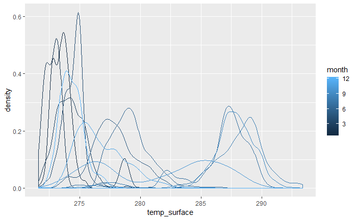

```r
dev.off() # stops automatic saving of the plot to a png
```

```r
ggplot(m1, aes(x = temp_depth, colour = month)) + geom_density(na.rm = TRUE) + geom_density(data=m2, na.rm = TRUE) + geom_density(data=m3, na.rm = TRUE) + geom_density(data=m4, na.rm = TRUE) + geom_density(data=m5, na.rm = TRUE) + geom_density(data=m6, na.rm = TRUE) + geom_density(data=m7, na.rm = TRUE) + geom_density(data=m8, na.rm = TRUE) + geom_density(data=m9, na.rm = TRUE) + geom_density(data=m10, na.rm = TRUE) + geom_density(data=m11, na.rm = TRUE) + geom_density(data=m12, na.rm = TRUE)
dev.copy(png,"../output/env/env_by_month_plots/temp_depth_month.png") # to automatically save the plot to a png AND show it inline
```

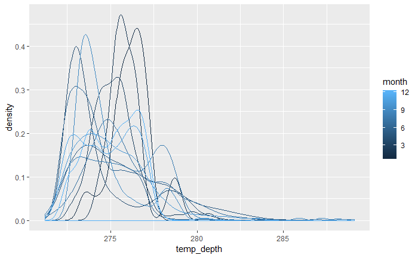

```r
dev.off() # stops automatic saving of the plot to a png
```

```r
ggplot(m1, aes(x = chl_surface, colour = month)) + geom_density(na.rm = TRUE) + geom_density(data=m2, na.rm = TRUE) + geom_density(data=m3, na.rm = TRUE) + geom_density(data=m4, na.rm = TRUE) + geom_density(data=m5, na.rm = TRUE) + geom_density(data=m6, na.rm = TRUE) + geom_density(data=m7, na.rm = TRUE) + geom_density(data=m8, na.rm = TRUE) + geom_density(data=m9, na.rm = TRUE) + geom_density(data=m10, na.rm = TRUE) + geom_density(data=m11, na.rm = TRUE) + geom_density(data=m12, na.rm = TRUE)
dev.copy(png,"../output/env/env_by_month_plots/chl_surface_month.png") # to automatically save the plot to a png AND show it inline
```

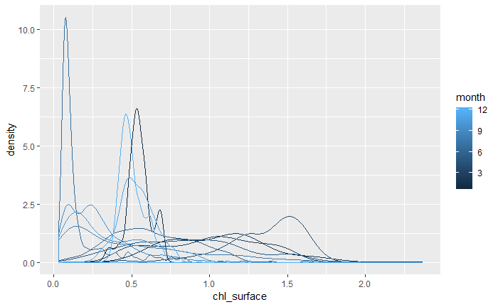

```r
dev.off() # stops automatic saving of the plot to a png
```

```r
ggplot(m1, aes(x = chl_depth, colour = month)) + geom_density(na.rm = TRUE) + geom_density(data=m2, na.rm = TRUE) + geom_density(data=m3, na.rm = TRUE) + geom_density(data=m4, na.rm = TRUE) + geom_density(data=m5, na.rm = TRUE) + geom_density(data=m6, na.rm = TRUE) + geom_density(data=m7, na.rm = TRUE) + geom_density(data=m8, na.rm = TRUE) + geom_density(data=m9, na.rm = TRUE) + geom_density(data=m10, na.rm = TRUE) + geom_density(data=m11, na.rm = TRUE) + geom_density(data=m12, na.rm = TRUE)
dev.copy(png,"../output/env/env_by_month_plots/chl_depth_month.png") # to automatically save the plot to a png AND show it inline
```

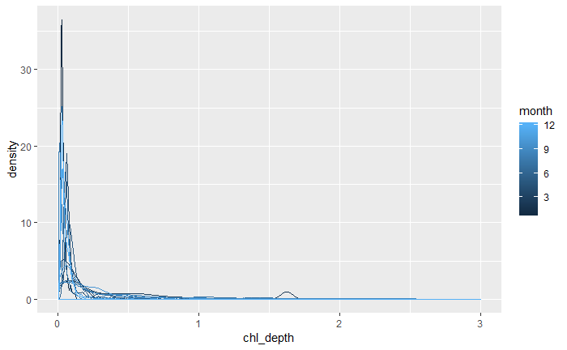

```r
dev.off() # stops automatic saving of the plot to a png
```

```r
ggplot(m1, aes(x = salinity_surface, colour = month)) + geom_density(na.rm = TRUE) + geom_density(data=m2, na.rm = TRUE) + geom_density(data=m3, na.rm = TRUE) + geom_density(data=m4, na.rm = TRUE) + geom_density(data=m5, na.rm = TRUE) + geom_density(data=m6, na.rm = TRUE) + geom_density(data=m7, na.rm = TRUE) + geom_density(data=m8, na.rm = TRUE) + geom_density(data=m9, na.rm = TRUE) + geom_density(data=m10, na.rm = TRUE) + geom_density(data=m11, na.rm = TRUE) + geom_density(data=m12, na.rm = TRUE)
dev.copy(png,"../output/env/env_by_month_plots/salinity_surface_month.png") # to automatically save the plot to a png AND show it inline
```

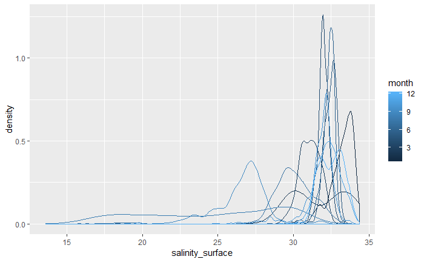

```r
dev.off() # stops automatic saving of the plot to a png
```

```r
ggplot(m1, aes(x = salinity_depth, colour = month)) + geom_density(na.rm = TRUE) + geom_density(data=m2, na.rm = TRUE) + geom_density(data=m3, na.rm = TRUE) + geom_density(data=m4, na.rm = TRUE) + geom_density(data=m5, na.rm = TRUE) + geom_density(data=m6, na.rm = TRUE) + geom_density(data=m7, na.rm = TRUE) + geom_density(data=m8, na.rm = TRUE) + geom_density(data=m9, na.rm = TRUE) + geom_density(data=m10, na.rm = TRUE) + geom_density(data=m11, na.rm = TRUE) + geom_density(data=m12, na.rm = TRUE)
dev.copy(png,"../output/env/env_by_month_plots/salinity_depth_month.png") # to automatically save the plot to a png AND show it inline
```

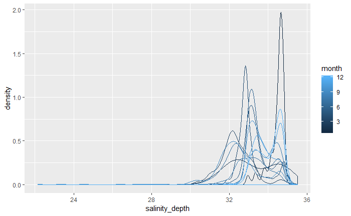

```r
dev.off() # stops automatic saving of the plot to a png
```

```r
ggplot(m1, aes(x = o2_surface, colour = month)) + geom_density(na.rm = TRUE) + geom_density(data=m2, na.rm = TRUE) + geom_density(data=m3, na.rm = TRUE) + geom_density(data=m4, na.rm = TRUE) + geom_density(data=m5, na.rm = TRUE) + geom_density(data=m6, na.rm = TRUE) + geom_density(data=m7, na.rm = TRUE) + geom_density(data=m8, na.rm = TRUE) + geom_density(data=m9, na.rm = TRUE) + geom_density(data=m10, na.rm = TRUE) + geom_density(data=m11, na.rm = TRUE) + geom_density(data=m12, na.rm = TRUE)
dev.copy(png,"../output/env/env_by_month_plots/o2_surface_month.png") # to automatically save the plot to a png AND show it inline
```

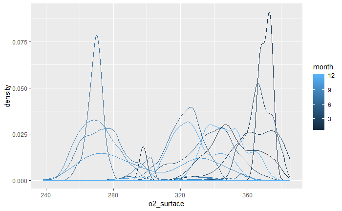

```r
dev.off() # stops automatic saving of the plot to a png
```

```r
ggplot(m1, aes(x = o2_depth, colour = month)) + geom_density(na.rm = TRUE) + geom_density(data=m2, na.rm = TRUE) + geom_density(data=m3, na.rm = TRUE) + geom_density(data=m4, na.rm = TRUE) + geom_density(data=m5, na.rm = TRUE) + geom_density(data=m6, na.rm = TRUE) + geom_density(data=m7, na.rm = TRUE) + geom_density(data=m8, na.rm = TRUE) + geom_density(data=m9, na.rm = TRUE) + geom_density(data=m10, na.rm = TRUE) + geom_density(data=m11, na.rm = TRUE) + geom_density(data=m12, na.rm = TRUE)
dev.copy(png,"../output/env/env_by_month_plots/o2_depth_month.png") # to automatically save the plot to a png AND show it inline
```

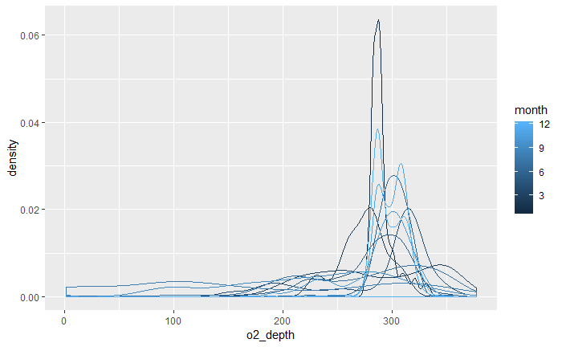

```r
dev.off() # stops automatic saving of the plot to a png
```

```r
ggplot(m1, aes(x = mlp_surface, colour = month)) + geom_density(na.rm = TRUE) + geom_density(data=m2, na.rm = TRUE) + geom_density(data=m3, na.rm = TRUE) + geom_density(data=m4, na.rm = TRUE) + geom_density(data=m5, na.rm = TRUE) + geom_density(data=m6, na.rm = TRUE) + geom_density(data=m7, na.rm = TRUE) + geom_density(data=m8, na.rm = TRUE) + geom_density(data=m9, na.rm = TRUE) + geom_density(data=m10, na.rm = TRUE) + geom_density(data=m11, na.rm = TRUE) + geom_density(data=m12, na.rm = TRUE)
dev.copy(png,"../output/env/env_by_month_plots/mlp_month.png") # to automatically save the plot to a png AND show it inline
```

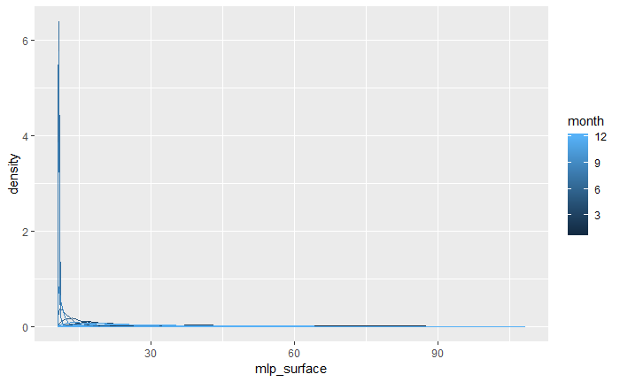

```r
dev.off() # stops automatic saving of the plot to a png
```

```r
ggplot(m1, aes(x = ssh_surface, colour = month)) + geom_density(na.rm = TRUE) + geom_density(data=m2, na.rm = TRUE) + geom_density(data=m3, na.rm = TRUE) + geom_density(data=m4, na.rm = TRUE) + geom_density(data=m5, na.rm = TRUE) + geom_density(data=m6, na.rm = TRUE) + geom_density(data=m7, na.rm = TRUE) + geom_density(data=m8, na.rm = TRUE) + geom_density(data=m9, na.rm = TRUE) + geom_density(data=m10, na.rm = TRUE) + geom_density(data=m11, na.rm = TRUE) + geom_density(data=m12, na.rm = TRUE)
dev.copy(png,"../output/env/env_by_month_plots/ssh_month.png") # to automatically save the plot to a png AND show it inline
```

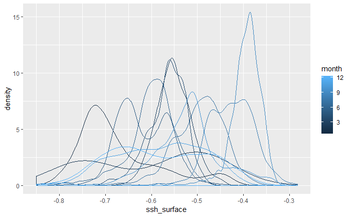

```r
dev.off() # stops automatic saving of the plot to a png
```

```r
ggplot(back, aes(temp_depth, colour = month)) + geom_density()
dev.copy(png,"../output/env/env_by_month_plots/temp_depth_month_background.png") # to automatically save the plot to a png AND show it inline
```

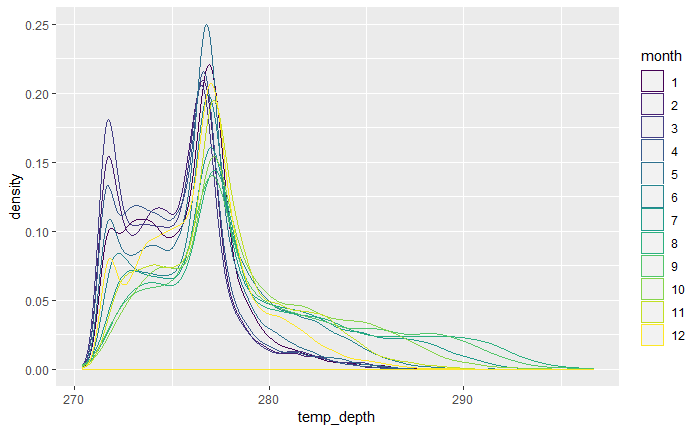

```r
dev.off() # stops automatic saving of the plot to a png
```

```r
ggplot(back, aes(salinity_depth, colour = month)) + geom_density()
dev.copy(png,"../output/env/env_by_month_plots/salinity_depth_month_background.png") # to automatically save the plot to a png AND show it inline
```

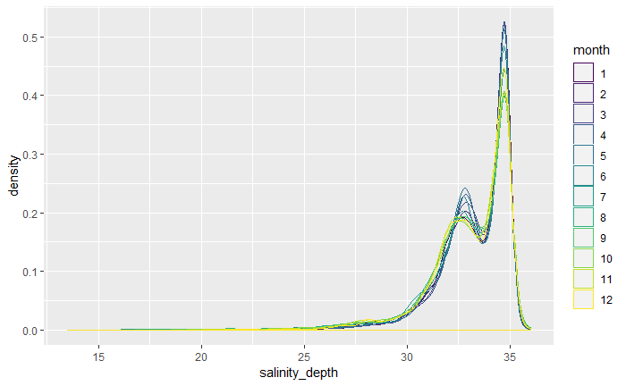

```r
dev.off() # stops automatic saving of the plot to a png
```

```r
ggplot(back, aes(o2_depth, colour = month)) + geom_density()
dev.copy(png,"../output/env/env_by_month_plots/o2_depth_month_background.png") # to automatically save the plot to a png AND show it inline
```

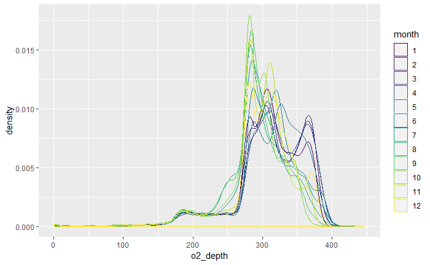

```r
dev.off() # stops automatic saving of the plot to a png
```

```r
ggplot(back, aes(chl_surface, colour = month)) + geom_density()
dev.copy(png,"../output/env/env_by_month_plots/chl_surface_month_background.png") # to automatically save the plot to a png AND show it inline
```

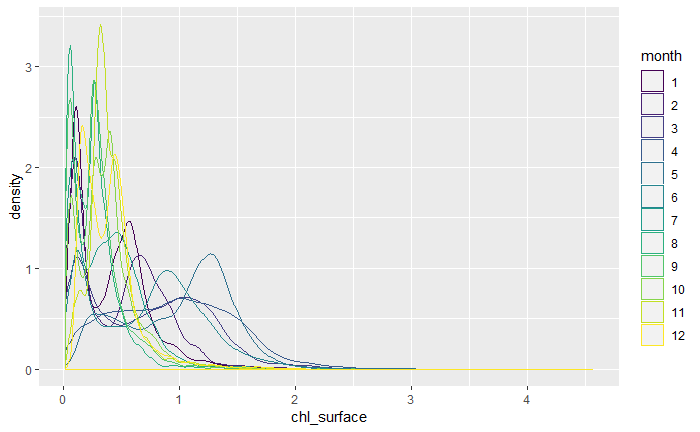

```r
dev.off() # stops automatic saving of the plot to a png
```